[interactive chart not shown]

## 📖 All Levels

Always visible. Click a phase to expand. ✓ = completed. Hidden on mobile — use the floating button instead.

# DSC 152 Companion — Quiz 1 · Quiz 2 · Midterm

Lec 1–10 (Hypothesis Testing → Regression → Diagnostics) · Labs 1–3 · Built for Maxime

→ Open the Uber APM Interview Bridge (new tab)

Level 1 0 XP 0 Streak

Phase 1: Lec 1-2

Phase 2: Lec 3-5

Phase 3: Labs 1-3

Phase 4: Practice Quiz

Phase 5: Cheat Sheet

Phase 6: Lec 6-7 (Two-Sample / SLR)

Phase 7: Lec 8-9 (MLR / Partial F)

Phase 8: Lec 10 + Quiz 2 Practice

Phase 9: Midterm Review

Phase 10: Lab Deep Dives (Lab 4-5)

Phase 11: ESL Practice Bank 🌍

Phase 12: ESL Bank Quiz 2 🌍

Phase 13: Lab 6 Deep Dive (Interactions) 🌍

Phase 14: 🧒 Beginner R + Stats Survival Kit

Phase 15: Lec 14 — Transformations 🌍

Phase 16: Lec 13 — Model Selection Pitfall 🌍

Level 1 - R Crash Course for Complete Beginners +50 XP

Business Story

Imagine you are a data analyst starting your first day at Netflix. Your boss says: "We use R for our statistical analysis." You have used Python before (maybe in DSC 10), but R is new. Do not worry - R and Python are like Spanish and Portuguese. Different words, same ideas. Let us learn R by comparing it to what you already know.

### Assignment: Saving Values into Variables

Concept

In Python, you write `x = 5` to store the number 5 in a variable called x. In R, the tradition is to use an arrow: `x <- 5`. The arrow points LEFT, showing "put 5 INTO x." You CAN use `=` in R too, but your professor and labs use `<-`, so you should too.

R Code

```
# Store the number 5 in a variable called x
x <- 5

# Store text (a "string") in a variable
greeting <- "Hello Maxime"

# Print the value
print(x)
```

`x <- 5` - Create a variable named x and put the number 5 in it. The arrow `<-` means "assign."

`greeting <- "Hello Maxime"` - Create a variable with text. Text always goes in quotes.

`print(x)` - Show what is inside x. Outputs: 5

R vs Python

| Task | Python | R |
| --- | --- | --- |
| Assign a value | `x = 5` | `x <- 5` |
| Print | `print(x)` | `print(x)` (same!) |
| Comments | `# comment` | `# comment` (same!) |

### Vectors: R's Version of Lists

Concept

In Python, you have lists: `[3, 7, 1]`. In R, the equivalent is a **vector**, and you create one with the `c()` function. The "c" stands for "combine" - you are combining numbers together into one collection.

R Code

```
# Create a vector of ages
ages <- c(21, 25, 19, 30, 22)

# How many elements?
length(ages)   # 5

# Sum of all ages
sum(ages)      # 117

# Average age
mean(ages)     # 23.4
```

### Ranges with 1:N -- BOTH Endpoints Included!

Warning - Key Difference from Python

In R, `1:10` gives you 1, 2, 3, 4, 5, 6, 7, 8, 9, 10. **BOTH endpoints are included.** This is DIFFERENT from Python's `range(1, 10)` which stops at 9. This trips up MANY students on quizzes.

R Code

```
# 1:5 gives you: 1, 2, 3, 4, 5
print(1:5)

# 3:7 gives you: 3, 4, 5, 6, 7
print(3:7)
```

R vs Python - Ranges

| What you want | Python | R |
| --- | --- | --- |
| Numbers 1 to 5 | `range(1, 6)` (stops before 6!) | `1:5` (includes both!) |
| Numbers 1 to 10 | `range(1, 11)` | `1:10` |

Warning - What 1:N Cannot Do

The `:` operator ONLY counts by whole numbers (integers). You CANNOT do `1:10` by steps of 0.5. For that, you need `seq(1, 10, by = 0.5)`. This is tested in Lab 1 Q1.2.2!

### Indexing: R Starts at 1, Not 0!

Concept

In Python, the first element is `x[0]`. In R, the first element is `x[1]`. R starts counting from 1, like normal humans do.

Also, **negative indexing works differently!** In Python, `x[-1]` gives you the LAST element. In R, `x[-1]` gives you everything EXCEPT the first element. It REMOVES that position.

R Code

```
ages <- c(21, 25, 19, 30, 22)

# First element (R counts from 1!)
ages[1]       # 21

# Third element
ages[3]       # 19

# REMOVE the first element (negative index!)
ages[-1]      # 25, 19, 30, 22

# REMOVE first and second elements
ages[-c(1,2)]  # 19, 30, 22
```

Quiz - Indexing

In R, you have `v <- c(10, 20, 30, 40, 50)`. What does `v[-2]` return?

20 (the second element)

10, 30, 40, 50 (everything except the 2nd element)

50 (the last element, like Python)

An error

### The $ Operator: Getting Columns from Data Frames

Business Story

Imagine you have a spreadsheet of TSA airport wait times with columns: airport, wait_min, date. In R, that spreadsheet is called a "data frame." To grab one column, you use the dollar sign: `tsa$wait_min`. Think of $ as saying "give me the wait_min column FROM the tsa data."

R Code

```
# Assume tsa is a data frame with a column called wait_min
# Get all values in the wait_min column:
tsa$wait_min

# Calculate the average wait time:
mean(tsa$wait_min)

# How many rows (observations)?
length(tsa$wait_min)
```

`tsa$wait_min` - The `$` reaches INTO the data frame "tsa" and pulls out the column "wait_min" as a vector.

`mean(tsa$wait_min)` - Take the average of all numbers in the wait_min column.

### Functions in R

Concept

In Python, you define a function with `def`. In R, you use the word `function`. The body goes inside curly braces `{ }` instead of being indented. In R, curly braces `{ }` group lines of code together, like Python uses indentation.

R Code

```
# A function that doubles a number
double_it <- function(x) {
  result <- x * 2
  return(result)
}

# Use it:
double_it(5)  # returns 10
```

`double_it <- function(x)` - Create a function called double_it that takes one input called x.

`{` - Opening curly brace: everything between { and } is the function body.

`result <- x * 2` - Multiply x by 2 and store it.

`return(result)` - Send the result back.

`}` - Closing curly brace: end of the function body.

R vs Python - Functions

| Python | R |
| --- | --- |
| def double_it(x): return x * 2 | double_it <- function(x) { return(x * 2) } |

### For Loops in R

Concept

For loops repeat code many times. In R, the for-loop body goes INSIDE curly braces `{ }`. The variable changes each time through the loop.

R Code

```
# Print numbers 1 through 5
for (i in 1:5) {
  print(i)
}

# Store results in a vector
results <- c()
for (i in 1:5) {
  results[i] <- i * 10
}
# results is now: 10, 20, 30, 40, 50
```

`for (i in 1:5)` - Loop where i takes values 1, 2, 3, 4, 5 (both endpoints included!).

`{` - Start of the loop body.

`print(i)` - This runs once for each value of i.

`}` - End of the loop body.

`results <- c()` - Create an empty vector to store results.

`results[i] <- i * 10` - Put i*10 in the i-th position of results.

R vs Python - For Loops

| Python | R |
| --- | --- |
| for i in range(1, 6): print(i) | for (i in 1:5) { print(i) } |

Python uses `range(1, 6)` because it excludes the endpoint. R uses `1:5` because it includes both.

### set.seed() -- Bookmarking Randomness

Analogy

`set.seed(123)` is like bookmarking a spot in randomness. If you and your friend both run `set.seed(123)` then `rnorm(5)`, you will get the EXACT same 5 numbers. Labs use this so the autograder can check your answers. If you forget `set.seed()`, you will get different random numbers each time, and the autograder will mark you wrong even if your code is correct.

R Code

```
set.seed(123)           # Bookmark the random spot
x <- rnorm(5)           # Generate 5 random numbers
print(x)                # Always the same 5 numbers!

# If you run set.seed(123) again + rnorm(5),
# you get the EXACT same numbers as before
```

### sample() -- Picking Random Items

Business Story

Imagine you are running a raffle at a company event. You have 100 employee names in a hat. `sample(employees, 5)` picks 5 random winners (no repeats - you do not put the name back). But if you do `sample(employees, 5, replace = TRUE)`, you put each name back after picking, so someone COULD win twice. This "with replacement" idea is CRITICAL for bootstrap later.

R Code

```
# Pick 3 random numbers from 1 to 10 (no repeats)
sample(1:10, 3)

# Pick 3 random numbers from 1 to 10 (repeats allowed)
sample(1:10, 3, replace = TRUE)

# Resample a whole dataset (this is bootstrap!)
data <- c(5, 8, 3, 12, 7)
boot_sample <- sample(data, length(data), replace = TRUE)
```

`sample(1:10, 3)` - Pick 3 random numbers from 1 through 10. Each number can only be picked once.

`sample(1:10, 3, replace = TRUE)` - Same but with replacement: after picking a number, "put it back." You might get repeats like 4, 4, 7.

`sample(data, length(data), replace = TRUE)` - Resample the data: pick as many items as the data has, with replacement. This is the core of bootstrap!

### Key R Functions Summary

R Functions You Must Know

[output not shown]

Quiz - R Basics

What does `1:5` produce in R?

1, 2, 3, 4 (excludes 5 like Python)

Only the number 0.2 (1 divided by 5)

1, 2, 3, 4, 5 (includes both endpoints)

An error

Quiz - set.seed

Why do labs ask you to run `set.seed()` before generating random numbers?

So everyone gets the same random numbers, making grading possible

To make the numbers truly random

To prevent errors in the code

It is optional and does not matter

Quiz - sample()

What does `replace = TRUE` mean in `sample(data, n, replace = TRUE)`?

It replaces the original data with new values

After picking an item, it goes back in the pool and can be picked again

It uses a replacement algorithm that is faster

It replaces missing values with zeros

Level 2 - What Is a Hypothesis Test? (The Airport Story) +40 XP

Business Story

You land at San Diego airport. The sign says: "Average TSA wait time: 20 minutes." But you waited 35 minutes! Your friend waited 28. Another passenger waited 32. Is the airport LYING? Or did you just get unlucky?

You cannot just say "I waited long, so the sign is wrong." That is one person's experience. But you CAN collect data from 50 passengers and use a formal procedure to decide: is 20 minutes a reasonable claim, or is the real average higher?

**That formal procedure is a hypothesis test.**

Concept - Two Competing Claims

Every hypothesis test has two competing claims:

- **Null Hypothesis (H0):** The boring default. Nothing special is happening. "The average wait IS 20 minutes."
- **Alternative Hypothesis (HA):** The exciting claim. Something IS different. "The average wait is NOT 20 minutes" (or "is MORE than 20 minutes").

Think of it like a court trial: the defendant (H0) is "innocent until proven guilty." You need strong evidence to convict (reject H0).

Formula - Notation

**Two-sided test** (could be higher OR lower):

H0: mu = 20 vs HA: mu != 20

**One-sided test** (only care about higher):

H0: mu = 20 vs HA: mu > 20

**One-sided test** (only care about lower):

H0: mu = 20 vs HA: mu < 20

mu (the Greek letter) = the TRUE population average (which we do not know)

Analogy - Two-sided vs One-sided

**Two-sided:** "Is the thermostat broken?" - Could be too hot OR too cold.

**One-sided (greater):** "Is the thermostat stuck too high?" - Only care about overheating.

One-sided tests are more powerful (easier to detect the effect) but you must decide the direction BEFORE seeing the data.

Quiz - Hypotheses

A company claims their delivery takes 2 days on average. You suspect it takes longer. What are the hypotheses?

H0: mu > 2, HA: mu = 2

H0: mu = 2, HA: mu != 2

H0: mu = 2, HA: mu > 2

H0: mu < 2, HA: mu > 2

Quiz - One-sided vs Two-sided

When would you use a two-sided test?

When you want to detect a difference in either direction (higher or lower)

When you only care if the value is higher

When the sample size is large

When the data is normally distributed

Level 3 - The p-value: What It Actually Means +50 XP

Business Story - The Coin Flip

Your friend says their coin is fair (50/50 heads/tails). You flip it 10 times and get 7 heads. Is the coin rigged? Well, even a fair coin could get 7 heads sometimes by luck. The p-value answers: "If the coin really IS fair, how likely is it to get a result THIS extreme (7 or more heads) just by chance?"

If that probability is tiny (like 1%), you think: "Wow, that would be really unlikely with a fair coin. The coin is probably NOT fair." If it is moderate (like 17%), you think: "Meh, 7 heads could easily happen by luck. I cannot claim the coin is rigged."

Concept - The p-value Definition

**p-value = the probability of getting data this extreme (or MORE extreme), assuming H0 is true.**

Small p-value = "This data would be very surprising if H0 were true" = evidence AGAINST H0.

Large p-value = "This data is not surprising under H0" = no strong evidence against H0.

Warning - What the p-value is NOT

- **NOT** the probability that H0 is true
- **NOT** the probability that HA is true
- **NOT** the probability of making a Type I Error (that is alpha, which you choose)
- **NOT** the probability that you will replicate the result

The p-value is ONLY about: "How extreme is my data, assuming H0 is true?"

Quiz - p-value Meaning

You run a t-test and get p = 0.03. What does this mean?

There is a 3% chance that H0 is true

If H0 were true, there is a 3% chance of seeing data this extreme or more extreme

There is a 97% chance that HA is true

3% of the data supports H0

Quiz - p-value Misconceptions

Which of these is a CORRECT interpretation of a p-value?

The probability that H0 is true

The Type I Error rate

The probability of observing the data (or more extreme) under H0

The probability that your results will replicate

Level 4 - The Decision Rule +30 XP

Concept - Alpha and the Decision

Before you even LOOK at your data, you pick a threshold called **alpha (usually 0.05)**. Then:

- If **p < alpha**: Reject H0. The data is surprising enough to doubt the null.
- If **p >= alpha**: Fail to reject H0. The data is not surprising enough.

**You must pick alpha BEFORE looking at the data.** Otherwise you could cheat by picking alpha to match your desired result.

Analogy - The Jury

**"Fail to reject H0" does NOT mean "H0 is true."**

It is like a jury saying "not guilty." That does not mean the defendant is innocent - it means there was not ENOUGH evidence to convict.

You NEVER "accept H0" or "prove H0." You only ever "fail to reject" it.

Warning - Common Quiz Trap

If someone says "we accept the null hypothesis," that is WRONG language. The correct phrase is "we fail to reject the null hypothesis." This is almost certainly on the quiz.

Quiz - Decision Rule

You set alpha = 0.05 and get p = 0.03. What do you do?

Accept H0

Reject H0

Accept HA

Need more data

Quiz - Language

You get p = 0.15 with alpha = 0.05. Which statement is correct?

We accept the null hypothesis

We proved H0 is true

We fail to reject the null hypothesis

The alternative hypothesis is false

Level 5 - Statistical Tests: The Big Picture (Before We Code Anything) +80 XP

Business Story — Why Tests Exist

You are a product analyst at Uber. The average ride takes 12 minutes. A new routing algorithm is deployed. After a week, you check: average ride time is now 11.4 minutes. Your VP asks: **"Is that real improvement, or just random noise?"**

You cannot just look at the number. 11.4 vs 12 could be genuine — or it could be chance variation in a sample. A **statistical test** is the formal tool that answers: *"Could this difference have happened by luck alone?"*

### What Kinds of Tests Are There?

Concept — Three Questions Before Picking a Test

Statistical tests are NOT one-size-fits-all. Before picking a test, ask three questions:

**Question 1: How many groups of numbers do I have?**

- **One-sample test**: ONE group of data compared to a KNOWN number (from a claim, a standard, a policy). Example: "The airport claims average wait = 20 min. My sample of 50 passengers averaged 23.5 min. Is 23.5 far enough from 20 to be real?"
- **Two-sample test**: TWO groups of data compared to each other. Example: "Group A saw the old checkout page, Group B saw the new one. Did Group B convert more?" This is the classic **A/B test**.

**Question 2: If I have two groups, are they paired or unpaired?** (Only matters for two-sample tests — more below.)

- **Paired**: the two groups come from the *same* people/items measured twice. Example: blood pressure for each patient BEFORE and AFTER a drug.
- **Unpaired**: the two groups are *different* people/items. Example: Group A = 100 users on the old page, Group B = 100 *different* users on the new page.

**Question 3: Is my data roughly normal (bell-shaped), or is it skewed/weird?**

- **Parametric test** (e.g., t-test): Assumes data is roughly normal. Tests the **MEAN**.
- **Non-parametric test** (e.g., sign test): Makes NO assumption about shape. Tests the **MEDIAN**.

**Quiz 1 shortcut:** almost everything on Quiz 1 is a **one-sample** test. The paired vs unpaired question only matters if you ever see two samples — so if you're unsure, default to one-sample logic for Quiz 1.

### Visual: One-Sample vs Two-Sample

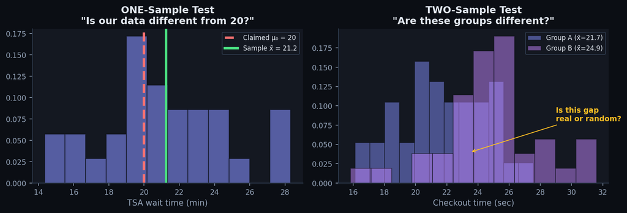

Reading This Chart

**Left**: ONE-sample test. We have one batch of TSA wait times (blue bars). We compare them to a single claimed value (red dashed line at 20 min). The question: "Is the gap between our sample mean (green) and the claimed value (red) big enough to be real?"

**Right**: TWO-sample test. We have two groups (purple and blue). The question: "Is the gap between these two groups big enough to NOT be random noise?" This is exactly what an A/B test does.

### Paired vs Unpaired (and How They Relate to One- vs Two-Sample)

Concept — Paired vs Unpaired

This is a different question from "one-sample vs two-sample." It's easy to confuse them — here is the clean way to think about it:

- **One-sample vs two-sample** asks: *how many groups of numbers am I working with?*
- **Paired vs unpaired** asks: *if I have two groups, are the observations linked one-to-one?*

**Paired** = each value in group 1 has a natural partner in group 2. The classic case is "same subject, measured twice."

- Blood pressure BEFORE the drug vs AFTER the drug — same 30 patients.
- Website load time on OLD server vs NEW server — measured for the same 100 URLs.
- Student test score in January vs June — same students.

**Unpaired** = the two groups are separate people/items with no one-to-one matching.

- 100 users on the old homepage vs 100 *different* users on the new homepage.
- Salaries at Company A vs Company B (different employees).

Analogy — The Twin Trick

A paired test is like using **twins** as the control. Each twin in group A has a matched twin in group B, so you can subtract out everything the twins share. Less noise, more power.

An unpaired test is like comparing **strangers**. You don't know what's different between them, so you need more data to see the signal.

Why Paired vs Unpaired is DIFFERENT from One-Sample vs Two-Sample

Here's the confusing part: a paired test is usually *run as a one-sample test*. You take the differences (after − before) for each subject, and then test whether the mean of those differences equals 0.

- **Paired data** → compute differences → run a **one-sample t-test** on the differences, with mu0 = 0.
- **Unpaired two-sample data** → run a **two-sample t-test** directly.

So the quick rule: "paired" data gets squeezed into the one-sample framework by looking at differences. "Unpaired" stays as a genuine two-sample problem.

**Quiz 1 focus:** you'll mostly see pure one-sample problems (like the TSA 20-minute claim). Paired tests aren't the star of Quiz 1, but knowing the distinction keeps you from getting tripped up by the wording.

### One-Sample Tests: The Main Focus for Quiz 1

Concept — What a One-Sample Test Actually Does

You always have the same ingredients:

- ONE batch of numbers (your sample).
- ONE claimed value (mu0) that comes from outside the data — a company claim, a standard, a target, a historical average.

You ask: **"Given my sample, is the true mean really equal to mu0, or is it different?"**

The null hypothesis is always H0: mu = mu0. The alternative depends on the question:

- Two-sided: HA: mu ≠ mu0 (any difference counts)
- One-sided greater: HA: mu > mu0 (only bigger counts)
- One-sided less: HA: mu < mu0 (only smaller counts)

Lots of One-Sample Examples (Practice Spotting Them)

Every example below is a one-sample test. Notice the shared shape: *one* batch of data, *one* claimed number, and a yes/no question about whether they match.

1. **TSA wait times (Quiz 1 main story):** Airport claims avg wait = 20 min. You sample 50 passengers. H0: mu = 20.
2. **Netflix session length:** Marketing claims avg viewing session = 45 min. A sample of 200 users shows x̄ = 42. H0: mu = 45.
3. **Amazon package delivery:** Amazon promises 2-day delivery, meaning mean delivery = 2.0 days. You measure 80 shipments. H0: mu = 2.0.
4. **DoorDash tip size:** A report says the median tip is $3. You pull 60 orders. (Skewed data → sign test, but still one-sample.) H0: median = 3.
5. **Battery life:** Manufacturer advertises 10 hours per charge. You test 25 laptops. H0: mu = 10.
6. **Factory bolt weight:** Spec says each bolt must weigh 50 g. QA samples 40 bolts. H0: mu = 50.
7. **Exam scores:** Historical average on a final = 72. This year's class of 120 students averaged 75. H0: mu = 72.
8. **Uber ride time:** Historical average = 12 min. After a routing change, 500 rides avg 11.4 min. H0: mu = 12.
9. **Water quality:** Regulation: dissolved oxygen must equal 6.0 mg/L. Lab measures 15 samples. H0: mu = 6.0.
10. **Paired blood pressure (one-sample in disguise):** 30 patients measured before and after a drug. Compute differences d = after − before. H0: mu_d = 0.

**Quiz 1 habit:** when you read a word problem, first circle the claimed number. If there's exactly ONE claimed number and ONE batch of data, it's a one-sample test.

### Visual: The Test Decision Tree

This flowchart is your cheat sheet for picking the right test. Put this on your exam sheet!

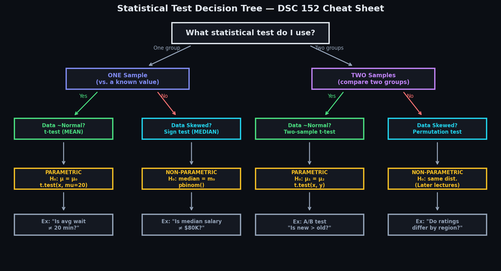

Concept — Parametric vs Non-Parametric

**Parametric** = the test makes ASSUMPTIONS about the shape of your data (usually: "data is normal"). In exchange, it is more POWERFUL — it can detect smaller differences. The **t-test** is parametric.

**Non-parametric** = the test makes NO assumptions about shape. It works on ANY distribution (normal, skewed, bimodal, whatever). The trade-off: it is LESS powerful — it needs more data to detect the same difference. The **sign test** is non-parametric.

Think of it like this: a parametric test is a specialist doctor — great when the diagnosis fits, but wrong diagnosis = bad treatment. A non-parametric test is a general practitioner — works for everything, but might miss subtle issues.

Real Business Examples for Each Test Type

**One-sample t-test**: "Netflix claims average viewing session = 45 min. A sample of 200 users shows x̄ = 42 min. Is the claim wrong?"

**One-sample sign test**: "DoorDash tip distribution is heavily right-skewed ($0, $0, $0, $2, $3, $15, $50). Is the MEDIAN tip different from $3?"

**Two-sample t-test**: "A/B test at Spotify: Do users on the new homepage (Group B) stream more minutes per day than users on the old homepage (Group A)?"

**Two-sample permutation test**: "Amazon product ratings for sellers in California vs. Texas. Ratings are 1-5 stars (discrete, skewed). Do the distributions differ?"

Quiz

You have ONE group of delivery times and want to check if the average differs from the company's 30-minute promise. What type of test?

Two-sample t-test

One-sample t-test

Sign test

Permutation test

Quiz

Tip amounts at a restaurant are heavily right-skewed (many $0 tips, a few $50 tips). Which test is best for testing the center?

One-sample t-test (tests the mean)

Two-sample t-test

Sign test (tests the median)

No test possible

Quiz

A parametric test is more _____ but requires _____ about the data distribution.

Powerful; assumptions

Flexible; no assumptions

Conservative; less data

Biased; randomness

Quiz

Spotify runs an A/B test: Group A (old homepage) vs Group B (new homepage). Streaming minutes are roughly normal. What test?

One-sample t-test

Two-sample t-test

Sign test

Bootstrap only

Quiz — Paired vs Unpaired

You measure blood pressure on 40 patients BEFORE a drug and AFTER. You want to know if the drug lowered BP on average. This is:

A paired design — compute differences and run a one-sample t-test on the differences

An unpaired two-sample t-test

A sign test only, no other option

Not a valid test setup

Quiz — Spot the One-Sample

Which of these is a one-sample test?

Comparing conversion rates between users on page A and page B

Comparing salaries between Company A and Company B

Testing whether the average battery life of 25 laptops equals the advertised 10 hours

Comparing test scores in January vs June on the same students

Quiz — One-Sample Setup

The airport claims avg wait = 20 min and you want to test whether the true mean DIFFERS. Which hypotheses?

H0: mu ≠ 20 vs HA: mu = 20

H0: mu = 20 vs HA: mu ≠ 20

H0: mu > 20 vs HA: mu < 20

H0: mu = 20 vs HA: mu > 20

Level 6 - The t-test: Visual Intuition, Formula, and R Code +80 XP

Business Story — The Airport Investigation

You collected wait times from 50 passengers at the airport. The airport claims average wait = 20 minutes. Your sample average is x̄ = 23.5 minutes. That is 3.5 minutes more than claimed. But is that *enough* to say the airport is lying?

Here is the problem: even if the TRUE average really IS 20 minutes, random sampling would give you a sample average that is NOT exactly 20. Maybe 19.2 one day, 21.1 another. The question is: **is 23.5 far enough from 20 that it would be REALLY unlikely to happen by chance?**

### Visual: The t-test Idea

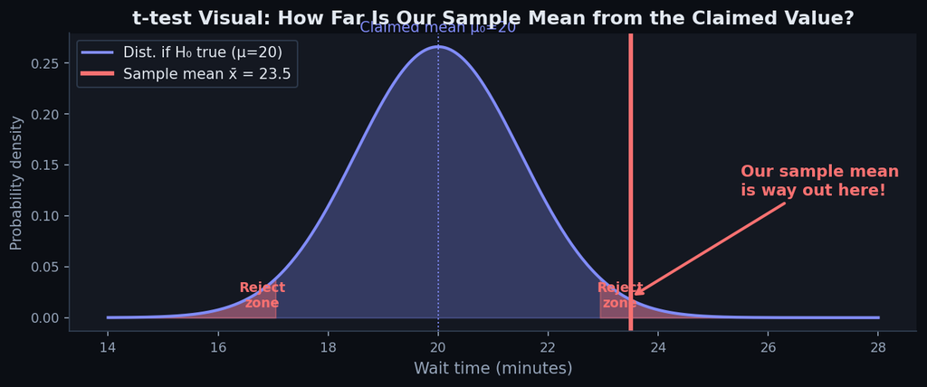

Reading This Chart — The Core Idea of a t-test

The blue bell curve shows: **"If H₀ is true (the real mean IS 20), what sample means would we typically see?"** Most sample means would land near 20 (the peak). Getting a sample mean of 16 or 24 would be rare.

The red line at 23.5 is our ACTUAL sample mean. It falls in the **red rejection zone** — the region that would be extremely unlikely if H₀ were true.

**The t-test quantifies this:** "How many standard errors away from 20 is our sample mean?" If it is far enough, we reject H₀.

### The t-statistic Formula

Formula

t = (x̄ − μ₀) / (s / √n)

Let us decode every symbol:

- **x̄** (x-bar) = your sample average. In our example: 23.5
- **μ₀** (mu-zero) = the claimed/hypothesized value. In our example: 20
- **s** = the sample standard deviation (how spread out your data is)
- **n** = how many data points you collected. In our example: 50
- **s / √n** = the **standard error** — this shrinks as n grows, making the test more sensitive

The t-statistic measures: *"How many standard errors is my sample mean away from the claimed value?"* A t-stat of 2 or more is usually far enough to reject.

Analogy — The GPS Analogy

Think of the standard error as the accuracy circle on your phone GPS. If your GPS says you are at position 23.5 with an accuracy circle of 1.5 (the standard error), and the airport claims you should be at 20.0 — well, 20.0 is WAY outside your accuracy circle. The claimed location does not match where you actually are. That is what a significant t-test tells you.

### New Vocabulary Before We Run t.test() — The Confidence Interval and df

Concept — What Is a Confidence Interval? (Plain English First)

When we just computed the t-statistic, we got ONE number — a single best-guess for "how far off are we from 20?". But every sample is a little different. If you collected 50 more wait times tomorrow, x̄ might be 22.8, not 23.5.

So instead of handing you a single number and pretending it is exact, R also gives you a **range** — the **confidence interval (CI)**. Think of it as:

*"Here is a range of values that is plausible for the TRUE average, given what I saw in the data."*

A **95% confidence interval** is built so that, if you repeated the whole experiment many times, 95% of the intervals you compute would contain the true mean. In practice you only get ONE interval — you just trust the procedure.

**Example output:** if R prints `[21.9, 25.1]`, that means: "the true average wait time is plausibly somewhere between 21.9 and 25.1 minutes."

Analogy — Darts, Not a Pinpoint

Imagine throwing a handful of darts at the number line. The **sample mean** is the center of your dart cluster. The **confidence interval** is the smallest band around that center that you are 95% confident covers the bullseye (the true mean). A skinny CI = low uncertainty. A wide CI = lots of uncertainty.

Shortcut — Link Between CI and the t-test Decision

Here is a handy connection you will use again and again:

- If the claimed value (μ₀ = 20) is **inside** the 95% CI, you **fail to reject** H₀ at α = 0.05.
- If μ₀ is **outside** the 95% CI, you **reject** H₀ at α = 0.05.

That is why R prints the CI right next to the p-value — it is the SAME decision, just viewed as a range instead of as a threshold.

Bonus — What Is "df" in the Output?

You will also see something like `df = 49` in the R output. That stands for **degrees of freedom**. For a one-sample t-test it is simply **n − 1** — the sample size minus one. With n = 50 wait times, df = 49.

For now just think: df tells R "which t-curve to use." Smaller df = fatter-tailed curve = harder to reject. We come back to this in detail in Level 7b.

### Running it in R — Line by Line

R Code — Your First t-test

```
# Step 1: Create your data (or use a dataframe column)
tsa_waits <- c(18.2, 24.5, 15.9, 30.1, 22.7, 11.3, 28.4, 19.6)

# Step 2: Run the one-sample t-test
# H0: mu = 20  vs  HA: mu != 20
t.test(tsa_waits, mu = 20)
```

`tsa_waits <- c(...)` — Create a vector of wait times. This is your data.

`t.test(tsa_waits, mu = 20)` — Run a one-sample t-test. The `mu = 20` is the value from H₀. R returns the t-statistic, degrees of freedom, p-value, confidence interval, and sample mean. All in one line!

R Code — Extracting Specific Pieces

```
# Get JUST the p-value (Practice Quiz Q1b!)
t.test(tsa_waits, mu = 20)$p.value

# Get JUST the confidence interval
t.test(tsa_waits, mu = 20)$conf.int

# Get the t-statistic
t.test(tsa_waits, mu = 20)$statistic

# Store and extract later
result <- t.test(tsa_waits, mu = 20)
result$p.value
result$conf.int
```

`$p.value` — The dollar sign `$` extracts ONE piece from the result. Think of it like opening a box and grabbing one item. `$p.value` grabs the p-value. `$conf.int` grabs the confidence interval.

R vs Python Comparison

| Task | R | Python |
| --- | --- | --- |
| Run t-test | `t.test(data, mu=20)` | `ttest_1samp(data, 20)` |
| Get p-value | `t.test(data, mu=20)$p.value` | `ttest_1samp(data, 20).pvalue` |
| One-sided (greater) | `alternative="greater"` | `alternative='greater'` |
| From dataframe column | `t.test(df$column, mu=20)` | `ttest_1samp(df['column'], 20)` |

### One-Sided vs Two-Sided Tests

Concept

**Two-sided (default)**: H₀: μ = 20 vs Hᴀ: μ ≠ 20. "Is it different in EITHER direction?"

**One-sided (greater)**: H₀: μ = 20 vs Hᴀ: μ > 20. "Is it LONGER than claimed?"

**One-sided (less)**: H₀: μ = 20 vs Hᴀ: μ < 20. "Is it SHORTER than claimed?"

R Code — One-Sided Tests

```
# Default: two-sided (mu != 20)
t.test(tsa_waits, mu = 20)

# One-sided: is it GREATER than 20?
t.test(tsa_waits, mu = 20, alternative = "greater")

# One-sided: is it LESS than 20?
t.test(tsa_waits, mu = 20, alternative = "less")
```

When to Use Each Direction

**Two-sided**: You do not know which direction the difference might be. Most common in research. "We just want to know if it is different."

**Greater**: You specifically care about "is it BIGGER?" Example: "Do users on the new checkout page spend MORE time?" (Poker example from Lecture 5: testing if average winnings > 0.)

**Less**: You specifically care about "is it SMALLER?" Example: "Does the new caching layer reduce page load time?"

Quiz

Which R code runs a one-sample t-test on the column wait_min from the tsa dataframe, testing if the mean equals 20?

t.test(tsa, mu = 20)

t.test(tsa$wait_min, mu = 20)

ttest(tsa$wait_min, 20)

t.test(mu = 20, data = tsa)

Quiz

What does t.test(data, mu = 5)$conf.int return?

The p-value

The t-statistic

The 95% confidence interval

The standard error

Quiz

The t-statistic measures:

The probability that H₀ is true

How many standard errors the sample mean is from the claimed value

The sample size needed

The effect size in minutes

Level 7 - Type I/II Errors, Skewness, and When the t-test Breaks +100 XP

Before Level 7 — Where We Are in the Journey

Level 7 zooms in on two things that can go wrong whenever we make that decision — and introduces the vocabulary that appears EVERYWHERE on your quiz: **Type I error, Type II error, α, β, and power**. We will build each term from scratch with ONE simple example, then stretch it.

The Courtroom Example — Our Single Running Story

A defendant is on trial. The law says: *"assume innocent until proven guilty."* That is exactly a hypothesis test. Translated to statistics:

- **H₀ (null):** the defendant is innocent.
- **Hᴀ (alternative):** the defendant is guilty.

The jury looks at the evidence (our "data") and has to pick ONE of two verdicts:

- **Guilty** → *"reject H₀"*
- **Not guilty** → *"fail to reject H₀"*

Because the jury can never be 100% sure, there are exactly two ways to mess up:

- **Convict an innocent person.** The truth was H₀, but the jury chose "guilty." → **Type I error** (false alarm).
- **Let a guilty person walk.** The truth was Hᴀ, but the jury chose "not guilty." → **Type II error** (missed detection).

That is the whole idea. Keep this courtroom in your head for the rest of Level 7 — every new term (α, β, power) just labels one of these four jury outcomes.

Statistics Translation — Same Idea, Statistics Words

Swap "defendant" for "null hypothesis." Swap "verdict" for "test decision." You get the generic version:

- **Type I error** = *reject H₀ when H₀ is actually TRUE*. (We cried "effect!" when there was none.)
- **Type II error** = *fail to reject H₀ when H₀ is actually FALSE*. (There WAS an effect, but we missed it.)

Notice: each error is named by what WE did (our decision), paired with what the truth actually is. Both matter — the jury analogy just makes it physical.

### Visual: The Four Outcomes

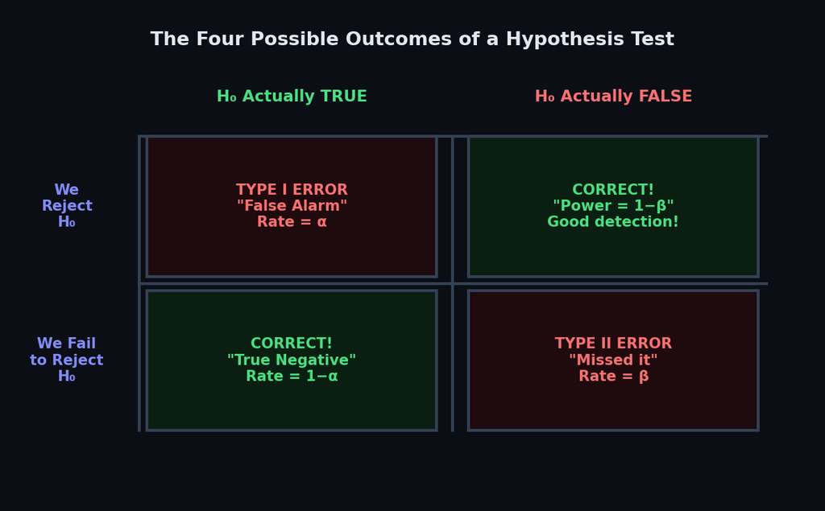

### Four Outcomes, Four Numbers — Introduced One at a Time

Step 1 — The Four Outcome Table (Know This Cold)

Every time you run a test, exactly ONE of these four cells happens — but you never know which one, because you do not know the truth.

|  | Truth: H₀ is TRUE (no effect) | Truth: H₀ is FALSE (real effect) |
| --- | --- | --- |
| **You FAIL TO REJECT H₀** (verdict: not guilty) | Correct! (no alarm, no fire) | Type II error (β) (missed the fire) |
| **You REJECT H₀** (verdict: guilty) | Type I error (α) (false alarm) | Correct! (Power = 1 − β) |

Every quiz question about Type I / Type II / power is just asking you to read this table.

Step 2 — What is α (alpha)? (Yes, the SAME α from Level 4)

**α is the exact same number you met in Level 4** — the threshold you compare the p-value to (usually 0.05). Nothing new, just a second name for the same knob:

- In Level 4 we said: *"if p < α, reject H₀."* That is the DECISION rule.
- In Level 7 we say: *"α = probability of making a Type I error when H₀ is true."* That is the PERFORMANCE of the rule.

They are the same α. Setting α = 0.05 means, in the long run, if H₀ really is true, you will falsely reject about 5 out of 100 times. YOU pick α BEFORE looking at the data.

**Mnemonic:** α = "Alarm rate when nothing is burning."

Step 3 — What is β (beta)?

**β** is a brand-new letter. It is the probability that you FAIL to reject H₀ when H₀ is actually FALSE — that is, you miss a real effect.

*β = P(fail to reject H₀ | H₀ is false)*

Typical values: β = 0.20 (a 20% miss rate) is common in industry studies. Unlike α, you usually do NOT set β directly — it comes out of your sample size, your effect size, and your α.

**Mnemonic:** β = "Blink — the alarm blinked and missed the fire."

Step 4 — What is Power?

**Power = 1 − β**. It is the probability that you CORRECTLY reject H₀ when there really IS an effect. High power = your test is good at catching real signals.

*Power = P(reject H₀ | H₀ is false)*

If β = 0.20, then power = 0.80 (an 80% chance of detecting a real effect). Industry convention: aim for power ≥ 0.80.

**What moves power around?**

- Bigger sample size → higher power.
- Bigger true effect → higher power.
- Smaller noise (σ) → higher power.
- Bigger α (more tolerant to false alarms) → higher power. (The seesaw!)

We will come back to power — how to compute it in R — in Level 12. Right now you just need the definition.

Cheat Sheet — Memorize These Four Lines

- **α** = P(reject H₀ | H₀ TRUE) = Type I error rate = YOU pick it (0.05).
- **β** = P(fail to reject H₀ | H₀ FALSE) = Type II error rate.
- **Power** = 1 − β = P(reject H₀ | H₀ FALSE).
- "Reject H₀ when H₀ is true" = **Type I**. "Fail to reject H₀ when H₀ is false" = **Type II**.

Industry Impact of Each Error Type

**Type I Error at a tech company**: You A/B test a new recommendation algorithm. The test says it is better (p = 0.03). You ship it. But it was actually NOT better — the 0.03 was a fluke. Result: wasted engineering effort, possible user experience degradation.

**Type II Error at a pharma company**: A new drug actually reduces blood pressure by 5 points. But your study was too small (n = 20), so the test says "no significant effect." The drug never gets approved. Patients miss out.

**The trade-off**: Making α smaller (e.g., 0.01 instead of 0.05) REDUCES Type I Errors but INCREASES Type II Errors (harder to detect real effects). It is a seesaw.

Quiz

You reject H₀ but H₀ is actually true. What happened?

Type II Error

Type I Error (false alarm)

Correct decision

Power error

Quiz

Setting α = 0.05 means you accept that ___% of tests may be false alarms.

5%

95%

50%

0.5%

### When Does the t-test BREAK? (This Is Exam Material!)

Concept — Two Conditions for the t-test

The t-test only works well when two conditions are met:

**1. Normality**: The data should come from a roughly normal (bell-shaped) distribution. This matters MOST when n is small (like 5 or 10). When n is large (100+), the Central Limit Theorem helps.

**2. Independence**: Each data point must not influence the others. Example of violation: measuring the SAME person twice, or stock prices on consecutive days.

### Visual: Normal vs Skewed — Why This Matters

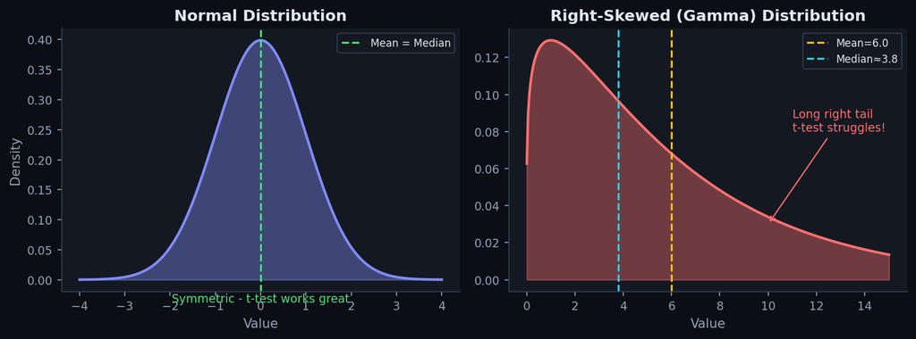

Reading This Chart

**Left (Normal)**: The data is symmetric. The mean and median are the same. The t-test's math works perfectly here because the sampling distribution of x̄ will also be symmetric.

**Right (Gamma/Skewed)**: The data has a long RIGHT tail. Notice the mean (yellow) is PULLED RIGHT by the extreme values, away from the median (cyan). This asymmetry is the problem.

### Visual: HOW Type I Error Gets Inflated

This is the KEY insight that your professor tests on (Practice Quiz Q3a, Lab 2 Q1.1). Look at what happens when we take many small samples:

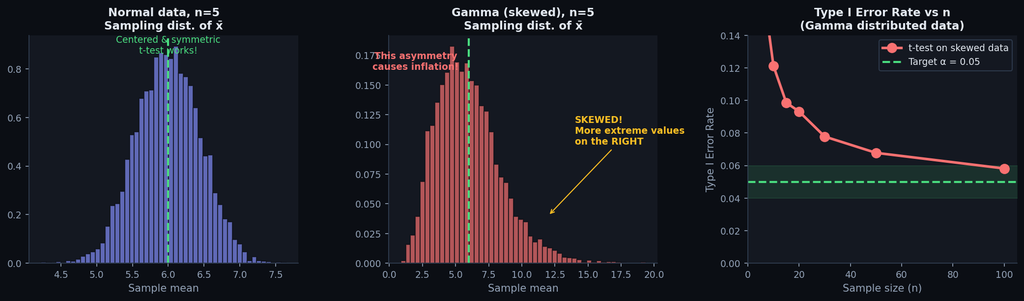

Warning — This Is Why Skewness Breaks the t-test

**Panel A (Normal data, n=5)**: When we take 8,000 samples of size 5 from a normal distribution and compute x̄ each time, the sampling distribution is *symmetric and centered* at the true mean. The t-test assumes this shape. Everything works.

**Panel B (Gamma/skewed data, n=5)**: Same thing, but from a skewed distribution. Now the sampling distribution of x̄ is ALSO skewed right! The t-test does NOT know this — it still assumes symmetry. So it puts the rejection regions in the wrong places. More sample means fall in the upper rejection region than expected, causing MORE false rejections (Type I Errors) than the promised 5%.

**Panel C**: As n increases, the Central Limit Theorem kicks in and the sampling distribution becomes more symmetric. The Type I Error rate gradually drops toward 0.05 — but even at n=30, it is still above 0.05 for this particular skewed distribution!

Concept — The Central Limit Theorem (CLT) Rescue

The CLT says: *"As n gets larger, the sampling distribution of x̄ becomes more and more normal, REGARDLESS of the original distribution."*

This is why the t-test eventually works even on skewed data — but ONLY with large enough n. With n=5 and skewed data, the CLT has NOT kicked in yet. The sampling distribution is still skewed, and the t-test's Type I Error rate is inflated above α.

**Rule of thumb**: For mildly skewed data, n ≥ 30 is often enough. For heavily skewed data (like the Gamma in your class), you might need n ≥ 50 or even 100.

### What To Do When Data Is Skewed

Three Options When Normality Fails

**Option 1: Use the sign test (non-parametric)**

The sign test does NOT assume normality. It tests the MEDIAN instead of the mean. It works on ANY distribution. Trade-off: it is less powerful (needs more data to find the same effect).

**Option 2: Get more data**

If you can increase n, the CLT will eventually make the sampling distribution normal enough for the t-test to work. But this is not always practical.

**Option 3: Use the bootstrap confidence interval**

Resample your data with replacement, compute the mean each time, and use the percentiles of the bootstrap distribution. This is flexible but also imperfect — Lab 2 shows the bootstrap CI can ALSO have inflated Type I Error on skewed data with small n!

Real Example — Lab 2 Results (This Is On Your Exam)

The sign test was the ONLY test that controlled its Type I Error rate properly on this skewed data. This is the key takeaway from Lab 2.

Quiz

With n=5 from a highly right-skewed distribution, what happens to the t-test's Type I Error at α=0.05?

Exactly 0.05

Inflated above 0.05

Deflated below 0.05

Drops to zero

Quiz

WHY does the Type I Error get inflated when data is skewed and n is small?

The p-value formula is wrong

The sample SD is too large

The sampling distribution of x̄ is still skewed, but the t-test assumes it is symmetric

The data has too many zeros

Quiz

In Lab 2, which test properly controlled its Type I Error rate on the skewed Gamma data with n=5?

Sign test

t-test

Bootstrap CI

All three

Quiz

As sample size n increases for skewed data, the t-test's Type I Error rate:

Gets worse

Gradually approaches 0.05 (thanks to CLT)

Immediately drops to exactly 0.05 at n=30

Is unrelated to n

Quiz

Your data is heavily right-skewed and you only have n=10 observations. What is your BEST option for a hypothesis test?

Run a t-test anyway

Bootstrap CI (it always works)

Sign test (non-parametric, tests median)

No test is possible

Level 7b — Lecture 2 Replay: Manual t-Test, qt/pt, and the t.test() Function +55 XP

Business Story — The UCSD Sleep Study

You want to know: do UCSD students sleep a different amount than 6 hours per night, on average? You sample 5 random students and ask how many hours they slept last night. The data: `3, 7, 1, 2, 2`.

**H0:** μ = 6 vs. **Ha:** μ ≠ 6 (two-sided)

This is the exact example the professor walked through in Lecture 2 — we'll rebuild it from scratch, then show the one-line `t.test()` version.

Warm-up — What Is a t-Value? (Read This BEFORE Step 1)

Before we compute anything, we need to agree on one word: **t-value** (also called the **t-statistic**).

The t-value is just a *ratio*. Its job is to answer one question:

*"How big is the gap between my sample mean and the claimed mean, compared to how noisy my data is?"*

Written out:

```
t = (how far the sample mean is from μ₀) / (how noisy a sample mean that size typically is)
  = (x̄ − μ₀) / (s / √n)
```

**Tiny example.** Say you expected a mean of 6, your sample mean is 3, and the "typical bounce" (s/√n) is 1.5. Then *t = (3 − 6) / 1.5 = −2.0*. That means your sample mean landed 2 "bounces" below the claim. The further t is from 0, the stronger the evidence against H0.

**Signs:** negative t = sample mean below μ₀. Positive t = above μ₀. A two-sided test treats both directions symmetrically.

Warm-up — What Are Degrees of Freedom (df)?

You will see `df = n − 1` all over Level 7b. For a one-sample t-test, **df is just your sample size minus 1**. If n = 5, then df = 4. If n = 50, then df = 49. That is it for now.

Why does df exist? Because we had to ESTIMATE the standard deviation `s` from the same data we are testing. That estimation costs us one "degree of freedom." The result is that the t-distribution has slightly fatter tails than a normal — more so when df is small.

**Tiny intuition:**

- Small df (small sample) → fat-tailed curve → harder to reject H0, because extreme t-values are not as rare.
- Large df (big sample) → curve looks almost exactly like a standard normal → the t-test behaves like a z-test.

Analogy — Signal Over Noise

Think of the t-value as the **loudness** of your signal compared to the background hiss:

- Numerator (x̄ − μ₀) = the signal — how big the difference looks.
- Denominator (s / √n) = the noise — how much a typical sample mean jitters around.

A t-value of 0.3 is whispering. A t-value of 5 is shouting. "Critical values" (we will compute them in Step 2) are the volume threshold that decides which is which.

Quick Preview — What qt() and pt() Do

You will see two R functions in a moment. Here is the one-liner for each:

- **qt(prob, df)** → "give me the t-value that cuts off `prob` probability in the left tail." Use it to find CRITICAL VALUES (the shouting threshold).
- **pt(t, df)** → "give me the probability that a t-distribution value is less than `t`." Use it to convert a t-value into a p-value.

Handy mnemonic: **q** is for "quantile" (go IN with a probability, get OUT a t-value). **p** is for "probability" (go IN with a t-value, get OUT a probability).

The t-test, in Plain English

The t-test answers: "is my sample mean far enough from the null value μ₀ that I should be suspicious?"

"Far enough" is measured in **standard errors**, not raw units. Being 3 hours off when SE = 1 is huge; being 3 hours off when SE = 10 is nothing.

The test statistic is:

```
t = (x̄ − μ₀) / (s / sqrt(n))
```

Under H0, t follows a **t-distribution with df = n − 1**. You reject if t lands in the extreme tails.

Step 1 — Test Statistic by Hand

```
# The data
sleep <- c(3, 7, 1, 2, 2)

# Test statistic, formula style
t_stat <- (mean(sleep) - 6) / (sd(sleep) / sqrt(5))
t_stat
# Gives -2.86 (approximately)
```

`mean(sleep) - 6` — numerator: how far the sample mean is from μ₀ = 6.

`sd(sleep) / sqrt(5)` — denominator: the standard error (SE).

**Rule of thumb:** |t| > 2ish usually means "reject." Here t = −2.86, which is pretty extreme.

Read This First — What Is a "Critical Value"?

A **critical value** (written **t*** or **t-star**) is the exact t-value that marks the fence between "not extreme enough" and "extreme enough to reject H0."

Picture a t-distribution curve. You shade in a small area in each tail — that total shaded area equals α. The t-values on the EDGE of the shaded regions are the critical values:

- **Left critical value** = the t where the lower tail area equals α/2.
- **Right critical value** = the t where the upper tail area equals α/2.

If your observed t-statistic lands between them → *fail to reject* H0. If it lands beyond one → *reject* H0. That is literally the whole decision rule.

**Critical values depend on TWO things:**

1. Your chosen α (equivalently, your chosen confidence level: 95% ↔ α = 0.05).
2. Your **df = n − 1**.

Worked Example — Khan Academy Classic (Memorize This Flow)

*"What critical value t* should I use to build a 98% confidence interval from a sample of n = 15?"*

**Step A — Confidence level → tail probability.** 98% of the area is in the middle, so 2% is out. Split evenly between two tails → 1% in each tail. So α/2 = 0.01.

**Step B — Sample size → degrees of freedom.** df = n − 1 = 15 − 1 = **14**.

**Step C — Look up a t-table** at the intersection of "df = 14" and "upper tail = 0.01" (or column headed "98% confidence"). You read off **t* = 2.624**.

**Step D — Same thing in R (no table needed):**

```
qt(0.99, df = 14)   # 2.624 — upper critical value (98% CI)
qt(0.01, df = 14)   # -2.624 — lower critical value (98% CI)
```

**Step E — Build the CI:** `x̄ ± 2.624 · (s / √15)`. The margin of error is t* times the standard error.

Analogy — The Doorframe

Think of α as "how much rain you are willing to let in." Critical values are the two posts of a doorframe; the middle of the frame is "keep H0 alive," the outside is the rain. Bigger α = narrower doorframe = easier to push OUT of it = easier to reject. Smaller α (0.01) = wider doorframe = harder to push out = harder to reject.

Cheat Sheet — Confidence Level ↔ α ↔ Tail Probability

| Confidence | α (total tail) | α/2 (each tail) | qt() call for t* (df = 14) | t* |
| --- | --- | --- | --- | --- |
| 80% | 0.20 | 0.10 | `qt(0.90, 14)` | 1.345 |
| 90% | 0.10 | 0.05 | `qt(0.95, 14)` | 1.761 |
| 95% | 0.05 | 0.025 | `qt(0.975, 14)` | 2.145 |
| 98% | 0.02 | 0.01 | `qt(0.99, 14)` | 2.624 |
| 99% | 0.01 | 0.005 | `qt(0.995, 14)` | 2.977 |

**Pattern:** for a two-sided CI at confidence level C, the upper critical value is `qt((1 + C)/2, df)`. For 98% CI → (1 + 0.98)/2 = 0.99 → `qt(0.99, df)`.

Interactive — t* Table Game (Pick 3 of these and build muscle memory)

Try matching pencil-and-paper to R. Pick a confidence level and a df, hit Reveal, and the game tells you t*, the tail probability, and the R command.

Confidence level: df (= n − 1):

Choose a confidence level and df, then click Reveal.

qt() Dummy Examples — Work These Out Without a Computer

For each row, predict the answer first, then check yourself against the "Reveal" of the game above.

| You want… | Tail prob to ask for | R command | Answer |
| --- | --- | --- | --- |
| Upper t* for 95% CI, n = 5 | 0.975 (lower) or 0.025 (upper) | `qt(0.975, 4)` | 2.776 |
| Upper t* for 99% CI, n = 10 | 0.995 | `qt(0.995, 9)` | 3.250 |
| Lower t* for 90% CI, n = 20 | 0.05 | `qt(0.05, 19)` | −1.729 |
| Both t* for 98% CI, n = 15 | 0.01 and 0.99 | `qt(c(0.01, 0.99), 14)` | ±2.624 |
| z-score analogue, 95% | 0.975 | `qnorm(0.975)` | 1.960 |

**Read it like a sentence:** `qt(0.975, 4)` = "What t value has 97.5% of the mass BELOW it, on a df-4 t-distribution?"

pt() Dummy Examples — Go From a t-Value to a Probability

`pt()` is the reverse direction: hand it a t-value, get back a left-tail probability.

| Situation | R command | Answer | Meaning |
| --- | --- | --- | --- |
| Area below t = 0 (df 4) | `pt(0, 4)` | 0.500 | Half below the center, half above. |
| Area below t = 2.776 (df 4) | `pt(2.776, 4)` | 0.975 | Exactly the inverse of the qt() row above. |
| Area ABOVE t = 2.776 (df 4) | `pt(2.776, 4, lower.tail=FALSE)` | 0.025 | Equivalent: `1 − pt(2.776, 4)`. |
| Two-sided p from t = −2.86 (df 4) | `2 * pt(-abs(-2.86), 4)` | ≈ 0.046 | Double the smaller tail → reject at α = 0.05. |
| Two-sided p from t = 1.20 (df 20) | `2 * pt(-abs(1.20), 20)` | ≈ 0.244 | Not extreme enough — do not reject. |

**Mental checkpoint:** `pt()` and `qt()` are inverses. `pt(qt(0.97, 10), 10)` must give back 0.97.

Quiz — Critical Value Tail Math

You want a 90% confidence interval from n = 25. What tail probability should you pass to `qt()` to get the UPPER critical value?

0.05

0.10

0.95

0.99

Quiz — Khan Academy Example

For a 98% CI with n = 15, which R command returns t* = 2.624?

`qt(0.98, 15)`

`qt(0.99, 14)`

`qt(0.01, 14, lower.tail = FALSE)` only (the first one is wrong)

`pt(2.624, 14)`

`qt(0.02, 15)`

Quiz — pt vs qt Direction

Which statement is TRUE?

`qt()` takes a t-value in and returns a probability.

`pt()` takes a probability in and returns a t-value.

Both `qt()` and `pt()` return probabilities.

`qt(0.975, 4) ≈ 2.776` and `pt(2.776, 4) ≈ 0.975` (they are inverses).

Quiz — Reading the Game

Without clicking anything, predict: for 99% CI and df = 9, what is t* (to 3 decimal places)?

2.262

3.250

2.821

1.833

Step 2 — Critical Values with qt()

```
# The critical values for a two-sided α = 0.05 test, df = n - 1 = 4
qt(0.025, df = 4)                    # = -2.776 (lower cutoff)
qt(0.975, df = 4)                    # = +2.776 (upper cutoff)
qt(0.025, df = 4, lower.tail = FALSE)  # = +2.776 too
```

`qt(p, df)` — the "q" stands for **quantile**. It converts a probability → a t-value.

**Default:** `lower.tail = TRUE`, so `qt(0.025, df = 4)` returns the value with 2.5% BELOW it.

Flipping `lower.tail = FALSE` gives the value with 2.5% ABOVE it — useful for upper-tail critical values.

**Decision:** t = −2.86 is beyond −2.776 → reject H0.

Step 3 — Two-Sided p-value with pt()

```
# Lower-tail probability: area to the LEFT of t = -2.86
p_lower <- pt(-2.86, df = 4)

# Two-sided p-value = 2 * that lower-tail area
p_value <- 2 * p_lower
p_value
# ≈ 0.0459
```

`pt(q, df)` — the "p" stands for **probability**. It converts a t-value → the lower-tail probability.

**qt() and pt() are inverses.** `pt(qt(0.025, 4), 4)` gives back 0.025.

**Why multiply by 2?** Two-sided means we count "at least as extreme" on BOTH tails. Since the t-distribution is symmetric, we just double one tail.

**Careful:** If t is positive, use `pt(t, df, lower.tail = FALSE)` (upper tail) then multiply by 2. Or just use `2 * pt(-abs(t), df)`.

Step 4 — Let R Do It All: t.test()

```
# One line does all four steps above
t.test(sleep, mu = 6)

# Store it so we can extract values
model1 <- t.test(sleep, mu = 6)
model1$p.value       # the p-value: 0.0459
model1$statistic     # the t-stat: -2.86
model1$parameter     # the df: 4
model1$conf.int      # the 95% CI for the mean
```

**Key arguments to memorize:**

`x` — your vector of data (required).

`mu = 0` — null hypothesis value. **DEFAULT is 0.** If H0: μ = 6, you MUST write `mu = 6`, or R silently tests against 0!

`alternative = "two.sided"` — default. Other options: `"less"`, `"greater"`.

`conf.level = 0.95` — default.

**Pro tip:** Run `?t.test` in R to see the help file. Arguments with `= something` have defaults you can skip.

Conditions for the t-test — Trick Question Alert

A common Quiz 1 trap: "what condition must hold for the t-test to be valid?"

**Correct answer:** The data must be a random sample from the population (which makes observations independent).

**NOT correct:**

- "The data follows a t-distribution" — nope. The data itself is whatever it is (sleep hours, wait times, etc.).
- "The sampling distribution of x̄ follows a t-distribution" — also nope. It's the *whole test statistic* (x̄ − μ₀)/(s/√n) that follows a t-distribution under H0.
- "The data is normally distributed" — helpful for small n, but not literally required if n is large (CLT).

Memorize this: *the **t-statistic** follows a t-distribution under H0 — not the data, not x̄.*

Quiz — Default mu

You run `t.test(wait_times)` and get p = 0.003. Your H0 was that the true mean is 20 minutes. Is this p-value trustworthy?

Yes, t.test auto-detects the null value

Yes, as long as n ≥ 30

No — you forgot `mu = 20`, so R tested against 0

No — you need to also specify conf.level

Quiz — qt vs pt

Which statement correctly describes the difference between `qt()` and `pt()`?

They are the same function with different names

`qt()`: probability → t-value. `pt()`: t-value → probability

`qt()`: t-value → probability. `pt()`: probability → t-value

`qt()` is for one-sided, `pt()` is for two-sided

Fill in the Blank — Manual t-test from Scratch

Given `x <- c(48, 52, 47, 51, 50, 49, 53)` and H0: μ = 50 vs. Ha: μ ≠ 50. Fill in the blanks:

```
t_stat <- (mean(x) - ____) / (sd(x) / sqrt(____))

df <- ____

# two-sided p-value
p_val <- 2 * pt(-abs(t_stat), df = ____)
```

**Click for answer**

```
t_stat <- (mean(x) - 50) / (sd(x) / sqrt(7))
df <- 6  # n - 1 = 7 - 1
p_val <- 2 * pt(-abs(t_stat), df = 6)
```

**Why -abs(t_stat)?** It forces the argument into the lower tail so `pt()` (default lower.tail=TRUE) gives the correct small tail area. Works whether t_stat is positive or negative.

Fill in the Blank — One-Sided t.test()

You suspect UCSD students sleep *less* than 7 hours. Test H0: μ = 7 vs. Ha: μ < 7 using `t.test()`:

```
sleep <- c(3, 7, 1, 2, 2)

result <- t.test(sleep, mu = ____, alternative = "____")
result$p.value
```

**Click for answer**

```
result <- t.test(sleep, mu = 7, alternative = "less")
```

**Key:** `alternative = "less"` tests Ha: μ < mu. The string options are `"less"`, `"greater"`, or `"two.sided"` (default).

Write Your Own — Sleep Study, One-Sided

Your friend claims UCSD students average *more* than 5 hours of sleep. Your data: `c(4, 6, 5, 7, 3, 8, 5)`. Test H0: μ = 5 vs. Ha: μ > 5 at α = 0.05. Write code that prints the p-value and a sentence like "reject H0" or "fail to reject H0."

**Click for one correct solution**

```
x <- c(4, 6, 5, 7, 3, 8, 5)
result <- t.test(x, mu = 5, alternative = "greater")
p <- result$p.value
cat("p-value =", p, "\n")
if (p < 0.05) {
  print("Reject H0")
} else {
  print("Fail to reject H0")
}
```

Level 7c — Discrete Rejection Regions (Why α = 0.05 Isn't Always Achievable) +55 XP

Business Story — Rosa Smith's 3-Point Shot

You're the data scientist for the UCSD women's basketball team. Coach VanDerveer asks: "Has Rosa Smith improved her 3-point shooting beyond her historical 30%?"

**H0:** p = 0.30 vs. **Ha:** p > 0.30

After 4 games, Smith has taken n = 9 three-point attempts. You want α = 0.05. But here's the problem: the number of makes X is **discrete** — it can only be 0, 1, 2, ..., 9. You can't get exactly 5% probability in the tail. You pick the cutoff whose actual tail probability is closest to 0.05.

Warm-up — What Is the Binomial Distribution? (Read Before Continuing)

The binomial distribution models: *"I do n independent yes/no trials where each one has probability p of success. How many successes do I end up with?"*

Smith's example: each 3-point attempt is ONE trial. The "success" is making the shot. Under H0, p = 0.30. n = 9 shots.

- Lowest possible value of X: 0 (she misses every shot).
- Highest possible value of X: 9 (she makes every shot).
- Mean under H0: n · p = 9 · 0.30 = 2.7 makes.

Because X is a count of shots, it is **discrete** — only whole numbers. You cannot "make 5.4 shots." This is the core reason Level 7c exists.

Analogy — t-test Critical Value vs Binomial Cutoff

In Level 7b the critical value was a smooth number like t* = 2.145. You could slide it by 0.001 in any direction. In Level 7c, the "critical value" becomes a whole-number **cutoff k**: "reject if X ≥ k." You cannot slide k by 0.5 — there is no such thing as 5.5 shots made.

pbinom() Dummy Examples — Build Intuition Before Calculating

Under H0: X ~ Binomial(n = 9, p = 0.30). Predict, then verify.

[output not shown]

**The k − 1 trick made plain:** R's `lower.tail = FALSE` is STRICTLY greater than. So P(X ≥ 5) must be typed as `pbinom(4, ..., lower.tail=FALSE)` — ask for "strictly greater than 4" to get "5 or more."

Interactive — Pick the Cutoff, See α

Smith takes n = 9 shots under H0 (p = 0.30). Slide the cutoff k from low to high and watch α = P(X ≥ k) change.

Cutoff k (reject if X ≥ k): 6

Quiz — Binomial Mean

Under H0 in Smith's test (n = 9, p = 0.30), how many makes do we EXPECT on average?

0.30

9

2.7

4.5

Quiz — k − 1 Trick

You want P(X ≥ 6) when X ~ Binomial(9, 0.30). Which R call is RIGHT?

`pbinom(6, 9, 0.30, lower.tail = FALSE)`

`pbinom(5, 9, 0.30, lower.tail = FALSE)`

`pbinom(6, 9, 0.30)`

`1 − dbinom(6, 9, 0.30)`

Quiz — Why α Isn't 0.05

In the Smith example the "best" cutoff is k = 6 with actual α ≈ 0.0253. Why can't we just crank α up to exactly 0.05?

R has a bug in `pbinom()`.

We chose the wrong hypothesis direction.

X is discrete — the tail probability jumps between k = 5 (α ≈ 0.099) and k = 6 (α ≈ 0.025). Nothing lands on exactly 0.05.

The sample size is too large.

Quiz — Cutoff Intuition

If we INCREASE the cutoff k (e.g. from 6 to 7), what happens to α and to power?

α goes DOWN (fewer false alarms) AND power goes DOWN (harder to detect real improvement).

α goes UP, power goes UP.

α stays the same, power changes.

They are unrelated.

The Discrete Rejection Region Problem

In a continuous test (like the t-test), you slide the critical value until you capture exactly 5% in the tail. Easy.

In a discrete test (binomial, sign test), the tail probability **jumps** as you change the cutoff. For example with n = 9, p₀ = 0.30:

So the rejection region closest to α = 0.05 is **{6, 7, 8, 9}** with actual α ≈ 0.0253.

The pbinom() Cheat Code

```
# P(X >= k) when X ~ Binomial(n, p)
pbinom(k - 1, size = n, prob = p, lower.tail = FALSE)

# P(X <= k)
pbinom(k, size = n, prob = p)

# P(X = k)
dbinom(k, size = n, prob = p)
```

**Why k - 1?** By default, `pbinom(q, n, p, lower.tail = FALSE)` returns P(X > q), NOT P(X ≥ q). To get P(X ≥ k), you ask for P(X > k − 1).

**Rule:** Anytime you see `lower.tail = FALSE`, mentally insert "strictly greater than."

This is the single most common R mistake on discrete tests. Memorize the k − 1 trick.

Finding the Best Cutoff Automatically

```
n <- 9
p0 <- 0.30

# Try every possible cutoff k = 0, 1, ..., 9
cutoffs <- 0:n
alphas <- sapply(cutoffs, function(k) {
  pbinom(k - 1, size = n, prob = p0, lower.tail = FALSE)
})

# Pick the cutoff whose alpha is closest to 0.05
best_idx <- which.min(abs(alphas - 0.05))
best_cutoff <- cutoffs[best_idx]
actual_alpha <- alphas[best_idx]

best_cutoff     # 6
actual_alpha    # 0.0253
```

`sapply()` applies a function to each element and returns a vector. Here it builds a vector of α values, one per cutoff.

`which.min(abs(alphas - 0.05))` — finds the INDEX of the alpha closest to 0.05. Then `cutoffs[best_idx]` retrieves that cutoff.

**Rejection region:** {best_cutoff, best_cutoff+1, ..., n}. Here: {6, 7, 8, 9}.

Power for a Binomial Test

[output not shown]

**Same formula, different p.** Type I error uses p = p₀ (null). Power uses p = p_true (real world).

Here n = 9 is tiny, so we have very little power to detect even a meaningful improvement. Key insight for Coach: need more games.

p-value for a One-Sided Binomial Test

```
# Smith made 5 of 9 three-pointers. What's the p-value?
x_obs <- 5
n <- 9
p0 <- 0.30

p_value <- pbinom(x_obs - 1, size = n, prob = p0, lower.tail = FALSE)
p_value
# ≈ 0.0988
```

**p-value = P(X ≥ x_obs | H0 true).** For one-sided "greater" test, it's the upper tail.

0.099 > 0.05 → fail to reject H0. But notice: x_obs = 5 puts Smith ABOVE the rejection cutoff of 6? No — 5 is NOT in {6, 7, 8, 9}. The p-value and rejection region agree: do not reject.

Two-Sided p-value for a Sign Test (Tricky)

For a two-sided sign test H0: median = M₀ vs. Ha: median ≠ M₀, the p-value is:

```
p_low  <- pbinom(x_above, size = n, prob = 0.5)
p_high <- pbinom(x_above - 1, size = n, prob = 0.5, lower.tail = FALSE)
p_value <- min(1, 2 * min(p_low, p_high))
```

Where `x_above` is the count of observations above M₀ (ties are dropped). The `min(1, ...)` caps the p-value at 1 in case doubling pushes it above.

**Intuition:** Under H0, X ~ Binomial(n, 0.5). The p-value is the probability of a count at least as extreme, on either side. For a skewed discrete distribution it's not just "2 × one tail."

Quiz — pbinom Trap

You want P(X ≥ 6) for X ~ Binomial(9, 0.30). Which R code is correct?

`pbinom(6, 9, 0.30, lower.tail = FALSE)`

`pbinom(5, 9, 0.30, lower.tail = FALSE)`

`pbinom(6, 9, 0.30)`

`1 - pbinom(6, 9, 0.30)`

Quiz — Why Not Exact 0.05?

Why can't a binomial test with n = 9 achieve exactly α = 0.05?

Because 9 is not divisible by 20

Because the p-value formula has rounding error

Because the test statistic is discrete — tail probabilities come in jumps, not a continuum

Because α = 0.05 is only a convention, not a real number

Fill in the Blank — Build the Alpha Table

Write code that builds the vector of "actual α" values for n = 12, p₀ = 0.25, and one-sided "greater" test, for cutoffs k = 0, 1, ..., 12. Then find the cutoff whose α is closest to 0.05.

```
n <- 12
p0 <- 0.25
cutoffs <- 0:____

alphas <- sapply(cutoffs, function(k) {
  pbinom(____ - 1, size = ____, prob = ____, lower.tail = FALSE)
})

best_idx <- which.min(abs(alphas - ____))
best_cutoff <- cutoffs[____]
```

**Click for answer**

```
cutoffs <- 0:n
alphas <- sapply(cutoffs, function(k) {
  pbinom(k - 1, size = n, prob = p0, lower.tail = FALSE)
})
best_idx <- which.min(abs(alphas - 0.05))
best_cutoff <- cutoffs[best_idx]
```

Write Your Own — Power for Smith at p_true = 0.45

Coach asks: "If Smith's TRUE 3-point rate is 45%, what's the power of our test with n = 9 and rejection region {6, 7, 8, 9}?" Write the code.

**Click for one correct solution**

[output not shown]

Same pattern: power = P(X ≥ cutoff | p = p_true), computed via pbinom with k - 1 and lower.tail = FALSE.

Write Your Own — Parsing "Made-Attempts" Strings

The full season dataset has a column like `"1-2"` meaning "made 1 of 2 attempts." Extract the two numbers into separate numeric vectors `made` and `att`, then perform H0: p = 0.30 vs. Ha: p > 0.30 using the TOTALS.

**Click for one correct solution**

```
# Assume smith <- read.delim("smith.txt") was already run
parts <- strsplit(smith[["3FG/A"]], "-")
made <- as.numeric(sapply(parts, `[`, 1))
att  <- as.numeric(sapply(parts, `[`, 2))

total_made <- sum(made)
total_att  <- sum(att)

p_hat   <- total_made / total_att
p_value <- pbinom(total_made - 1, size = total_att,
                   prob = 0.30, lower.tail = FALSE)
p_hat
p_value
```

**Key tricks:** `strsplit()` splits each string on `"-"` and returns a list. `` sapply(parts, `[`, i) `` grabs the i-th piece from each element. Then `as.numeric()` converts.

Level 8 - Generating Random Data in R +40 XP

Business Story

As a data scientist, you often need to SIMULATE data to test your methods before using them on real data. It is like a flight simulator for pilots - practice in a safe environment.

R Code - rnorm (Normal / Bell Curve)

```
# Generate 100 random numbers from a normal distribution
# mean = 50, sd = 10
data <- rnorm(100, mean = 50, sd = 10)
```

`rnorm(100, mean = 50, sd = 10)` - Generate 100 random numbers. Bell-shaped, centered at 50, with spread of 10.

**CAREFUL:** The third argument is **sd** (standard deviation), NOT variance! This is a common trick question.

R Code - rgamma (Right-Skewed)

```
# Generate 100 random numbers from a gamma distribution
data <- rgamma(100, shape = 2, scale = 3)
# Mean of gamma = shape * scale = 2 * 3 = 6
```

`rgamma(100, shape = 2, scale = 3)` - Generate 100 numbers from a right-skewed distribution.

**Mean of gamma = shape * scale** = 2 * 3 = 6. This formula is critical for simulations!

R Code - runif (Uniform)

```
# Generate 100 random numbers between 0 and 1
data <- runif(100, min = 0, max = 1)
# Mean of uniform = (min + max) / 2 = 0.5
```

Quiz - rnorm

In `rnorm(50, mean = 10, sd = 3)`, what is the THIRD argument?

The variance

The standard deviation

The sample size

The median

Quiz - Gamma Mean

What is the mean of `rgamma(n, shape = 4, scale = 5)`?

20 (shape * scale = 4 * 5)

9 (shape + scale)

0.8 (shape / scale)

Cannot determine without data

Level 9 - Simulating Type I Error: The Master Pattern +70 XP

Business Story

Imagine you are testing 10,000 fire alarms. You KNOW there is no fire (H0 is TRUE). You want to count how many alarms go off anyway (false alarms = Type I Errors). If each alarm is set to alpha = 0.05, you would EXPECT about 500 false alarms out of 10,000 (5%).

In statistics, we do the same thing with SIMULATIONS. We generate fake data where we KNOW H0 is true, run a test, and check if it wrongly rejects. Repeat thousands of times and count the false alarm rate.

Concept - The Four-Step Pattern

1. **Generate fake data where H0 IS TRUE** (e.g., rnorm with the claimed mean)
2. **Run a t-test on the fake data**
3. **Check if we wrongly reject** (is p < alpha?)
4. **Repeat 10,000 times** and count how often we wrongly rejected

R Code - Full Type I Error Simulation

```
set.seed(42)
n <- 30                         # Sample size
n_sims <- 10000                 # Number of simulations
alpha <- 0.05                   # Significance level
mu0 <- 6                        # True mean (H0 IS true)
rejections <- 0                 # Counter for false alarms

for (i in 1:10000) {
  # Step 1: Generate data where H0 is TRUE
  fake_data <- rgamma(n, shape = 2, scale = 3)  # mean = 2*3 = 6 = mu0

  # Step 2: Run t-test
  p_val <- t.test(fake_data, mu = mu0)$p.value

  # Step 3: Check if we wrongly reject
  if (p_val < alpha) {
    rejections <- rejections + 1
  }
}

# Step 4: Calculate Type I Error rate
type1_rate <- rejections / n_sims
print(type1_rate)   # Should be near 0.05 if test works well
```

`n <- 30` - Each fake dataset will have 30 observations.

`n_sims <- 10000` - We repeat the experiment 10,000 times.

`mu0 <- 6` - The true mean. We generate data with this mean, so H0 is TRUE.

`rejections <- 0` - Start counting false alarms at 0.

`for (i in 1:10000)` - Repeat 10,000 times.

`rgamma(n, shape=2, scale=3)` - Generate 30 numbers from gamma. Mean = 2*3 = 6 = mu0, so H0 IS true.

`t.test(fake_data, mu=mu0)$p.value` - Run t-test and grab the p-value.

`if (p_val < alpha)` - Did we wrongly reject? That is a Type I Error!

`rejections / n_sims` - Proportion of false alarms. With gamma data, this is often ABOVE 0.05.

Warning - Why Gamma Causes Problems

With gamma data (right-skewed) and n = 30, the Type I Error rate is often around 0.07-0.08 instead of the desired 0.05. This is because the t-test assumes normality, and with small n and skewed data, that assumption is violated. KEY finding from Lab 2!

Quiz - Type I Simulation

In a Type I Error simulation, why do we generate data with mean = mu0?

Because we want to find the power

Because we want to test if the data is normal

Because we want H0 to be TRUE, so any rejection is a false alarm

Because we do not know the true mean

Level 10 - Bootstrap Confidence Intervals +60 XP

Business Story

You work at a coffee company. You have ONE bag of 50 beans. You want to estimate the average weight. You cannot order more bags (too expensive). So you scoop out 50 beans, weigh them, put them ALL BACK, shake, scoop 50 again, weigh. Repeat 10,000 times. Some beans get weighed multiple times - that is OK! The spread of your 10,000 averages gives you a confidence interval.

Concept — Bootstrap in Plain English

The bootstrap is a way to pretend we have lots of samples when we really only have one. Here is the intuition in three sentences:

1. In a perfect world we would collect many new samples from the population and watch how much the sample mean bounces around. That tells us the uncertainty.
2. In real life we only have one sample, so we fake it: we treat our sample AS IF it were the population, and draw new "samples" from it **with replacement**.
3. Each fake sample gives a new mean. After 10,000 fake samples we have 10,000 means, and their middle 95% is our 95% confidence interval.

**Resampling with replacement** means: pick a value, write it down, put it back, pick again. So the same value can show up multiple times in a single bootstrap sample, and some original values may not show up at all. That's what makes each bootstrap sample slightly different.

Three rules of thumb for the bootstrap:

- Each bootstrap sample is the SAME SIZE as the original sample (if your data has n=8 values, each resample has 8 values too).
- You use `replace = TRUE` in `sample()`. Without that, you'd just get the original data shuffled, which is useless.
- The bigger the number of bootstrap replicates B, the smoother your CI. B = 10,000 is a common default.

Analogy — Xeroxing the Data

Imagine your sample is a small stack of index cards. The bootstrap says: grab a card, write down its number, *put it back*, shuffle, grab again. Repeat n times to build one "photocopy" of your dataset. Now compute the mean of that photocopy. Do this 10,000 times and look at the spread of means.

R Code - Bootstrap CI

```
set.seed(42)
data <- c(12.1, 11.8, 13.2, 12.5, 11.9, 12.8, 13.1, 12.3)
n <- length(data)
B <- 10000                    # Number of bootstrap resamples
boot_means <- rep(0, B)       # Empty vector to store means

for (i in 1:B) {
  # Resample WITH replacement
  boot_sample <- sample(data, n, replace = TRUE)
  # Calculate mean of this resample
  boot_means[i] <- mean(boot_sample)
}

# 95% CI: the middle 95% of bootstrap means
ci <- quantile(boot_means, c(0.025, 0.975))
print(ci)
```

`B <- 10000` - Do 10,000 bootstrap resamples.

`boot_means <- rep(0, B)` - Create vector of 10,000 zeros to fill.

`sample(data, n, replace = TRUE)` - Pick n values from data WITH replacement.

`boot_means[i] <- mean(boot_sample)` - Store the mean of this resample.

`quantile(boot_means, c(0.025, 0.975))` - The 2.5th and 97.5th percentiles = 95% CI.

Using CI for Hypothesis Testing

If mu0 is **OUTSIDE** the 95% CI, reject H0. If mu0 is **INSIDE** the CI, fail to reject.

Example: CI = [11.9, 12.8]. If H0: mu = 12, since 12 is inside, fail to reject. If H0: mu = 15, since 15 is outside, reject.

Quiz - Bootstrap

In the bootstrap, `sample(data, length(data), replace = TRUE)` does what?

Sorts the data

Creates a new same-size sample by randomly picking with replacement

Removes duplicates from the data

Splits the data in half

Quiz - CI and Hypothesis Test

Your 95% bootstrap CI is [3.2, 5.8]. Can you reject H0: mu = 6 at alpha = 0.05?

Yes, because 6 is outside the CI

No, because 6 is outside the CI

No, because the CI is too narrow

Cannot tell from a CI

Level 11 - The Sign Test: When Data Is Ugly +60 XP

Business Story

You are analyzing Yelp restaurant reviews. Scores are heavily skewed - lots of 5-star reviews, some 1-star, few in between. The mean is misleading. The MEDIAN is better. The t-test would be unreliable with this shape. You need a test that works for ANY distribution shape. That is the **sign test**.

Concept - The Sign Test Tests MEDIAN, Not Mean

The idea: if the true median is m0, then roughly half the data should be above m0 and half below. If way too many are above (or below), the median is probably not m0. No normality assumption needed!

R Code - Sign Test Function

```
sign_test <- function(data, m0) {
  # Remove values exactly equal to m0
  data <- data[data != m0]
  n <- length(data)

  # Count how many are above m0
  S <- sum(data > m0)

  # Two-sided p-value using binomial distribution
  p_val <- 2 * min(pbinom(S, n, 0.5), 1 - pbinom(S - 1, n, 0.5))
  return(p_val)
}
```

`data[data != m0]` - Remove values that equal the claimed median.

`S <- sum(data > m0)` - Count values above m0. `data > m0` gives TRUE/FALSE, `sum()` counts TRUEs.

`pbinom(S, n, 0.5)` - Probability of S or fewer successes in n trials with p = 0.5.

`2 * min(...)` - Double the smaller tail probability for a two-sided test.

Warning - Discrete p-values

The sign test produces DISCRETE p-values. With n = 7, there are only a few possible p-values. You CANNOT always achieve exactly alpha = 0.05. This is tested in Lab 2!

Quiz - Sign Test

The sign test is better than the t-test when...

The sample size is very large

The data is heavily skewed and n is small

The data is normally distributed

You want to test the mean

Level 11b — Lecture 3 Replay: The Sign Test Up Close (and Why Non-Parametric Beats the Gamma) +60 XP

Recap — Where Lecture 3 Picks Up

In Lecture 2, we ran a t-test. In the simulation at the end, we saw that the t-test on gamma-distributed data with n = 5 gave a Type I error rate of about **0.11** — way higher than the nominal 0.05. That's because the t-test's validity hinges on the data being close to normal, and the gamma is heavily skewed.

Lecture 3 asks: is there a test that *doesn't* care about the data's distribution? Yes — a **non-parametric** test. "Non-parametric" means: no closed-form null distribution, no normality assumption. The sign test is the one we're going to focus on.

The Key Setup Question (from Poll Everywhere)

The professor asked: if H0: μ = 6 is true, what does the data look like? Students' intuition was "every value equals 6" — but that's way stronger than needed. H0 just needs the mean to be 6; individual values can be spread around it.

What the sign test latches onto is a different, more robust framing of H0: **half the values are above 6 and half are below 6.** That's a statement about the *median*, not the mean — which is why the sign test is technically a test of the median (denoted μ̃).

A sign test H0: μ̃ = 6 vs. Ha: μ̃ ≠ 6 says: "each observation is independently 50/50 above or below 6." Under H0, the count above ~ Binomial(n, 0.5).

Gotcha — Mean ≠ Median (Usually)

If the data are **symmetric**, then mean = median, so a sign test for the median is effectively a test for the mean. If the data are **skewed**, mean ≠ median, and the sign test is strictly a test for the median.

Always read the question carefully: "test whether the average is..." → t-test or bootstrap. "Test whether the median is..." → sign test. The Quiz 1 language matters.

The Professor's Sign Test Function (Recreated)

```
# Returns a two-sided sign-test p-value, null hypothesis median = 6
sign_test <- function(x) {
  x <- x[x != 6]                     # drop ties with null
  n <- length(x)
  x_above <- sum(x > 6)

  # two-sided min-tail doubling
  p_low  <- pbinom(x_above, size = n, prob = 0.5)
  p_high <- pbinom(x_above - 1, size = n, prob = 0.5,
                    lower.tail = FALSE)
  min(1, 2 * min(p_low, p_high))
}
```

**Why drop ties?** If a value equals the null median exactly, it's neither above nor below. The lecture advice: drop them. (In the simulation, continuous distributions mean ties have probability 0.)

**Why min-tail doubling?** Binomial(n, 0.5) is symmetric, so two-sided p ≈ 2× the smaller tail — but the outer `min(1, ...)` clips it so the p-value never exceeds 1.

Why α = 0.0625 for n = 5 (Not 0.05)

With n = 5 and H0: p = 0.5, the most extreme rejection region is {X = 0} ∪ {X = 5} (all above or all below).

P(X = 0) = 0.5⁵ = 0.03125. By symmetry, P(X = 5) = 0.03125 too.

So the smallest non-empty two-sided rejection region has α = 0.03125 + 0.03125 = **0.0625**.

You *cannot* achieve exactly 0.05 with n = 5. You either use {0, 5} with α = 0.0625, or you use {} (the empty set) with α = 0 (but you'd never reject anything). The lecture convention: use the rejection region closest to 0.05 — here, {0, 5} with α = 0.0625.

**Coding detail:** The professor added a small ε bump (0.0626) so that when the simulated p-value equals 0.0625 exactly, the comparison `p_value < alpha` still rejects.

Type I Error Simulation — Sign Test vs. t-test Under Gamma

```
set.seed(123)
B <- 10000
n <- 5
alpha <- 0.0626      # 0.0625 + epsilon
reject <- logical(B)

for (b in 1:B) {
  # Scale 6.757 gives gamma MEDIAN of 6 (not mean!)
  gam_data <- rgamma(n, shape = 1.2, scale = 6.757)
  pval <- sign_test(gam_data)
  reject[b] <- pval < alpha
}
mean(reject)
# ≈ 0.0625 — the sign test controls Type I error perfectly under gamma!
```

**Critical subtlety:** When simulating under H0 for a sign test, the null median must equal μ̃₀. For a gamma(shape=1.2, scale=5) the MEAN is 6, but the MEDIAN is different. Scale = 6.757 gives MEDIAN = 6. This is the magic number from the lecture.

Contrast: t-test on the same gamma data gave Type I error ≈ 0.11. Sign test gives ≈ 0.0625, which is exactly the nominal level. **This is the headline result of Lecture 3.**

Sign Test Under Uniform and Normal (Sanity Checks)

```
# Uniform(2, 10) — median = 6, same as mean
unif_data <- runif(n, min = 2, max = 10)

# Normal(6, 1) — median = mean = 6
norm_data <- rnorm(n, mean = 6, sd = 1)
```

Swap these into the simulation loop; both give Type I error ≈ 0.0625. The sign test is *distribution-agnostic* — this is the defining property of a non-parametric test.

Bootstrap CI as a Non-Parametric Test for the MEAN

The sign test lets you test a median without any distribution assumption. But what if you specifically care about the mean and your data is skewed? Enter the bootstrap.

A 95% bootstrap CI for the mean *is* a (roughly) α = 0.05 two-sided test of H0: μ = μ₀: if μ₀ is outside the CI, reject; otherwise, fail to reject.

```
boot_means <- numeric(10000)
for (b in 1:10000) {
  resample <- sample(sleep, size = length(sleep), replace = TRUE)
  boot_means[b] <- mean(resample)
}
ci <- quantile(boot_means, c(0.025, 0.975))
```

**Three rules (memorize):** (1) resample WITH replacement, (2) same size as original, (3) take the 2.5th and 97.5th percentiles of the bootstrap *means*, not the data.

Quiz — Why Non-Parametric Works

The t-test's Type I error rate inflates on gamma data. Why does the sign test's Type I error stay near 0.0625 on the same data?

The sign test has a stronger null hypothesis

The gamma distribution is secretly normal in disguise

The sign test's null distribution depends only on Binomial(n, 0.5) — the data distribution is irrelevant

Because n = 5 is large enough for the CLT

Quiz — Smallest Alpha for n = 5

Why is the smallest achievable alpha for a two-sided sign test with n = 5 equal to 0.0625 and not, say, 0.03?

Because Binomial(5, 0.5) has mean 2.5

Because the smallest non-empty two-sided rejection region is {0, 5}, with P = 2 × 0.5⁵ = 0.0625

Because n = 5 is odd

Because the professor said so

Quiz — Gamma Scale for Median

The lecture used `rgamma(n, shape = 1.2, scale = 6.757)` instead of the Lec 2 version `rgamma(n, shape = 2, scale = 3)`. Why?

To make the simulation faster

Random choice — any parameters work

Because the sign test needs the MEDIAN to equal 6 under H0; for gamma, mean ≠ median, so you can't just pick a gamma with mean 6

To match the shape parameter to the data

Write Your Own — Sign Test Type I Error Simulation (Generalized)

Write a function `sign_test_type1(n, B, dist_fn)` that estimates the Type I error rate of a two-sided sign test for H0: median = 0, given a data-generating function `dist_fn(n)` that returns n values whose median is 0. Test it with `dist_fn = function(n) rnorm(n)` and n = 15.

**Click for one correct solution**

```
sign_test_general <- function(x, mu0 = 0) {
  x <- x[x != mu0]
  n <- length(x)
  x_above <- sum(x > mu0)
  p_low  <- pbinom(x_above, size = n, prob = 0.5)
  p_high <- pbinom(x_above - 1, size = n, prob = 0.5,
                    lower.tail = FALSE)
  min(1, 2 * min(p_low, p_high))
}

sign_test_type1 <- function(n, B, dist_fn) {
  reject <- logical(B)
  for (b in 1:B) {
    samp <- dist_fn(n)
    reject[b] <- sign_test_general(samp, mu0 = 0) < 0.05
  }
  mean(reject)
}

set.seed(42)
sign_test_type1(15, 10000, function(n) rnorm(n))
# ≈ 0.035 (below nominal 0.05 because the closest achievable alpha for n=15 is about 0.035)
```

**Key teaching point:** For n = 15, the achievable alphas jump around 0.05. You may get 0.035 or 0.07 depending on the cutoff. The sign test does not hit 0.05 exactly, but it stays *valid* (≤ nominal) for any data distribution.

Level 12 - Statistical Power: Can You Detect the Signal? +50 XP

Business Story — The Metal Detector

Imagine a metal detector at the beach. Your ability to find treasure depends on:

- **How big the object is** (big ring vs tiny earring) = effect size (delta)
- **How deep it is buried** (noise) = sigma
- **How sensitive your detector is** = alpha
- **How long you search** = sample size (n)

**Power = the probability that your detector finds the treasure, assuming there really IS treasure.**

Concept — What Power Actually Is

**Power = P(reject H0 | H0 is false).** In words: if the claim is actually wrong, how often will our test correctly notice?

Compare this with Type I Error: **Type I Error = P(reject H0 | H0 is true)**. Same test, different assumption about reality.

- Type I Error: we fake data where H0 is TRUE and count false alarms. Want this low.
- Power: we fake data where H0 is FALSE and count correct detections. Want this high.

Power ranges from 0 to 1. Higher is better. 0.80 is the conventional target.

Concept — Mean, Effect Size, and Power (The Key Quiz 1 Relationship)

This is the thing most students get confused about. Keep this picture in your head:

- **mu0** = the claimed mean (the null value you are testing against).
- **true mean** = the real population mean (what actually generates the data).
- **delta (effect size in raw units)** = the GAP: true mean − mu0.

So if the airport claims mu0 = 20 minutes but the true average is 50, then delta = 50 − 20 = 30. When you simulate power, you generate data with mean = mu0 + delta, which here means mean = 50. You then test that data against mu0 = 20 and see how often you (correctly) reject.

**The bigger delta is relative to the noise sigma, the easier it is to detect, so power goes up.** This is why power is often summarized through the *standardized effect size* d = delta / sigma (Cohen's d).

Plain English for Quiz 1:

- Tiny gap between mu0 and the truth → hard to detect → low power.
- Big gap between mu0 and the truth → easy to detect → high power.
- Noisy data (big sigma) hides the gap → low power. Tight data (small sigma) exposes the gap → high power.
- More data (big n) shrinks the standard error sigma/sqrt(n) → high power.

Four Dials That Turn Power Up or Down

1. **n (sample size)** ↑ → power ↑. More data makes the sampling distribution narrower.
2. **delta (true gap from mu0)** ↑ → power ↑. Bigger effect is easier to catch.
3. **sigma (standard deviation of the data)** ↓ → power ↑. Less noise, clearer signal.
4. **alpha (significance level)** ↑ → power ↑, but you also get more false alarms. Usually fixed at 0.05.

**Quiz 1 intuition check:** Practice Quiz 1 Q2 asks about power when delta = 30 and sigma = 10 — a HUGE gap relative to the noise. No surprise that power is 0.9999.

R Code — power.t.test (Read It Line by Line)

```
# 1) Compute power given n, delta, sd, alpha
power.t.test(n = 30, delta = 2, sd = 5,
             sig.level = 0.05,
             type = "one.sample",
             alternative = "two.sided")

# 2) Solve for the required sample size to hit 80% power
power.t.test(power = 0.80, delta = 2, sd = 5,
             sig.level = 0.05,
             type = "one.sample")

# 3) Practice Quiz 1 Q2: SAN airport, mu0=20, true mean=50, sigma=10, n=10
power.t.test(n = 10, delta = 30, sd = 10,
             sig.level = 0.05,
             type = "one.sample",
             alternative = "two.sided")
# => power ≈ 0.9999  (gap is 3 standard deviations wide; test almost always rejects)
```

`n` = sample size.

`delta` = true mean minus mu0 (the GAP you want to detect), in the original units of the data.

`sd` = standard deviation sigma of the data.

`sig.level` = alpha (usually 0.05).

`type` = "one.sample", "two.sample", or "paired".

`alternative` = "two.sided", "greater", or "less".

**The magic:** leave out exactly ONE of {n, delta, sd, sig.level, power} and R solves for it. Omit `n` and pass `power = 0.80` to get the required sample size.

R Code Reading — Three Small Experiments

[output not shown]

A shows delta's effect: triple the gap, power jumps from weak to nearly certain.

B shows sigma's effect: double the noise, power falls. Ratio delta/sd is what matters.

C shows solving for n: whenever you see "how many subjects do we need," this is the pattern. Always round n UP.

Quiz — Power Basics

Which change would INCREASE the power of a test?

Decrease the sample size

Decrease alpha

Increase the sample size

Increase the standard deviation

Quiz — Interpret Power in Context

Practice Quiz 1 Q2c gives power ≈ 1.0 when mu0 = 20 and the true mean is 50, sigma = 10, n = 10. What does this mean in plain English?

The airport's claim is definitely true

If the true mean is really 50 (not 20), our test will almost always correctly reject H0 with these 10 passengers

About 100% of passengers wait 50 minutes

The p-value will be less than 0.01

Quiz — Effect Size and Power

Two studies both have n = 30 and alpha = 0.05. Study A has delta = 1 and sigma = 5. Study B has delta = 5 and sigma = 5. Which will have higher power?

Study A, because delta is smaller

They will be equal because n is the same

Study B, because the gap from mu0 is bigger relative to the noise

Cannot tell without seeing the data

Quiz — Reading power.t.test Output

Round DOWN to 34

Round UP to 35 — you need at least enough subjects to reach 80% power

Use 34.05 as-is

The output is invalid because n must be an integer

Level 12b — Lecture 4 Replay: Power Deep Dive (Bert, Ernie, and Why Simulation Wins) +70 XP

Definition — Power, Formally

**Power = P(reject H0 | Ha is true).** It's the probability your test correctly flags a real effect.

Compare to Type I error, which is P(reject H0 | H0 is true). Same verb ("reject H0"), opposite condition. A statistical test is juggling both — it wants to reject when H0 is false (high power) and NOT reject when H0 is true (low Type I error).

**Rule of thumb from lecture:** 80% power is the industry-standard target. Higher is better. Below 50% power, your study is flipping a coin to detect a real effect.

The Four Dials (Memorize Directions!)

Power is a function of *exactly four* things. Know which direction each moves it:

| Dial | Notation | Effect on Power |
| --- | --- | --- |
| Sample size | n | ↑ n → ↑ power |
| Significance level | α | ↑ α → ↑ power *(but more Type I)* |
| Standard deviation | σ | ↑ σ → ↓ power |
| Effect size | \|μ − μ₀\| (or δ) | ↑ effect → ↑ power |

**Intuition checks from lecture:**

- Lowering α from 0.05 to 0.01 makes rejection harder ⇒ power drops.
- If every UCSD student slept exactly 5.5 hrs (no variability), it'd be obvious the mean isn't 6. Add noise (high σ), and 5.5 gets muddled with 6.
- An effect size of 2 (true mean = 4 when μ₀ = 6) is easy to detect. Effect size of 0.5 (true mean = 5.5) is hard.

The Chicken-and-Egg Problem

Here's the deep issue the lecture surfaces: power depends on σ and effect size. But σ and effect size are properties of the *real population* — the very thing you don't know yet (that's why you're doing a study!).

Three ways out:

1. **Literature review.** Find a similar study's σ and plausible effect, plug those in.
2. **Pilot study.** Collect a small preliminary sample, use its σ and observed effect as estimates.
3. **Post-hoc power.** Compute power after the study. **The professor strongly dislikes this.** Either you rejected H0 (so you had "enough" power) or you didn't (and post-hoc numbers can't save the study). It's treated as uninformative.

**Exam tip:** If asked to rank the three approaches, put literature review / pilot study as "acceptable" and post-hoc as "least desirable / not recommended."

The Non-Central t Distribution (Bert & Ernie)

Under H0: μ = 6, the t-statistic (x̄ − 6)/(s/√n) follows a standard t-distribution centered at 0. This is "Bert" — tall, narrow, centered.

Under Ha: μ = 4 (the lecture's example), the t-stat is still computed the same way, but now it follows a **non-central t distribution** — shifted AND slightly flattened/widened. This is "Ernie" — shorter, wider, shifted left.

Power is the area under Ernie that falls in Bert's rejection region. Graphically: the non-central t's lower tail beyond the critical value −2.776.

The non-centrality parameter is:

```
ncp = (μ - μ₀) / (σ / sqrt(n))
```

It's the "distance in SE units" between the two distributions' centers.

Theory-Based Power (Manual Calculation)

```
# Scenario: n=5, σ=1, μ₀=6, true μ=4, α=0.05 (two-sided)
n <- 5
sigma <- 1
mu0 <- 6
mu_true <- 4

# Lower critical value of the null distribution
crit <- qt(0.025, df = n - 1)     # ≈ -2.776

# Non-centrality parameter
ncp <- (mu_true - mu0) / (sigma / sqrt(n))   # ≈ -4.47

# Power = P(T_ncp < crit) under the non-central t
power <- pt(crit, df = n - 1, ncp = ncp)
power
# ≈ 0.908
```

**What `pt(..., ncp = ...)` does:** gives you the lower-tail probability under a non-central t distribution. Without `ncp`, it defaults to the standard t (ncp = 0).

The upper-tail part of power (area beyond +2.776 under Ernie) is microscopic here and we ignore it. For bigger ncp's, you might want to add it.

The Built-In Shortcut — power.t.test()

```
power.t.test(n = 5,
             delta = 2,              # |μ_true - μ₀| = |4 - 6|
             sd = 1,
             sig.level = 0.05,
             type = "one.sample",
             alternative = "two.sided")
# power ≈ 0.908 — same answer
```

**Leave EXACTLY ONE of** n, delta, sd, sig.level, power **as NULL.** R solves for whichever is missing.

`type = "one.sample"` for one-sample; `"two.sample"` for two-sample; `"paired"` for paired.

`delta` is the absolute effect size. Use positive numbers even for "less than" alternatives.

**Solving for n:** leave n = NULL and supply power = 0.80. The returned n may be fractional — always round UP.

Why Simulation Beats Theory (4 Reasons from Lecture)

1. **Easier to understand.** Non-central t is confusing. Simulation is just "generate data under Ha, run the test, count rejections."
2. **Less memorization.** `power.t.test()` has specific syntax you forget. Simulation uses the same `rnorm`/`t.test` patterns you already know.
3. **Generalizes.** `power.t.test()` only works for t-tests. Simulation works for ANY test — sign test, regression, bootstrap — just swap the test function.
4. **Not tied to normal data.** `power.t.test()` assumes the data is normal under Ha. Simulation can use `rgamma`, `runif`, or anything else.

Simulation-Based Power (The Master Pattern)

```
set.seed(42)
B <- 10000
n <- 5
mu0 <- 6
mu_true <- 4
sigma <- 1
reject <- logical(B)

for (b in 1:B) {
  # KEY: generate under Ha (mu_true), NOT under H0 (mu0)
  samp <- rnorm(n, mean = mu_true, sd = sigma)
  pval <- t.test(samp, mu = mu0)$p.value
  reject[b] <- pval < 0.05
}
mean(reject)
# ≈ 0.907 — matches the theory value
```

**The ONE line that separates Type I from power:** the mean in `rnorm`. `mean = mu0` → Type I sim. `mean = mu_true` (≠ mu0) → power sim. Everything else is the same structure.

**Don't forget `mu = mu0` inside t.test.** That's the null value we're testing against, NOT the data-generating mean.

Quiz — Direction of Effects

All else equal, which change makes power go DOWN?

Increase n from 20 to 100

Increase effect size from 0.5 to 2.0

Increase σ from 1 to 5

Increase α from 0.01 to 0.05

Quiz — Post-Hoc Power

A researcher ran a study, failed to reject H0, then computed post-hoc power and reported it to justify the result. The professor would say:

Great — post-hoc power validates null results

Acceptable if they used power.t.test

Acceptable only with simulation

Not recommended — post-hoc power is uninformative after the study is done; literature review or pilot study should be used BEFORE data collection

Quiz — power.t.test Arguments

You want to find the sample size needed for 80% power to detect an effect of 3 with sd = 6, in a two-sided one-sample test at α = 0.05. Which call is correct?

`power.t.test(n=0.80, delta=3, sd=6, sig.level=0.05, type="one.sample")`

`power.t.test(power=0.80, delta=3, sd=6, sig.level=0.05, type="one.sample")`

`power.t.test(n=80, delta=3, sd=6, type="one.sample", power=NULL)`

`power.t.test(power=0.80, delta=3, sd=6, n=NULL, sig.level=0.05, type="two.sample")`

Quiz — Type I vs Power Simulation

Look at this code:

```
for (b in 1:B) {
  samp <- rnorm(15, mean = 10, sd = 3)
  reject[b] <- t.test(samp, mu = 10)$p.value < 0.05
}
mean(reject)
```

What is it estimating, and what's the expected answer?

Power; about 0.80

Power; about 0.05

Type I error rate; about 0.05

Type II error rate; about 0.05

Fill in the Blank — Power via Simulation for Sign Test

Estimate the power of a two-sided sign test at nominal α = 0.05, under N(mean = 0.5, sd = 1) with n = 25, H0: median = 0.

```
sign_test_pval <- function(x, mu0 = 0) {
  x <- x[x != ____]
  n <- length(x)
  x_above <- sum(x > ____)
  p_low  <- pbinom(x_above, size = n, prob = 0.5)
  p_high <- pbinom(x_above - 1, size = n, prob = 0.5, lower.tail = FALSE)
  min(1, 2 * min(p_low, p_high))
}

set.seed(1)
B <- 10000
reject <- logical(B)
for (b in 1:B) {
  samp <- rnorm(25, mean = ____, sd = ____)   # Ha!
  reject[b] <- sign_test_pval(samp, mu0 = ____) < 0.05
}
mean(reject)
```

**Click for answer**

```
x <- x[x != mu0]
x_above <- sum(x > mu0)
samp <- rnorm(25, mean = 0.5, sd = 1)    # Ha: true mean = 0.5
sign_test_pval(samp, mu0 = 0)                  # test H0: median = 0
```

**Key separation:** data is generated with `mean = 0.5` (Ha) but tested with `mu0 = 0` (H0). That gap is where power comes from.

Write Your Own — Power for a Skewed-Data Scenario

Use the `power.t.test()` shortcut to compute power for n = 20, σ = 2, effect size = 1, α = 0.05, one-sample two-sided. Then write a simulation that generates data from *Gamma(shape = 2, scale = 1)* shifted to have the same mean and an equivalent sd, and compare the two power estimates. Briefly explain which you'd trust and why.

**Click for discussion + code**

```
# Theory-based (assumes normal)
power.t.test(n = 20, delta = 1, sd = 2, sig.level = 0.05,
             type = "one.sample")$power
# ≈ 0.564

# Simulation under gamma (skewed, same mean/sd approximately)
# Gamma(shape=2, scale=1) has mean=2, sd=sqrt(2). We want mean shifted up by 1
# relative to mu0, so let's test mu0 = 2 vs. truth mean = 3.
set.seed(1)
B <- 10000
reject <- logical(B)
for (b in 1:B) {
  samp <- rgamma(20, shape = 2, scale = 1) + 1   # shift mean to 3
  reject[b] <- t.test(samp, mu = 2)$p.value < 0.05
}
mean(reject)
```

**What to observe:** the simulation gives a power that may differ meaningfully from the theory value. `power.t.test()` assumes normal; gamma is skewed. Trust the simulation when your data is suspected non-normal — it reflects the *actual* test you'll run on your *actual* data distribution.

Level 13 - Simulating Power in R +60 XP

Key Difference from Type I Simulation

**Type I Error sim:** generate data where H0 is TRUE (mean = mu0).  
**Power sim:** generate data where H0 is FALSE (mean = mu0 + delta).

R Code - Power Simulation

```
set.seed(42)
n <- 30
n_sims <- 10000
mu0 <- 10                # Claimed mean under H0
delta <- 2                # True effect: real mean is 12
true_mean <- mu0 + delta  # = 12
rejections <- 0

for (i in 1:n_sims) {
  # Generate data where H0 is FALSE
  fake_data <- rnorm(n, mean = true_mean, sd = 5)

  # Test against mu0
  p_val <- t.test(fake_data, mu = mu0)$p.value

  if (p_val < 0.05) {
    rejections <- rejections + 1
  }
}

power <- rejections / n_sims
print(power)
```

`true_mean <- mu0 + delta` - Real mean is 12, NOT 10. H0 (mu = 10) is FALSE.

`rnorm(n, mean = true_mean, sd = 5)` - Generate data from the TRUE distribution.

`rejections / n_sims` - Proportion of correct rejections = estimated power.

Side-by-Side: Type I sim vs Power sim

| Feature | Type I Error Sim | Power Sim |
| --- | --- | --- |
| Data mean = | `mu0` (H0 TRUE) | `mu0 + delta` (H0 FALSE) |
| Rejection means | FALSE alarm (error) | CORRECT detection (good) |
| Want rate to be | Close to alpha | As high as possible |

Quiz - Power vs Type I

In a power simulation, we generate data with mean = mu0 + delta. Why?

To make H0 true so we can count false alarms

To make H0 false so we can count correct detections

To increase the sample size

To make the data normally distributed

R Code Reading — Fill-In-The-Blanks (Practice Quiz 1 Q6 style)

```
sim_power <- function(n, delta, sd, alpha = 0.05, reps = 10000) {
  count <- 0
  for (i in 1:reps) {
    samp  <- rnorm(n = n,
                    mean = 20 + delta,   # mu0 + delta = TRUE mean
                    sd   = sd)
    pval  <- t.test(samp, mu = 20)$p.value
    if (pval < alpha) {
      count <- count + 1
    }
  }
  return(count / reps)
}
```

This is the Practice Quiz 1 Q6 pattern. The blanks they ask about are always: n = n, mean = mu0 + delta, sd = sd, if(pval < alpha), and return(count / reps).

`mu0 + delta` is the true mean. We test against `mu = 20` which is mu0. Every rejection here is a CORRECT rejection because the truth is 20 + delta ≠ 20.

`count / reps` is the estimated power: the fraction of simulated datasets where the t-test correctly rejects.

R Code Reading — Spot the Bug

```
# BUG VERSION — what is wrong here for a POWER simulation?
for (i in 1:10000) {
  samp <- rnorm(n = 30, mean = 20, sd = 5)   # mean = mu0 !
  p    <- t.test(samp, mu = 20)$p.value
  if (p < 0.05) count <- count + 1
}
```

The data are generated with mean = 20, which is mu0. So H0 is TRUE. This measures **Type I Error**, not power.

Fix: use `mean = 20 + delta` to make H0 false.

Quiz — Power Sim Blanks

In a power simulation for H0: mu = 20, which line should generate the data?

`rnorm(n, mean = 20 + delta, sd = sd)`

`rnorm(n, mean = 20, sd = sd)`

`rnorm(n, mean = 0, sd = sd)`

`rnorm(n, mean = delta, sd = sd)`

Quiz — What does count/reps give?

After 10,000 reps with H0 FALSE, `count` holds 8,412 rejections. The estimated power is:

0.05

8412

0.8412

1.0

Level 14 - The Big Data Trap +40 XP

Business Story

You work at Spotify. Your team finds playlist A has 180.3 seconds average listen time, playlist B has 180.0. Difference: 0.3 seconds. Sample: 50 MILLION users. p-value: 0.00001.

Should you redesign the app around playlist A? No! 0.3 seconds is meaningless. But with 50 million data points, even a tiny difference becomes "statistically significant."

Statistical Significance vs Practical Significance

With large n, ANY tiny difference becomes statistically significant. A small p-value only tells you "this difference is probably real." It does NOT tell you "this difference MATTERS."

**Always check:** (1) p-value, (2) effect size, (3) confidence interval width.

Quiz - Big Data Trap

With n = 10 million, p = 0.0001 for a difference of $0.002. What should you conclude?

Very important because p is tiny

No real difference exists

The difference is real but probably not practically meaningful

Need a larger sample

Level 15 - Cohen's d: Measuring Effect Size +40 XP

Formula

**d = |x_bar - mu0| / s**

Rough guidelines: d = 0.2 (small), d = 0.5 (medium), d = 0.8 (large)

R Code - Cohen's d

```
cohens_d <- function(data, mu0) {
  d <- abs(mean(data) - mu0) / sd(data)
  return(d)
}

data <- c(23, 25, 28, 22, 30, 27)
cohens_d(data, 20)
```

`abs(mean(data) - mu0)` - Absolute difference between sample mean and claimed value.

`/ sd(data)` - Divide by standard deviation to standardize.

Quiz - Cohen's d

If sample mean = 52, mu0 = 50, sd = 10, what is Cohen's d?

0.02

0.20 (small effect)

2.0 (large effect)

5.0

Level 16 - Power Curves +30 XP

What a Power Curve Shows

X-axis: effect size (delta) or sample size (n). Y-axis: power.

As effect/sample size increases, the curve goes UP. A line at power = 0.80 is the usual target. Where the curve crosses 0.80 = minimum detectable effect.

Quiz - Power Curves

On a power curve (x = delta, y = power), as delta increases, power...

Increases (easier to detect larger effects)

Decreases

Stays the same

Becomes negative

Level 17 - Lab 1 Deep Dive: R Foundations +60 XP

### Q1.1: Assignment with <-

Lab 1 Q1.1

```
x <- 42
name <- "Maxime"
data <- c(1, 2, 3, 4, 5)
```

### Q1.2.1: Negative Indexing Removes Elements

Lab 1 Q1.2.1

```
v <- c(10, 20, 30, 40, 50)
v[-1]          # 20, 30, 40, 50  (removes first)
v[-c(1,3)]     # 20, 40, 50      (removes 1st and 3rd)
```

### Q1.2.2: What : Cannot Do

Lab 1 Q1.2.2

```
# The : operator only does integer steps
1:5                       # 1, 2, 3, 4, 5

# For non-integer steps, use seq()
seq(1, 5, by = 0.5)       # 1.0, 1.5, 2.0, ... 5.0
```

### Q1.4: Overwriting Dataframe Columns

Lab 1 Q1.4

```
# Overwrite an existing column
df$price <- df$price * 1.1    # Increase all prices by 10%

# Create a new column
df$total <- df$price * df$quantity
```

### Q2.1: Translating a Python Loop to R

R vs Python - Loop Translation

| Python | R |
| --- | --- |
| results = [] for i in range(1, 11): results.append(i**2) | results <- c() for (i in 1:10) { results[i] <- i^2 } |

### Q2.2: Sample with replace=TRUE

Lab 1 Q2.2

```
# Resample a column from a dataframe (bootstrap-style)
boot_vals <- sample(df$column, nrow(df), replace = TRUE)
```

### Q3.1: even_odd Function with %% Modulo

Lab 1 Q3.1

```
even_odd <- function(x) {
  if (x %% 2 == 0) {
    return("even")
  } else {
    return("odd")
  }
}
```

`x %% 2` - Modulo: remainder when dividing by 2. Even numbers give 0.

R uses `%%` for modulo. Python uses `%`.

### Q3.2: sapply() to Apply a Function

Lab 1 Q3.2

```
# Apply even_odd to every value in a column
results <- sapply(df$numbers, even_odd)
# sapply(VECTOR, FUNCTION) = apply FUNCTION to every element
```

### Q3.3: calc_ts Function (t-statistic)

Lab 1 Q3.3

```
calc_ts <- function(data, mu0) {
  x_bar <- mean(data)
  s <- sd(data)
  n <- length(data)
  t_stat <- (x_bar - mu0) / (s / sqrt(n))
  return(t_stat)
}
```

This manually calculates the t-statistic: (sample mean - claimed mean) / standard error.

Quiz - Lab 1

What does `7 %% 3` return in R?

2.33 (division)

21 (multiplication)

1 (remainder of 7 / 3)

3 (integer division)

Quiz - Lab 1 Indexing

Given `v <- c(5, 10, 15, 20)`, what does `v[-c(2,4)]` return?

10, 20

5, 15

5, 10, 15, 20

Error

Level 18 - Lab 2 Deep Dive: Type I Error and Power +70 XP

### Q1.1: Why t-test Has Inflated Type I Error on Gamma

Key Idea

The t-test assumes normality. Gamma is right-skewed. With small n, CLT has not kicked in, so the t-test rejects MORE than it should (e.g., 0.07 instead of 0.05).

### Q1.2: Type I Error Sim on Gamma

Lab 2 Q1.2

```
set.seed(42)
n <- 30
mu0 <- 2 * 3   # shape * scale = 6
n_sims <- 10000
rejections <- 0

for (i in 1:n_sims) {
  data <- rgamma(n, shape = 2, scale = 3)
  p <- t.test(data, mu = mu0)$p.value
  if (p < 0.05) {
    rejections <- rejections + 1
  }
}
type1_error <- rejections / n_sims  # Around 0.065-0.08
```

### Q1.3: Sign Test Achievable Alpha

Key Idea

The sign test has DISCRETE p-values. With n = 30, find the achievable alpha closest to 0.05 using `pbinom()`.

### Q1.4: Bootstrap Type I Error -- Double Loop

Lab 2 Q1.4

```
set.seed(42)
n <- 30
n_sims <- 1000       # Outer: how many datasets
B <- 1000            # Inner: bootstrap resamples per dataset
mu0 <- 6
rejections <- 0

for (i in 1:n_sims) {
  data <- rgamma(n, shape = 2, scale = 3)

  # Bootstrap CI for this dataset
  boot_means <- rep(0, B)
  for (j in 1:B) {
    boot_sample <- sample(data, n, replace = TRUE)
    boot_means[j] <- mean(boot_sample)
  }
  ci <- quantile(boot_means, c(0.025, 0.975))

  # If mu0 outside CI, reject
  if (mu0 < ci[1] || mu0 > ci[2]) {
    rejections <- rejections + 1
  }
}
type1_boot <- rejections / n_sims
```

**Double loop:** OUTER creates different datasets. INNER does bootstrap within each.

`||` is the OR operator in R (like `or` in Python).

### Q1.5: Type I Error vs n Plot Interpretation

Key Finding

As n increases, the t-test Type I Error on gamma data approaches 0.05 (CLT kicks in). For small n, it is inflated. The sign test stays at or below 0.05 for ALL n.

### Q2.2: sim_power_t Function

Lab 2 Q2.2

```
sim_power_t <- function(n, mu0, delta, sd, n_sims = 10000, alpha = 0.05) {
  rejections <- 0
  true_mean <- mu0 + delta

  for (i in 1:n_sims) {
    data <- rnorm(n, mean = true_mean, sd = sd)
    p <- t.test(data, mu = mu0)$p.value
    if (p < alpha) {
      rejections <- rejections + 1
    }
  }
  return(rejections / n_sims)
}
```

### Q2.3: Power Curve

Lab 2 Q2.3

```
deltas <- seq(0, 5, by = 0.5)
powers <- rep(0, length(deltas))

for (j in 1:length(deltas)) {
  powers[j] <- sim_power_t(n = 30, mu0 = 10, delta = deltas[j], sd = 5)
}

plot(deltas, powers, type = "b",
     xlab = "Effect Size", ylab = "Power")
abline(h = 0.8, col = "red", lty = 2)
```

Quiz - Lab 2

Why does the t-test show inflated Type I Error on gamma data?

Gamma is skewed, violating the normality assumption

Gamma has too high variance

The sample size is too large

The t-test formula is wrong

Quiz - Lab 2 Bootstrap

Why is there a double loop in the bootstrap Type I Error sim?

The outer loop generates bootstrap samples

Both loops do the same thing

Outer generates datasets; inner does bootstrap resampling within each

The double loop is unnecessary

Level 19 - Lab 3 Part 1: Significance vs Effect Size +70 XP

### Q1.1: Multiple Choice (Answers: 1, 4, 5)

Correct Statements

1. **(1)** Large n can make trivially small effects statistically significant. TRUE
2. **(4)** With large enough n, even tiny effects produce small p-values. TRUE
3. **(5)** Statistical significance does not imply practical significance. TRUE

### Q1.2: Large vs Small Sample t-test

Lab 3 Q1.2

```
# Large sample: tiny effect becomes significant
set.seed(42)
large_data <- rnorm(100000, mean = 50.01, sd = 10)
t.test(large_data, mu = 50)$p.value   # Very small!
t.test(large_data, mu = 50)$conf.int  # Very narrow CI

# Small sample: same tiny effect NOT significant
small_data <- rnorm(20, mean = 50.01, sd = 10)
t.test(small_data, mu = 50)$p.value   # Large p-value
```

### Q1.3: Interpretation (Answer: 2)

Key Idea

Even though p is tiny, the actual difference is negligible. The correct interpretation: "Statistically significant but NOT practically meaningful."

### Q1.4.2: Why p-values Differ (Answer: 3)

Key Idea

Sample size changes the standard error (SE = s/sqrt(n)). With n = 100,000, SE is tiny, so even 0.01 difference looks "many SEs away." With n = 20, SE is large, same difference is within noise.

### Q1.5: power.t.test for Required n

Lab 3 Q1.5

```
# How many observations to detect delta = 0.01 at 80% power?
power.t.test(power = 0.80, delta = 0.01, sd = 10,
             sig.level = 0.05, type = "one.sample")
# Answer: HUGE number! Tiny effects need massive n.
```

### Q1.6: Cohen's d Function

Lab 3 Q1.6

```
cohens_d <- function(data, mu0) {
  return(abs(mean(data) - mu0) / sd(data))
}
# For large_data: d is very small (like 0.001) = trivial effect
```

Quiz - Lab 3

With n = 1,000,000 and true mean 50.001, testing H0: mu = 50, the p-value is...

Large (fail to reject)

Very small (reject), even though effect is negligible

Exactly 0.05

Cannot predict

Quiz - Lab 3 Interpretation

n = 5 million, p = 0.00001, Cohen's d = 0.01. Best conclusion?

The effect is large and important

No real effect

Real but practically meaningless (tiny d)

Invalid test

Level 20 - Lab Patterns Cheat Sheet +30 XP

Pattern 1 - Simulation Loop

```
rejections <- 0
for (i in 1:n_sims) {
  data <- GENERATE(n, ...)
  p <- TEST(data, mu0)$p.value
  if (p < alpha) { rejections <- rejections + 1 }
}
rate <- rejections / n_sims
```

Pattern 2 - Bootstrap CI

```
boot_means <- rep(0, B)
for (i in 1:B) {
  bs <- sample(data, length(data), replace = TRUE)
  boot_means[i] <- mean(bs)
}
ci <- quantile(boot_means, c(0.025, 0.975))
```

Which Test to Use?

| Situation | Use This |
| --- | --- |
| Normal data, test mean | `t.test()` |
| Skewed data, small n, test median | Sign test |
| Want CI without assumptions | Bootstrap |
| Want required n | `power.t.test()` |
| Measure effect size | Cohen's d |

Level 21 - Practice Quiz Q1-3 Walkthrough +60 XP

### Q1: Hypothesis Testing Basics

Q1a: Setting Up Hypotheses

Manufacturer claims product weighs 500g. You suspect less.

**H0: mu = 500**, **HA: mu < 500** (one-sided).

Q1b: R Code

```
result <- t.test(weights, mu = 500, alternative = "less")
result$p.value
```

Q1c: Interpreting

If p = 0.02 with alpha = 0.05: 0.02 < 0.05 = REJECT H0. Evidence the weight is less than 500g.

The p-value (0.02) is NOT the probability H0 is true!

### Q2: Power / Finding Required n

Q2: R Code

```
power.t.test(
  power = 0.80, delta = 5, sd = 15,
  sig.level = 0.05, type = "one.sample",
  alternative = "one.sided"
)
```

### Q3: t-test Conditions and Type I Error Sim

Q3a: When t-test Fails

Heavily skewed data + small n = inflated Type I Error.

Q3b: Fill-in-the-Blanks

```
set.seed(42)
n <- 15
n_sims <- 10000
rejections <- 0

for (i in 1:n_sims) {
  data <- rgamma(n, shape = 2, scale = 3)    # Blank 1
  p <- t.test(data, mu = 6)$p.value           # Blank 2: mu = 2*3 = 6
  if (p < 0.05) {                             # Blank 3
    rejections <- rejections + 1
  }
}
type1_rate <- rejections / n_sims              # Blank 4
```

Quiz - Practice Q3

Why `mu = 6` when generating from `rgamma(n, shape=2, scale=3)`?

6 is always the default

True mean = shape*scale = 2*3 = 6, making H0: mu=6 TRUE

6 is the median of gamma

We want H0 to be false

Level 22 - Practice Quiz Q4-6: Sign Test and Power +60 XP

### Q4: When to Use the Sign Test

Key Points

- Data is skewed or non-normal
- Sample size is small
- You want to test the MEDIAN
- Controls Type I Error regardless of distribution

### Q5: Discrete p-values

Key Idea

With n = 7, the count above median can only be 0-7. So there are only a few possible p-values. You cannot always achieve exactly alpha = 0.05!

### Q6: Power Simulation Fill-in-the-Blanks

Q6 Code

```
set.seed(42)
n <- 30
n_sims <- 10000
mu0 <- 10
delta <- 3
rejections <- 0

for (i in 1:n_sims) {
  data <- rnorm(n, mean = mu0 + delta, sd = 5)  # mean = 13 (H0 FALSE)
  p <- t.test(data, mu = mu0)$p.value
  if (p < 0.05) { rejections <- rejections + 1 }
}
power <- rejections / n_sims
```

**Key:** Use `mean = mu0 + delta` (not mu0). This makes H0 FALSE, so rejections are correct detections.

Quiz - Power Sim

Changing `mean = mu0` to `mean = mu0 + delta` changes the sim from...

Type I Error estimation to power estimation

Power estimation to Type I Error estimation

One-sided to two-sided

Nothing changes

Level 23 - Practice Quiz Q7-8: Big Data and Bootstrap +60 XP

### Q7: The Big Data Trap

Q7 Walkthrough

A/B test with n = 2 million, version B wins by 0.001%, p = 0.0001. Switch to B?

**No!** Effect is real (p tiny) but practically meaningless. Always check:

1. p-value: very small = effect is real
2. CI: very narrow = high precision
3. Cohen's d: very small = trivial effect
4. Does this matter in practice? No.

### Q8: Bootstrap CI

Q8 Code

```
set.seed(123)
data <- c(23, 28, 19, 31, 25, 27, 22, 30, 26, 24)
mu0 <- 20
B <- 10000
n <- length(data)
boot_means <- rep(0, B)

for (i in 1:B) {
  boot_means[i] <- mean(sample(data, n, replace = TRUE))
}

ci <- quantile(boot_means, c(0.025, 0.975))
# Is mu0 = 20 inside CI? If outside: reject. If inside: fail to reject.
```

For 95% CI: `c(0.025, 0.975)`. For 90% CI: `c(0.05, 0.95)`.

Bootstrap CI does NOT assume normality - works for skewed data too.

Quiz - Bootstrap CI

For a 90% bootstrap CI, what quantiles?

`c(0.025, 0.975)`

`c(0.05, 0.95)`

`c(0.10, 0.90)`

`c(0.5, 0.5)`

Level 23b — Extra R Code Practice (Lectures 1–5) +70 XP

How to Use This Level

The real Quiz 1 leans hard on *reading* R code, not just writing it. The exercises below are short simulation loops, hypothesis test snippets, one-sample tests, p-value calculations, CIs, and power code. Try to predict each output BEFORE peeking at the explanation.

### A) Simulation Loops

Loop 1 — Coin flip mean

```
set.seed(1)
means <- rep(0, 1000)
for (i in 1:1000) {
  flips <- sample(c(0, 1), size = 20, replace = TRUE)
  means[i] <- mean(flips)
}
mean(means)
```

Each iteration flips 20 coins and stores the fraction of heads. After 1000 reps, `mean(means)` is the average-of-averages ≈ 0.5.

Common trap: `rep(0, 1000)` is the empty container, NOT the answer.

Loop 2 — Sample means from Normal data

```
set.seed(42)
xbar_vec <- rep(NA, 5000)
for (i in 1:5000) {
  samp <- rnorm(n = 30, mean = 10, sd = 2)
  xbar_vec[i] <- mean(samp)
}
sd(xbar_vec)
```

Each iteration draws 30 values from N(10, 2) and stores the sample mean.

`sd(xbar_vec)` should be close to sigma/sqrt(n) = 2/sqrt(30) ≈ 0.365. That's the STANDARD ERROR — not the same as the standard deviation of the data.

Quiz — Loop Output

In Loop 2, what is `xbar_vec` after the loop?

A single number (the grand mean)

A vector of 5000 sample means

A matrix of 5000 rows

All NAs — nothing was assigned

### B) Reading Hypothesis Test Code

Snippet 1 — Basic t-test

```
wait <- c(18, 25, 22, 14, 31, 19, 27)
t.test(wait, mu = 20)$p.value
```

This is the ONE-LINER asked in Practice Quiz 1 Q1b: `t.test(tsa$wait_min, mu = 20)$p.value`.

Default `alternative = "two.sided"`, so the p-value covers |t| in both tails.

Snippet 2 — One-sided test

```
t.test(wait, mu = 20, alternative = "greater")$p.value
```

This tests H0: mu = 20 vs HA: mu > 20. Only the UPPER tail counts.

Trap: "greater" is about HA, not about the sample mean.

Snippet 3 — Type I Error on SKEWED data (Practice Quiz 1 Q3b style)

```
count <- 0
for (i in 1:10000) {
  skewed_data <- rgamma(n = 5, shape = 1.2, scale = (20 / 1.2))
  p.val <- t.test(skewed_data, mu = 20)$p.value
  if (p.val < 0.05) {
    count <- count + 1
  }
}
TypeI <- count / 10000
```

Data are generated from Gamma with mean = shape * scale = 1.2 * (20/1.2) = 20. So H0: mu = 20 is TRUE.

Every rejection is a false alarm. `count / 10000` is the Type I Error rate — expected to be INFLATED above 0.05 because the gamma is skewed and n = 5 is tiny.

The three blanks on the quiz: `mu = 20`, `$p.value`, `0.05`.

Quiz — Identify the Simulation Type

Snippet 3 above generates data with mean = 20 and tests `mu = 20`. What is it measuring?

Statistical power

Effect size

Type I Error rate

Confidence interval width

### C) One-Sample Tests — Hypothesis Framing

Snippet 4 — Read the Test, Name the Hypotheses

```
t.test(battery_life, mu = 10, alternative = "less")
```

H0: mu = 10, HA: mu < 10. Context: battery was advertised at 10 hours; we suspect it is LESS.

Snippet 5 — Manual t-statistic and p-value

```
x     <- c(22, 19, 25, 27, 21, 18, 24)
mu0   <- 20
n     <- length(x)
xbar  <- mean(x)
s     <- sd(x)
t_stat <- (xbar - mu0) / (s / sqrt(n))
pval   <- 2 * (1 - pt(abs(t_stat), df = n - 1))
```

This is how `t.test()` computes its p-value under the hood.

`pt(abs(t_stat), df = n-1)` = left-tail area up to |t|. Two-sided p-value = 2 · (1 - that).

### D) P-values

Snippet 6 — Sign Test p-value (Practice Quiz 1 Q4c/Q5 style)

```
x     <- c(13.2, 25.0, 8.7, 31.4, 17.9, 22.3, 9.5)
mu0   <- 20
signs <- x - mu0
n_pos <- sum(signs > 0)   # count of '+'
n_neg <- sum(signs < 0)   # count of '−'
n     <- n_pos + n_neg
min_count <- min(n_pos, n_neg)
pval  <- 2 * pbinom(min_count, size = n, prob = 0.5)
```

Signs for x with mu0 = 20: [−, +, −, +, −, +, −]. n_pos = 3, n_neg = 4, min = 3.

Two-sided p-value = 2 · P(X ≤ 3) with Binomial(7, 0.5). In R: `2 * pbinom(3, 7, 0.5)` = 1.0.

Quiz — p-value Interpretation

A t-test returns p = 0.7043. Which is correct?

There's a 70% chance H0 is true

There's a 70% chance HA is true

If H0 were true, we'd see data at least this extreme about 70% of the time

The Type I Error rate is 70%

### E) Confidence Intervals

Snippet 7 — CI from t.test

[output not shown]

Snippet 8 — Bootstrap 95% CI

```
set.seed(152)
wait_sample <- c(18.2, 24.5, 15.9, 30.1, 22.7, 11.3, 28.4, 19.6)
boot_means <- NA
for (i in 1:10000) {
  boot_means[i] <- mean(sample(wait_sample, replace = TRUE))
}
quantile(boot_means, probs = c(0.025, 0.975))
```

This is the exact Practice Quiz 1 Q8 code. If the CI is [15.65, 26.94] and H0: mu = 20, decision is FAIL TO REJECT (20 is inside).

Quiz trap: notice `sample(wait_sample, replace = TRUE)` omits the `size` argument — default is `length(wait_sample)`, which is what we want.

Quiz — CI Decision

95% bootstrap CI for mean wait time is [15.65, 26.94]. Decide H0: mu = 20 at alpha = 0.05:

Reject H0 — 20 is inside the CI

Fail to reject H0 — 20 is inside the CI

Reject H0 — 20 is outside the CI

Cannot determine from the CI

### F) Power Calculations

Snippet 9 — Power Curve Loop

```
deltas <- seq(0, 5, by = 0.5)
powers <- rep(0, length(deltas))
for (j in 1:length(deltas)) {
  powers[j] <- power.t.test(n = 30, delta = deltas[j], sd = 5,
                           sig.level = 0.05, type = "one.sample")$power
}
plot(deltas, powers, type = "l")
```

Sweeps delta from 0 to 5, stores the theoretical power at each. The plot is a power curve.

At delta = 0, power ≈ alpha = 0.05. As delta grows, power approaches 1.

Snippet 10 — Simulated Power with sim_power()

```
sim_power(n = 5, delta = 2, sd = 1)
# ≈ 0.91
```

Practice Quiz 1 Q6b: this number says "when the true mean is 22 (= mu0 + delta) and sd = 1, a one-sample t-test with n = 5 will correctly reject H0: mu = 20 about 91% of the time."

Large delta (2) relative to small sd (1) at even tiny n = 5 gives huge power.

Quiz — Power Interpretation

`sim_power(n = 5, delta = 2, sd = 1)` returns 0.91. What does that mean for TSA wait times?

91% of passengers have wait = 22 min

H0 is 91% true

If the real mean wait is 22 and sd = 1, we will correctly reject H0: mu = 20 about 91% of the time with n = 5 passengers

The Type I Error rate is 91%

Level 23c — Write Your Own R Code: Statistical Tests from Scratch (Lec 1–5) +75 XP

How to Use This Level

Each prompt below gives you a scenario and asks you to write code with *no scaffolding*. Try it on paper or in RStudio before clicking the solution. On the actual Quiz 1, you won't get fill-in-the-blank — you'll need to produce these patterns cold. This level is specifically designed to build that muscle.

If you get stuck: re-read Level 23b (fill-in-blanks) and Level 24 (R function glossary) first, then try again.

Prompt 1 — One-Sample t-Test, Manually

You have `x <- c(22, 21, 19, 23, 20, 22, 18, 24, 21, 20)`. Test H0: μ = 20 vs. Ha: μ > 20 at α = 0.05. **Do NOT use `t.test()`** — build the test statistic and p-value by hand.

**Click for one correct solution**

```
x <- c(22, 21, 19, 23, 20, 22, 18, 24, 21, 20)
n <- length(x)
t_stat <- (mean(x) - 20) / (sd(x) / sqrt(n))
df <- n - 1

# one-sided "greater": p-value is the upper tail
p_val <- pt(t_stat, df = df, lower.tail = FALSE)

t_stat
p_val
if (p_val < 0.05) print("Reject H0") else print("Fail to reject")
```

**Gotcha:** Ha: μ > μ₀ → upper tail → `lower.tail = FALSE`. Don't multiply by 2 (that's only for two-sided).

Prompt 2 — One-Sample Sign Test, Manually

Your data: `x <- c(3.2, 2.8, 3.5, 3.1, 2.9, 3.0, 3.4, 3.6, 2.7, 3.3, 3.2, 3.8)`. Test H0: median = 3.0 vs. Ha: median > 3.0 at the α closest to 0.05. Report the rejection region, actual α, and p-value. Ignore ties with the null value (drop them).

**Click for one correct solution**

```
x <- c(3.2, 2.8, 3.5, 3.1, 2.9, 3.0, 3.4, 3.6, 2.7, 3.3, 3.2, 3.8)
mu0 <- 3.0

# Drop ties, count values above mu0
x_no_ties <- x[x != mu0]
n <- length(x_no_ties)
x_above <- sum(x_no_ties > mu0)

# Find rejection region closest to alpha = 0.05
cutoffs <- 0:n
alphas <- sapply(cutoffs, function(k) {
  pbinom(k - 1, size = n, prob = 0.5, lower.tail = FALSE)
})
best_idx    <- which.min(abs(alphas - 0.05))
best_cutoff <- cutoffs[best_idx]
actual_alpha <- alphas[best_idx]

# p-value: P(X >= x_above | p = 0.5)
p_val <- pbinom(x_above - 1, size = n, prob = 0.5, lower.tail = FALSE)

cat("Rejection region: {", best_cutoff, ", ..., ", n, "}\n")
cat("Actual alpha:", actual_alpha, "\n")
cat("p-value:", p_val, "\n")
```

**Key idea:** Under H0 on the median, each observation is equally likely to be above or below μ₀, so the count above ~ Binomial(n, 0.5).

Prompt 3 — Two-Sided Sign Test p-value

Same data as Prompt 2, but now Ha: median ≠ 3.0. Compute the two-sided sign-test p-value.

**Click for one correct solution**

```
x_no_ties <- x[x != 3.0]
n <- length(x_no_ties)
x_above <- sum(x_no_ties > 3.0)

p_low  <- pbinom(x_above, size = n, prob = 0.5)
p_high <- pbinom(x_above - 1, size = n, prob = 0.5,
                  lower.tail = FALSE)
p_val <- min(1, 2 * min(p_low, p_high))
p_val
```

**Why min(1, 2 * min(...))?** The discrete distribution under H0 is symmetric (Binomial(n, 0.5)), so the two-sided p is roughly 2× the smaller tail. The outer `min(1, ...)` guards against the tiny case where doubling pushes it above 1.

Prompt 4 — Bootstrap 95% CI for the Mean

Your data: `x <- c(10, 12, 9, 15, 11, 13, 8, 14, 12, 10)`. Build a 95% bootstrap confidence interval for the mean using B = 10,000 resamples.

**Click for one correct solution**

```
x <- c(10, 12, 9, 15, 11, 13, 8, 14, 12, 10)
B <- 10000
n <- length(x)

set.seed(42)
boot_means <- numeric(B)
for (b in 1:B) {
  resample <- sample(x, size = n, replace = TRUE)
  boot_means[b] <- mean(resample)
}

ci <- quantile(boot_means, c(0.025, 0.975))
ci
```

**Three rules:** (1) `replace = TRUE`, (2) `size = n` (same size as original), (3) take the 2.5th and 97.5th **percentiles of the bootstrap statistics**, not of the data.

Prompt 5 — Power Simulation for a t-test

Under N(mean = 0.4, sd = 1) with n = 30, test H0: μ = 0 vs. Ha: μ ≠ 0 at α = 0.05. Simulate the power using 10,000 replicates.

**Click for one correct solution**

```
set.seed(1)
B <- 10000
n <- 30
reject <- logical(B)

for (b in 1:B) {
  samp <- rnorm(n, mean = 0.4, sd = 1)
  pval <- t.test(samp, mu = 0)$p.value
  reject[b] <- pval < 0.05
}
power <- mean(reject)
power
```

**Power pattern (memorize):** generate data under Ha, run the test, count rejections, take the mean. The ONLY thing that distinguishes a power sim from a Type I sim is the data-generating mean (Ha vs. H0).

Prompt 6 — t-Test vs Sign Test Power Comparison

Under N(mean = 0.55, sd = 1) with n = 25, H0: μ = 0 (or median = 0) vs. Ha: not equal. Simulate 10,000 reps. Compare the power of the t-test vs. the two-sided sign test. Use α = 0.05 as the nominal cutoff for both.

**Click for one correct solution**

```
# Two-sided sign test p-value helper
sign_test_pvalue <- function(x, mu0 = 0) {
  x <- x[x != mu0]
  n <- length(x)
  x_above <- sum(x > mu0)
  p_low  <- pbinom(x_above, size = n, prob = 0.5)
  p_high <- pbinom(x_above - 1, size = n, prob = 0.5,
                    lower.tail = FALSE)
  min(1, 2 * min(p_low, p_high))
}

set.seed(152)
B <- 10000
n <- 25
t_rej <- logical(B)
sign_rej <- logical(B)

for (b in 1:B) {
  samp <- rnorm(n, mean = 0.55, sd = 1)
  t_rej[b]    <- t.test(samp, mu = 0)$p.value < 0.05
  sign_rej[b] <- sign_test_pvalue(samp, mu0 = 0) < 0.05
}
mean(t_rej)
mean(sign_rej)
```

Prompt 7 — Binomial Test for a Proportion

A coin is flipped n = 50 times. You observe 32 heads. Test H0: p = 0.5 vs. Ha: p ≠ 0.5 using the exact binomial test. Compute the p-value by hand (and verify with `binom.test()`).

**Click for one correct solution**

```
n <- 50
x <- 32
p0 <- 0.5

# Two-sided exact binomial p-value (min-tail doubling)
p_low  <- pbinom(x, size = n, prob = p0)
p_high <- pbinom(x - 1, size = n, prob = p0, lower.tail = FALSE)
p_val  <- min(1, 2 * min(p_low, p_high))
p_val

# Quick check
binom.test(x, n, p = p0)$p.value
```

The two numbers may differ slightly — `binom.test()` uses a slightly different rule for the two-sided p-value — but they'll be in the same ballpark.

Prompt 8 — Type I Error Simulation

You're nervous that a t-test applied to skewed data might have wrong Type I error. Simulate: generate 10,000 samples of size n = 8 from Gamma(shape = 2, scale = 3) (which has mean 6). Test H0: μ = 6 vs. Ha: μ ≠ 6 at α = 0.05. Report the proportion of rejections. If the test were valid, it should be ~0.05.

**Click for one correct solution**

```
set.seed(7)
B <- 10000
n <- 8
reject <- logical(B)

for (b in 1:B) {
  samp <- rgamma(n, shape = 2, scale = 3)
  reject[b] <- t.test(samp, mu = 6)$p.value < 0.05
}
mean(reject)
```

**What to expect:** probably somewhat inflated above 0.05 (e.g., 0.07–0.09), because the skew and small n break the t-test's normality assumption. This is *exactly* the Lab 2 setup — when this happens, switch to a sign test or bootstrap.

Prompt 9 — Find the Rejection Region (from Scratch)

You have a binomial test with n = 20, p₀ = 0.4. You want the rejection region for Ha: p > 0.4 whose α is closest to 0.05. State the rejection region and the actual α.

**Click for one correct solution**

```
n <- 20
p0 <- 0.4

cutoffs <- 0:n
alphas <- sapply(cutoffs, function(k) {
  pbinom(k - 1, size = n, prob = p0, lower.tail = FALSE)
})

best_idx <- which.min(abs(alphas - 0.05))
best_cutoff <- cutoffs[best_idx]
actual_alpha <- alphas[best_idx]

cat("Rejection region: {", best_cutoff, ", ..., ", n, "}\n")
cat("Actual alpha:", round(actual_alpha, 4), "\n")
```

Prompt 10 — Power Curve for a Binomial Test

For the Smith setup (n = 9, rejection region {6, 7, 8, 9}), plot power as p_true varies from 0.30 to 0.80 in steps of 0.05. Use base R or ggplot.

**Click for one correct solution**

```
n <- 9
cutoff <- 6
p_range <- seq(0.30, 0.80, by = 0.05)

power_vec <- sapply(p_range, function(p) {
  pbinom(cutoff - 1, size = n, prob = p, lower.tail = FALSE)
})

plot(p_range, power_vec, type = "b",
     xlab = "True 3-point %",
     ylab = "Power",
     main = "Power vs Effect Size (n = 9)")
abline(h = 0.80, col = "red", lty = 2)
```

**What you should see:** even at p_true = 0.60, power is modest; you don't get to 80% until p_true is quite large. With n = 9, there's only so much power the test can have.

Prompt 11 — Paired t-Test (Differences Trick)

Before and after a training program, you measured 8 players' free-throw percentages. Before: `c(65, 70, 68, 72, 75, 60, 66, 71)`. After: `c(70, 73, 72, 75, 78, 63, 70, 74)`. Did the program improve their shooting? Use a paired t-test at α = 0.05, both (a) using `t.test(..., paired = TRUE)` and (b) by computing differences manually.

**Click for one correct solution**

```
before <- c(65, 70, 68, 72, 75, 60, 66, 71)
after  <- c(70, 73, 72, 75, 78, 63, 70, 74)

# (a) paired t-test shortcut
t.test(after, before, paired = TRUE, alternative = "greater")

# (b) manually: one-sample t-test on the differences
diffs <- after - before
t.test(diffs, mu = 0, alternative = "greater")
```

**Key insight:** A paired t-test IS a one-sample t-test on the differences. Both versions give the exact same p-value. On Quiz 1, if you see "paired," mentally convert to "one-sample test on after − before."

Prompt 12 — Read This Code and Predict the Output

What does this code compute, and what would it print? (No running allowed — just reason through it.)

```
set.seed(1)
B <- 5000
n <- 15
mu0 <- 10
reject <- logical(B)
for (b in 1:B) {
  samp <- rnorm(n, mean = 10, sd = 3)
  reject[b] <- t.test(samp, mu = mu0)$p.value < 0.05
}
mean(reject)
```

**Click for answer**

The data is generated with **mean = 10 = mu0**, i.e., H0 is TRUE. So this is a **Type I error rate simulation**, not a power simulation.

The expected value of `mean(reject)` is approximately **0.05** (the nominal α level), because under H0 the t-test rejects 5% of the time — *by construction*.

**Rule of thumb:** If `rnorm(..., mean = mu0)` → Type I error sim. If `rnorm(..., mean = mu0 + delta)` with delta ≠ 0 → power sim.

Prompt 13 — Debug This Code

Your friend wrote this power simulation but says the answer looks wrong. Find and fix the bug.

```
set.seed(1)
B <- 10000
n <- 20
reject <- logical(B)
for (b in 1:B) {
  samp <- rnorm(n, mean = 5, sd = 2)
  reject[b] <- t.test(samp)$p.value < 0.05
}
mean(reject)
```

**Click for answer**

**Bug:** the friend forgot the `mu = 5` argument. So `t.test(samp)` silently tests H0: μ = 0, not H0: μ = 5. The result will be astronomically high power (near 1.0) not because of a real effect, but because the null value is being tested against is wrong.

**Fix:**

```
reject[b] <- t.test(samp, mu = 5)$p.value < 0.05
```

If H0 is true (which this simulation is since mean = mu0 = 5), the result should be ≈ 0.05.

Meta-Quiz — Which Test?

Smith's 3-point attempts are recorded as Make/Miss per shot. You want to test if her true rate differs from 30%. What's the best test?

One-sample t-test on makes

Two-sample t-test

Exact binomial test (pbinom)

Sign test

Meta-Quiz — Power vs Type I

You want to check if the t-test maintains α = 0.05 correctly when data is skewed. You simulate with data mean equal to mu0. What are you measuring?

Power

Type I error rate

p-value distribution

Effect size

Level 24 - R Functions Cheat Sheet +40 XP

Basic Operations

```
x <- 5                    # Assignment
v <- c(1, 2, 3)           # Vector
1:10                      # 1 to 10 (BOTH included)
seq(0, 1, by=0.1)         # Custom step
v[1]                      # First element (1-based!)
v[-1]                     # Everything EXCEPT first
df$column                  # Column access
```

Statistics Functions

```
mean(x)    sd(x)     var(x)
median(x)  sum(x)    length(x)
summary(x) abs(x)    sqrt(x)
quantile(x, 0.25)
```

Random Number Generation

```
set.seed(42)                          # Reproducibility
rnorm(n, mean, sd)                    # Normal (3rd = SD!)
rgamma(n, shape, scale)               # Gamma (mean=shape*scale)
runif(n, min, max)                    # Uniform (mean=(min+max)/2)
sample(x, size, replace=TRUE/FALSE)  # Random sample
```

R Function Glossary — Binomial (needed for the sign test)

```
# dbinom(k, size = n, prob = p)
#   Probability of EXACTLY k successes in n trials with success prob p.
#   "Height of the bar at k" in a Binomial(n, p) histogram.
dbinom(2, size = 7, prob = 0.5)
# = P(X = 2) with 7 flips of a fair coin ≈ 0.164

# pbinom(k, size = n, prob = p)
#   Probability of AT MOST k successes (left-tail CDF).
pbinom(2, size = 7, prob = 0.5)
# = P(X ≤ 2) ≈ 0.227

# Sign test two-sided p-value pattern (from Practice Quiz 1 Q4 & Q5):
pbinom(min_count, size = n, prob = 0.5) * 2

# rbinom(n_draws, size, prob)
#   Simulate random Binomial counts.
rbinom(5, size = 10, prob = 0.5)
# = 5 random values of "# heads in 10 flips", e.g. 6 4 5 7 3
```

Remember the prefixes: `d` = *density* (exact value), `p` = *probability* (cumulative ≤), `r` = *random* (simulate).

For the sign test, n is the number of non-zero differences and p = 0.5 under H0.

R Function Glossary — t-Distribution (useful for manual t-test math)

```
# pt(t_stat, df)
#   CDF of the t-distribution: P(T ≤ t_stat) with df degrees of freedom.
pt(2.0, df = 9)
# = P(T ≤ 2.0) ≈ 0.963

# Two-sided p-value for observed t-stat with df = n - 1:
2 * (1 - pt(abs(t_stat), df = n - 1))

# qt(p, df)
#   Quantile function: the t-value with left-tail area = p.
qt(0.975, df = 9)
# ≈ 2.262  (critical value for a 95% two-sided CI with n = 10)
```

`qt(0.975, df = n-1)` is the "t* critical value" that appears in a manual t-CI: x̄ ± t* · s/√n.

`pt` turns a t-statistic into a p-value. `qt` turns a probability into a t-value. They are inverses.

R Function Glossary — Gamma (the "skewed data" distribution)

```
# dgamma(x, shape, scale)
#   Height of the gamma density at x.
dgamma(10, shape = 2, scale = 5)
# ≈ 0.054  (density at x = 10 for Gamma(2, 5))

# rgamma(n, shape, scale)
#   Generate n random draws from Gamma(shape, scale).
#   Mean = shape * scale. Right-skewed.
set.seed(1)
rgamma(5, shape = 1.2, scale = 20/1.2)
# = skewed sample with true mean = 20 (from Practice Quiz 1 Q3b)
```

Shape controls skewness: small shape (e.g., 1.2) = heavily right-skewed.

To make the mean equal any value M, set `scale = M / shape`.

You mostly use `rgamma` in Quiz 1 to simulate SKEWED data for Type I Error experiments.

Hypothesis Testing

```
t.test(data, mu = mu0)                        # Two-sided
t.test(data, mu = mu0, alternative = "greater") # One-sided
t.test(data, mu = mu0, alternative = "less")    # One-sided

result <- t.test(data, mu = mu0)
result$p.value     # p-value
result$conf.int    # CI
result$statistic   # t-stat
```

Power Analysis

```
# Find power
power.t.test(n=30, delta=2, sd=5, sig.level=0.05,
             type="one.sample")
# Find required n
power.t.test(power=0.80, delta=2, sd=5, sig.level=0.05,
             type="one.sample")
```

Key Formulas

**t-statistic:** t = (x_bar - mu0) / (s / sqrt(n))

**Standard Error:** SE = s / sqrt(n)

**Cohen's d:** d = |x_bar - mu0| / s

**Gamma mean:** shape * scale

**Uniform mean:** (min + max) / 2

**Power:** 1 - beta

Top 10 Traps to Avoid

1. `rnorm` 3rd arg is SD, not variance
2. `1:10` includes both endpoints (unlike Python)
3. R indexing starts at 1, not 0
4. Negative indexing REMOVES (not wrap-around like Python)
5. "Fail to reject" not "accept H0"
6. p-value is NOT P(H0 true)
7. Small p + large n does not mean effect matters
8. `set.seed()` must come BEFORE random functions
9. Sign test tests MEDIAN, not mean
10. `:` only does integer steps (use `seq()` for decimals)

Level 25 - Final Review Quiz (15 Questions) +100 XP

Instructions

15 questions at quiz difficulty. Take your time. Good luck, Maxime!

Q1/15

What does `v <- 3:7` produce?

3, 4, 5, 6 (excludes 7)

3, 4, 5, 6, 7 (includes both)

0.4286

Error

Q2/15

`x <- c(10,20,30,40,50)`. What is `x[-3]`?

30

30, 40, 50

10, 20, 40, 50 (removes 3rd)

50 (like Python -3 from end)

Q3/15

In `rnorm(100, 50, 10)`, what is 10?

Standard deviation

Variance

Maximum value

Number of repetitions

Q4/15

Mean of `rgamma(n, shape=3, scale=4)`?

7

12 (shape * scale)

0.75

4

Q5/15

p-value of 0.03 means:

3% chance H0 is true

97% chance HA is true

If H0 were true, 3% chance of data this extreme

3% of data supports H0

Q6/15

p = 0.08, alpha = 0.05. Decision?

Reject H0

Fail to reject H0

Accept H0

Accept HA

Q7/15

Type I Error is:

Rejecting H0 when H0 is true (false alarm)

Failing to reject H0 when H0 is false

Rejecting H0 when H0 is false

Failing to reject H0 when H0 is true

Q8/15

In Type I Error sim, data has mean = mu0 because:

We want to find power

We want H0 to be false

We want H0 TRUE so rejections are false alarms

We don't know the true mean

Q9/15

Sign test is preferred when:

Data is perfectly normal

Data is skewed and n is small

You want to test the mean

n is very large

Q10/15

`sample(data, length(data), replace=TRUE)` means:

Draw same number of values, putting each back after drawing

Sort randomly

Remove duplicates

Draw without replacement

Q11/15

Power = 0.85 means:

85% chance of Type I Error

85% chance of failing to reject when H0 is false

85% chance of correctly rejecting when H0 is false

85% of data is significant

Q12/15

95% CI = [22.1, 27.8]. Reject H0: mu = 25?

Yes, 25 is inside

No, 25 is inside the CI (fail to reject)

Yes, CI is narrow

Need more data

Q13/15

n = 10M, p = 0.00001, Cohen's d = 0.005. Conclusion:

Statistically significant but practically meaningless

Both statistically and practically significant

No real effect

Invalid test

Q14/15

`t.test(data, mu=30, alternative="greater")$p.value` tests:

H0: mu > 30, HA: mu = 30

H0: mu = 30, HA: mu != 30

H0: mu = 30, HA: mu > 30

H0: mu = 30, HA: mu < 30

Q15/15

Cohen's d = |52-50|/8 = 0.25. The effect is:

Negligible (d < 0.2)

Small (d around 0.2)

Medium (d around 0.5)

Large (d around 0.8+)

Appendix — Bootstrap vs Permutation Test (Quick Compare) +20 XP

Why This Appendix Exists

Bootstrap and permutation tests sound similar — both use resampling — but they answer different questions. Permutation is NOT a Quiz 1 topic, so this is a short reference to keep the two methods from blurring together.

The One-Sentence Difference

- **Bootstrap**: resample WITH replacement from your data to estimate how much a statistic (like the mean) bounces around. Answers "what's my confidence interval?"
- **Permutation test**: shuffle the group labels between two groups to build a null distribution. Answers "could this difference between Group A and Group B have happened by chance?"

Side-by-Side Table

| Aspect | Bootstrap | Permutation Test |
| --- | --- | --- |
| Purpose | Confidence interval / uncertainty of a statistic | Hypothesis test for "no difference between groups" |
| What you resample | Values from one sample, WITH replacement | Group LABELS, WITHOUT replacement (reshuffled) |
| Typical setup | One sample, asking about its mean / median / SD | Two samples, asking if they differ |
| Decision rule | Reject H0 if mu0 is OUTSIDE the CI | p-value = fraction of shuffles producing an at-least-as-extreme difference |
| On Quiz 1? | Yes (Lecture 5, Practice Q8) | No — just know it exists |

Micro-Example (for orientation only)

```
# Bootstrap — CI for mean of one sample
boot_means <- replicate(10000,
  mean(sample(x, replace = TRUE)))
quantile(boot_means, c(.025, .975))

# Permutation — p-value for two-sample mean difference
obs  <- mean(a) - mean(b)
pool <- c(a, b)
diffs <- replicate(10000, {
  shuffled <- sample(pool)
  mean(shuffled[1:length(a)]) - mean(shuffled[(length(a)+1):length(pool)])
})
mean(abs(diffs) >= abs(obs))   # = permutation p-value
```

Bootstrap: sample WITH replacement from a SINGLE sample, many times. Look at quantiles.

Permutation: merge the two groups, shuffle labels (WITHOUT replacement), recompute the difference. Count how often it's at least as big.

Memory aid: *Bootstrap = replacement. Permutation = shuffle.*

Quiz 1 Reality Check

If a Quiz 1 question describes resampling a single sample with replacement and building a CI, it's the **bootstrap**. If a question describes reshuffling labels between two groups, it's a **permutation test** — mention it, but know you won't be asked to code it.

Exam Eve — 48-Hour Drill: Mixed Questions at Real Quiz Difficulty +100 XP

How to Use This Drill

These are calibrated to feel like real Quiz 1 items: a mix of conceptual multiple-choice, code-reading, and short "produce this code" prompts, touching Lec 1–5. Work through them in order. If you get one wrong, *go back to the relevant level* (named in the explanation) and re-read — don't just read the answer and move on.

**Rough time budget:** 60–90 min for the whole drill.

Q1 — Rejection Region Interpretation

For H0: p = 0.30 vs. Ha: p > 0.30 with n = 9, the rejection region closest to α = 0.05 is {6, 7, 8, 9} with actual α ≈ 0.0253. You observe X = 6 makes. What do you do?

Compute p-value first, then compare to 0.05

Fail to reject H0 — 6 is at the boundary

Reject H0 — 6 is in the rejection region

Can't decide without more data

Q2 — pbinom Strictness

To compute P(X ≥ 7) for X ~ Binomial(15, 0.4), which is correct?

`pbinom(7, 15, 0.4, lower.tail = FALSE)`

`pbinom(6, 15, 0.4, lower.tail = FALSE)`

`1 - pbinom(7, 15, 0.4)`

`pbinom(7, 15, 0.4) + dbinom(7, 15, 0.4)`

Q3 — Conditions for t-test

Which is a REQUIRED condition for the one-sample t-test to give a valid p-value?

The data values follow a t distribution

The sampling distribution of x̄ follows a t distribution

Observations are independent (from a random sample)

Sample size is at least 30

Q4 — mu Default Trap

`t.test(wait_times, alternative = "greater")` returns p = 0.002. You wanted to test H0: μ = 15. Is this p-value useful?

Yes — the default alternative works for any null

Yes — t.test detects the appropriate null value

No — you forgot `mu = 15`; R tested against 0

No — you need paired = TRUE

Q5 — Read This Simulation

```
set.seed(9)
n <- 20; B <- 10000
rej <- logical(B)
for (b in 1:B) {
  s <- rgamma(n, shape = 2, scale = 3)
  rej[b] <- t.test(s, mu = 6)$p.value < 0.05
}
mean(rej)
```

What is this simulation estimating, and what will the answer be closest to?

Power; about 0.80

Type I error rate of a t-test on skewed data; somewhat above 0.05 (inflated)

Type I error rate; exactly 0.05

Power of the sign test; unknown

Q6 — Sign Test, Median vs Mean

A 2025-2026 player's minutes played per game are approximately symmetric. H0: median = 33.5 vs. Ha: median ≠ 33.5. The sign test p-value is 0.08. A two-sided t-test for H0: μ = 33.5 gives p = 0.04. What's a reasonable conclusion?

The two tests can disagree; for symmetric data they test effectively the same thing, but the sign test has lower power, so mismatched p-values are plausible

The data must be wrong

The tests must always agree; recheck calculations

The t-test has inflated Type I error here

Q7 — Bootstrap Three Rules

Which of the following is NOT a rule of bootstrap CI construction?

Resample WITH replacement

Resample SIZE equal to the original n

Take percentiles of the bootstrap statistics, not the raw data

Set a seed so the CI is deterministic; without a seed, bootstrap is wrong

Q8 — Power Direction

A colleague argues that lowering α from 0.05 to 0.01 is always a good idea because it gives stronger evidence. What's the best counter?

It doesn't change anything meaningful

Lowering α reduces Type I error but also reduces power — real effects become harder to detect

Lowering α increases Type I error

Lowering α changes the distribution of the test statistic

Q9 — Power Calculation Setup

You want to find the sample size needed for 90% power to detect a true mean of 12 when H0: μ = 10, assuming sd = 3. Which call to `power.t.test()` is correct?

`power.t.test(n = 90, delta = 2, sd = 3, type = "one.sample")`

`power.t.test(power = 0.90, delta = 12, sd = 3, sig.level = 0.05, type = "one.sample")`

`power.t.test(power = 0.90, delta = 2, sd = 3, sig.level = 0.05, type = "one.sample")`

`power.t.test(n = NULL, power = 0.90, delta = 2, sd = 3, sig.level = 0.05, type = "two.sample")`

Q10 — Non-Parametric Advantages

Why did the sign test hold its nominal α on gamma-distributed data where the t-test failed?

The sign test converts gamma data to normal

The sign test's null distribution is Binomial(n, 0.5) by construction — independent of the data's distribution

The sign test is more powerful

Gamma data has a known median by default

Q11 — Two-Sample vs One-Sample

You're testing whether UCSD students sleep differently from a known national average of 7 hours. Your sample of 50 UCSD students has mean 6.8, sd 1.2. Which test?

One-sample t-test against μ₀ = 7

Two-sample t-test between UCSD and the nation

Paired t-test

Sign test

Q12 — Post-Hoc Power

You failed to reject H0 in a study. Which is the best next step?

Compute post-hoc power to justify the null result

Report the null result honestly; for future studies, plan sample size via pilot data or literature review

Switch to a non-parametric test until you reject

Drop outliers until the test rejects

Q13 — Short Code Prompt: Paired Differences

Before/after ratings from 6 customers: Before = (4, 5, 3, 4, 5, 4), After = (5, 5, 4, 5, 6, 5). Test whether ratings increased, using a paired test. α = 0.05.

**Click for solution**

```
before <- c(4, 5, 3, 4, 5, 4)
after  <- c(5, 5, 4, 5, 6, 5)

t.test(after, before, paired = TRUE, alternative = "greater")
# OR equivalently:
t.test(after - before, mu = 0, alternative = "greater")
```

**Key insight:** Paired t-test = one-sample t-test on the differences. If you remember that, you only have to memorize one pattern.

Q14 — Short Code Prompt: Power Simulation for Sign Test

Estimate the power of a two-sided sign test at α = 0.05 with n = 20, when data ~ N(mean = 0.8, sd = 2) and H0: median = 0. Use 10,000 reps.

**Click for solution**

```
sign_test_pval <- function(x, mu0 = 0) {
  x <- x[x != mu0]
  n <- length(x)
  a <- sum(x > mu0)
  pl <- pbinom(a,     size = n, prob = 0.5)
  ph <- pbinom(a - 1, size = n, prob = 0.5, lower.tail = FALSE)
  min(1, 2 * min(pl, ph))
}

set.seed(1)
B <- 10000; n <- 20
reject <- logical(B)
for (b in 1:B) {
  samp <- rnorm(n, mean = 0.8, sd = 2)
  reject[b] <- sign_test_pval(samp, mu0 = 0) < 0.05
}
mean(reject)
```

Q15 — Short Code Prompt: Find Best Cutoff, Report Actual α

For H0: p = 0.40 vs. Ha: p > 0.40 with n = 18, find the one-sided rejection region closest to α = 0.05. Print the rejection region boundary and the actual α.

**Click for solution**

```
n <- 18; p0 <- 0.40
cutoffs <- 0:n
alphas <- sapply(cutoffs, function(k) {
  pbinom(k - 1, size = n, prob = p0, lower.tail = FALSE)
})
idx <- which.min(abs(alphas - 0.05))
cat("Rejection region: {", cutoffs[idx], ", ..., ", n, "}\n")
cat("Actual alpha:", round(alphas[idx], 4), "\n")
```

Final Self-Check — If You're Shaky On Any of These, Revisit the Named Level

- What's the difference between Type I error and power? (Lvl 7, 12b)
- Why is 0.0625 the smallest α for n = 5 in a two-sided sign test? (Lvl 7c, 11b)
- What's the pbinom "k − 1 trick" and when do you use it? (Lvl 7c, 24)
- What's the ONE LINE that separates a Type I simulation from a power simulation? (Lvl 9, 13, 12b)
- Can a t-test be valid on skewed data? If not, what's the fix? (Lvl 7, 11, 11b)
- What are the three ways to estimate σ / effect size for a power calculation, and which is discouraged? (Lvl 12b)
- Why do we multiply by 2 for a two-sided t-test p-value but NOT for the Binomial case? (Lvl 7b, 7c)

If you can answer all seven out loud without hesitating, you're ready. If you pause on any of them, that's your next 20 minutes.

Level 26 — Two-Sample t-Test (the parametric A/B test) +50 XP

Business Story

Your professor is running a real research study at UCSD: do students learn probability better with *coding exercises* or *handwritten exercises*? Every student takes a pre-test, gets randomly assigned to one group, takes a post-test. The outcome is the score change. You have two samples of numbers. Is the difference real or just luck? That is an **A/B test** — and the standard parametric tool for it is the two-sample t-Test.

Concept — One-Sample vs Two-Sample

In Lec 2 you tested whether ONE group's mean differs from a fixed number (e.g. "is mean sleep different from 6 hours?"). Now you have TWO independent groups and you want to know if their **means differ from each other**. The hypotheses become:

Hypotheses & Test Statistic

$$H_0:\ \mu_1 = \mu_2 \qquad H_A:\ \mu_1 \neq \mu_2$$

Welch's two-sample test statistic (the default in R's `t.test`):

$$t_s = \frac{\bar{x}_1 - \bar{x}_2}{\sqrt{\frac{s_1^2}{n_1} + \frac{s_2^2}{n_2}}}$$

Same shape as the one-sample stat: *(observed effect) / (standard error of that effect)*. Under H₀ it follows a t-distribution.

Analogy — The Coffee-Cup Test

Imagine two coffee shops. You sip 5 cups from Shop A, 5 cups from Shop B, and ask: "Is one consistently stronger?" The numerator of t is "how different the average sips are." The denominator is "how much sips vary *within* each shop." If between-shop difference dwarfs within-shop noise, t is huge → small p-value.

R Code — Lec 6 worked example

```
# Coding-vs-Handwritten preliminary data (n=5 per group)
prob_df <- data.frame(
  score_diff = c(2,5,3,-3,8,   # handwritten
                 9,10,-1,14,6),  # coding
  group = c(rep("handwritten",5), rep("coding",5))
)

# The formula syntax y ~ x means "outcome by group"
t.test(score_diff ~ group, data=prob_df)
```

`score_diff ~ group` — Read aloud as "score_diff *by* group." Tilde always means "outcome on the left, predictor on the right." Same syntax you'll see for `lm()`.

By default R uses Welch's version (NOT assuming equal variances). For the equal-variance "pooled" version, add `var.equal=TRUE`.

Output gives: t-statistic, df (often non-integer for Welch), p-value, 95% CI for the difference of means.

Validity Conditions (be ready to list these)

- **Independence** — observations independent within AND between groups (random assignment guarantees this)
- **Normality of x̄ in each group** — either each population is normal, OR each n is large enough for CLT to kick in
- **For pooled (var.equal=TRUE) only:** equal population variances

"Validity" means: if H₀ is true, the test rejects at exactly rate α. Violations inflate (or deflate) the Type I error rate — the same simulation game you played in Lec 2.

Why Random Assignment Is the Whole Point

This is what separates a designed experiment from observational data. Random assignment makes the two groups equivalent in expectation on *every* covariate (measured AND unmeasured). So if a difference shows up after treatment, the treatment is a plausible *cause*. In observational data you can only ever say "associated with."

Quiz

In the coding-vs-handwritten study, suppose you find p = 0.03 from `t.test(score_diff ~ group, data=prob_df)`. Which is the most defensible conclusion?

"Coding exercises cause better learning, and the effect is large."

"There is statistically significant evidence (α=0.05) that the two groups have different mean score changes; because of random assignment, this difference is causally attributable to exercise type."

"Because p<0.05, the alternative hypothesis is proven true."

"Effect sizes don't matter; only p-values do."

Level 27 — The Permutation Test (non-parametric A/B) + Interactive Shuffle +60 XP

Business Story

Same coding-vs-handwritten study — but suppose your sample is tiny (n=5 each) and you don't trust normality. Or the data is wildly skewed. You can't safely use a parametric t-test. Enter the **permutation test**: a non-parametric tool that makes *no* distributional assumptions. Instead it uses the data itself to build the null distribution by repeatedly *shuffling* the group labels.

Core Idea (memorize this sentence)

**"If H₀ is true (no group effect), the labels are arbitrary — so any reshuffling of them is just as valid as the one we observed."** The permutation test asks: *among all possible re-labelings of the data, how extreme is our observed difference?*

Analogy — The Card Deal

Picture 10 score-change values written on 10 index cards. You deal them into "handwritten" and "coding" piles by treatment label, compute the difference of means: that is your *observed* statistic. Now shuffle the labels and re-deal. Compute again. Repeat 1000 times. The fraction of shuffles whose absolute mean-diff is ≥ |observed| is your p-value. Random labels = pure null world.

Permutation p-value

$$p = \frac{\#\{\text{shuffles with } |\text{stat}_{\text{shuffled}}| \geq |\text{stat}_{\text{observed}}|\}}{\text{number of shuffles}}$$

If you enumerate ALL \(\binom{n_1+n_2}{n_1}\) permutations it's exact. With 1000 random shuffles it's approximate (Monte Carlo).

🎮 Interactive — Live Permutation Shuffler

Below is the *actual* Lec 6 dataset (handwritten vs coding score-changes). Click **Shuffle Once** to redeal the labels and see the new mean-diff. Click **Run 500 Shuffles** to build the null distribution and read off a p-value. The red tick is the observed |diff| = 4.6.

Shuffles: 0 · Extreme (|diff|≥4.6): 0 · Estimated p ≈ —

R Code — Permutation test (translation of the Python in DSC 10)

```
# 1) Function for the test statistic
diff_means <- function(df) {
  m_h <- mean(df$score_diff[df$group == "handwritten"])
  m_c <- mean(df$score_diff[df$group == "coding"])
  m_c - m_h
}

obs_stat <- diff_means(prob_df)

# 2) Loop: shuffle labels, recompute, accumulate
n_reps <- 1000
null_dist <- numeric(n_reps)
for (i in 1:n_reps) {
  shuffled <- prob_df
  shuffled$group <- sample(prob_df$group)  # shuffle WITHOUT replacement
  null_dist[i] <- diff_means(shuffled)
}

# 3) Two-sided p-value
mean(abs(null_dist) >= abs(obs_stat))
```

`sample(x)` with one argument and no `replace=TRUE` = **shuffle** (sampling without replacement). This is the difference vs bootstrap, which uses `sample(x, replace=TRUE)`.

`numeric(n_reps)` pre-allocates an empty numeric vector of length n_reps — the R "accumulator" pattern.

`mean(abs(null_dist) >= abs(obs_stat))` — the proportion of shuffles with absolute test stat at least as extreme. `mean()` on a logical vector counts `TRUE`s as 1's.

⚠️ Bootstrap vs Permutation — DON'T MIX THESE UP

| Aspect | Bootstrap (Lec 3) | Permutation (Lec 6) |
| --- | --- | --- |
| Sampling | WITH replacement (`sample(x, replace=TRUE)`) | WITHOUT replacement (just `sample(x)`) |
| What it builds | Sampling distribution of a statistic | Null distribution under H₀ of "no group effect" |
| Used for | Confidence intervals (mostly) | p-values for a two-group comparison |
| Key assumption | Sample is representative of population | Under H₀ the labels are exchangeable |

Quiz

You ran `sample(prob_df$group, replace=TRUE)` inside your permutation loop. What goes wrong?

Nothing — both versions are valid permutations.

It makes the test more conservative (lower power).

You'd be doing a bootstrap re-sampling, NOT a permutation. Group sizes can drift, and you're not testing the "labels are arbitrary" null — you'd be drawing labels from a multinomial.

It only matters for n > 100.

🧒 BEGINNER MODE — Start here if R and stats feel scary

The lesson above moves fast. If you are NEW to R and to statistics, please read the blocks below. We will go VERY slowly. Every R line gets a "Read it out loud" version. Every word gets a simple definition. Nothing is skipped.

**Promise:** by the end, you will understand every single character in the permutation test code, and you will be able to do 3 shuffles by hand on paper.

🧒 Step 1 — Look at the data first, like a small Excel table

Forget code for a moment. Here are 10 students. Each student has a number (their score change after the lesson) and a label (which lesson they took).

| Row # | score_diff | group |
| --- | --- | --- |
| 1 | 2 | handwritten |
| 2 | 5 | handwritten |
| 3 | 3 | handwritten |
| 4 | −3 | handwritten |
| 5 | 8 | handwritten |
| 6 | 9 | coding |
| 7 | 10 | coding |
| 8 | −1 | coding |
| 9 | 14 | coding |
| 10 | 6 | coding |

That's it. Two columns. `score_diff` = how much each student improved. `group` = which lesson they took.

Mean of handwritten = (2 + 5 + 3 − 3 + 8) / 5 = **3**. Mean of coding = (9 + 10 − 1 + 14 + 6) / 5 = **7.6**.

Coding group is 4.6 points higher on average. We call this number "the observed difference" and write it as `obs_stat = 4.6`. *"Observed" just means "what we actually saw in the data."*

🧒 Step 2 — Six R words you must know

| R word | What it really means | Looks like |
| --- | --- | --- |
| **vector** | A list of values in a row. Like a shelf with boxes. | `c(2, 5, 3, -3, 8)` — 5 boxes |
| **c()** | "Combine these things into a list." The `c` means combine. | `c(1, 2, 3)` |
| **dataframe** | A table with rows + columns. Like Excel. We often name ours `df`. | the 10-row table above |
| **column** | One vertical strip of the table. | the `score_diff` column |
| **$** | "Reach inside this table and grab one column." Read aloud as "dollar." | `prob_df$group` = the group column |
| **<-** | "Put this value INTO this name." Arrow pointing left. Read aloud as "gets." | `x <- 5` = "x gets 5" |

🧒 Step 3 — Build the dataframe ourselves, one line at a time

**Purpose:** we will build the same table shown above using R code.

```
prob_df <- data.frame(
  score_diff = c(2, 5, 3, -3, 8, 9, 10, -1, 14, 6),
  group = c("handwritten", "handwritten", "handwritten", "handwritten", "handwritten",
            "coding", "coding", "coding", "coding", "coding")
)
```

**Read it out loud:** "prob_df GETS a data.frame, with column score_diff equal to the list 2, 5, 3, minus 3, 8, 9, 10, minus 1, 14, 6, AND column group equal to the list handwritten 5 times then coding 5 times."

Three things to notice: (1) the `<-` arrow puts the table into the name `prob_df`. (2) `c()` makes a list. (3) Strings (text) need quotes `" "`. Numbers do NOT.

🧒 Step 4 — Decode `$` (the dollar sign)

**Purpose:** the `$` sign reaches inside the table and pulls out one column as a vector.

```
prob_df$score_diff
# Output: 2  5  3  -3  8  9  10  -1  14  6

prob_df$group
# Output: "handwritten" "handwritten" "handwritten" "handwritten" "handwritten"
#         "coding"      "coding"      "coding"      "coding"      "coding"
```

**Read it out loud:** "prob_df dollar score_diff" = "the score_diff column from the prob_df table."

The result is a vector — just a flat list of values, no longer a table.

**Visual:** imagine 10 slots in a row:  
`position 1: 2 | position 2: 5 | position 3: 3 | position 4: -3 | position 5: 8 | position 6: 9 | position 7: 10 | position 8: -1 | position 9: 14 | position 10: 6`

🧒 Step 5 — Decode `==` (the double-equals)

**Purpose:** ask a true/false question of every row at once.

```
prob_df$group == "handwritten"
# Output: TRUE  TRUE  TRUE  TRUE  TRUE  FALSE  FALSE  FALSE  FALSE  FALSE
```

**Read it out loud:** "For each row of the group column, is it equal to the word handwritten?"

R checks every row one at a time and returns TRUE or FALSE. The first 5 rows ARE handwritten → TRUE. The last 5 are coding → FALSE.

**Why two equals signs?** One equals sign `=` means "assign." Two equals signs `==` means "is equal to?" — a question, not an assignment.

🧒 Step 6 — Decode `[ ]` (square brackets) to pick rows

**Purpose:** use the TRUE/FALSE list from Step 5 to pick out only certain rows from a vector.

```
prob_df$score_diff[prob_df$group == "handwritten"]
# Output: 2  5  3  -3  8
```

**Read it out loud:** "Take the score_diff column, then keep only the positions where group is handwritten."

Step-by-step in your head:  
1. `prob_df$score_diff` = the full list of 10 numbers  
2. `prob_df$group == "handwritten"` = the TRUE/FALSE list (TRUE for first 5)  
3. `[ ... ]` keeps only the positions where the TRUE/FALSE is TRUE → first 5 numbers.

Visual: out of `[2, 5, 3, -3, 8, 9, 10, -1, 14, 6]`, we keep `[2, 5, 3, -3, 8]` — the slots where the TRUE/FALSE list has TRUE.

🧒 Step 7 — Decode the `diff_means` function

**Purpose:** bundle "compute mean of coding minus mean of handwritten" into a reusable command.

```
diff_means <- function(df) {
  m_h <- mean(df$score_diff[df$group == "handwritten"])
  m_c <- mean(df$score_diff[df$group == "coding"])
  m_c - m_h
}
```

**What is `df` here?** Inside a function, `df` is a PLACEHOLDER name. It means "whatever table you hand me, I'll call it df inside this recipe." It's like a cooking recipe that says "put your vegetable in" — vegetable = placeholder for whatever veggie you actually have.

**Read line 1 out loud:** "diff_means GETS a function that takes one input called df."

**Read line 2 out loud:** "m_h GETS the mean of (score_diff values from df where group is handwritten)."

**Read line 3 out loud:** "m_c GETS the mean of (score_diff values from df where group is coding)."

**Read line 4 out loud:** "m_c minus m_h" — this is the value the function returns. R returns the LAST line of a function automatically.

**To USE this function:** `diff_means(prob_df)` → returns 7.6 − 3 = 4.6.

🧒 Step 8 — Decode `numeric(n_reps)`

**Purpose:** prepare an empty container that will hold 1000 future numbers.

```
n_reps <- 1000
null_dist <- numeric(n_reps)
# null_dist is now a vector of 1000 zeros:
# 0  0  0  0  0  ...  0  (one thousand zeros in total)
```

**What does `numeric()` do?** It is a built-in R function. `numeric(N)` creates a vector of N zeros. The word "numeric" just means "numbers." So `numeric(1000)` = "make 1000 number slots, fill them with zero for now."

**Why do we need this?** We will run 1000 shuffles. After each shuffle, we want to save the result. Pre-making the empty slots is FASTER than growing the list one item at a time.

**Visual:** imagine 1000 empty mailboxes in a row, each with a "0" sticker. We will replace each sticker with a real number later.

**Why do textbooks draw it as a table?** A vector and a one-column table look identical visually. They are showing the SAME thing in a more readable format. `c(0, 0, 0)` and a 3-row table both have "3 slots, all containing 0."

🧒 Step 9 — Decode the `for` loop

**Purpose:** repeat a block of code many times. Each repeat is called an "iteration." Each gets a number, named `i`.

```
for (i in 1:3) {
  print(i)
}
# Prints:
# 1
# 2
# 3
```

**Read it out loud:** "For i in 1 to 3, do this block." On round 1, `i` = 1. On round 2, `i` = 2. On round 3, `i` = 3.

**What is `1:3`?** A shortcut. `1:3` = the vector `c(1, 2, 3)`. `1:1000` = the vector `c(1, 2, 3, ..., 1000)`.

**What does `i` mean?** Just a name for the "current round number." You could call it anything (k, j, round). Tradition is `i`.

**Why `for (i in 1:n_reps)` and not `for (i in null_dist)`?** Because we want `i` to be a COUNTER (1, 2, 3, ...), not the actual value at each slot. If we wrote `for (i in null_dist)`, then `i` would be 0, 0, 0, ... (the current zeros), which is useless. We want `i` to point us to WHICH SLOT to fill.

**What is `null_dist[i]`?** "The value in slot number `i` of the null_dist vector." If i = 5, this is slot 5. The square brackets mean "give me the position-i value." On round 1 we write to slot 1, on round 2 to slot 2, etc.

🧒 Step 10 — What does shuffling do? (the actual permutation)

**Purpose:** simulate a world where the group label is meaningless — by randomly reassigning who is "handwritten" vs "coding" while keeping the SAME 5+5 totals.

```
shuffled <- prob_df
# Step A: copy the entire table to a new name called "shuffled"
# Both tables now look identical.

shuffled$group <- sample(prob_df$group)
# Step B: take the original group column, randomly mix it up,
#         and overwrite the group column inside "shuffled".
```

**Read Step A out loud:** "shuffled GETS prob_df." R makes a COMPLETE COPY of the table. Any change to `shuffled` does NOT affect `prob_df`. They are now two separate tables that just look the same.

**What exactly is copied?** Every cell: all 10 score_diff numbers AND all 10 group labels. After this line, `shuffled` = a fresh table with all the same values.

**Read Step B out loud:** "The group column of shuffled GETS a random reshuffle of prob_df's group column."

**What does `sample(prob_df$group)` do exactly?**

- Take the input `prob_df$group` = the 10-element vector `c("handwritten", "handwritten", ..., "coding", "coding")`.
- Shuffle the 10 labels into a new random order. SAME labels (still 5 "handwritten" + 5 "coding"), just rearranged.
- Return the shuffled vector — e.g. `c("coding", "handwritten", "coding", "handwritten", ...)`.

**Does it move score_diff values?** NO. score_diff is untouched. Only the labels move. This is the WHOLE point: in the imaginary "no group effect" world, the labels are arbitrary, so we randomly relabel.

**How does `sample(x)` work without a `size` argument?** The default is `size = length(x)`. So `sample(x)` = "give me a sample of the same size as x." Combined with the default `replace = FALSE`, that means "reuse every value exactly once" → a pure shuffle.

**Why is `replace = FALSE` the default?** Because shuffling means "the same 10 items, in a different order." If you allow replacement (`replace = TRUE`), you'd get something like `("coding", "coding", "coding", ...)` — different totals. That is a BOOTSTRAP, NOT a permutation.

**Why is `replace = TRUE` wrong here?** The permutation test assumes the labels are arbitrary BUT preserves their counts (5 + 5). With replacement, you might end up with 8 + 2 — that breaks the assumption and the test no longer answers the right question.

🧒 Step 11 — Three shuffles by hand (the whole loop, slowly)

Below: the ORIGINAL data and the result of 3 example shuffles. Notice the score_diff column NEVER changes — only the group column gets reshuffled.

| Row | score_diff (never changes) | ORIGINAL group | Shuffle 1 group | Shuffle 2 group | Shuffle 3 group |
| --- | --- | --- | --- | --- | --- |
| 1 | 2 | handwritten | coding | handwritten | coding |
| 2 | 5 | handwritten | handwritten | coding | coding |
| 3 | 3 | handwritten | coding | handwritten | handwritten |
| 4 | −3 | handwritten | coding | coding | handwritten |
| 5 | 8 | handwritten | handwritten | coding | coding |
| 6 | 9 | coding | handwritten | handwritten | coding |
| 7 | 10 | coding | coding | handwritten | handwritten |
| 8 | −1 | coding | handwritten | coding | handwritten |
| 9 | 14 | coding | handwritten | handwritten | handwritten |
| 10 | 6 | coding | coding | coding | coding |

**Now apply `diff_means()` to each shuffle:**

[output not shown]

🧒 Step 12 — Why we do 1000 shuffles, not just 3

3 shuffles is way too few. Random luck means each shuffle gives a wildly different answer. With only 3 results, our estimate of "how often we see |diff| ≥ 4.6" is unstable — it could be 0/3, 1/3, or 2/3 just by chance.

With 1000 shuffles, the estimate becomes stable. The proportion in the long run converges to the TRUE probability under the imaginary "labels don't matter" world.

Rule of thumb: 1000 shuffles for an estimate that is accurate to about ±0.01. 10,000 shuffles for ±0.003. More shuffles = more decimal-place accuracy.

🧒 Step 13 — Decode the final p-value line

```
mean(abs(null_dist) >= abs(obs_stat))
```

**Read it out loud:** "Mean of (absolute null_dist greater than or equal to absolute obs_stat)."

Let's break it down piece by piece using a tiny example. Suppose `null_dist = c(-3.4, -0.2, 1.8, 5.1, -4.9)` and `obs_stat = 4.6`.

**Piece 1:** `abs(null_dist)` = remove the minus signs.  
`c(-3.4, -0.2, 1.8, 5.1, -4.9)` → `c(3.4, 0.2, 1.8, 5.1, 4.9)`

**Piece 2:** `abs(obs_stat)` = `4.6`.

**Piece 3:** `abs(null_dist) >= 4.6` = ask each value "are you ≥ 4.6?"  
`3.4 ≥ 4.6? FALSE`  
`0.2 ≥ 4.6? FALSE`  
`1.8 ≥ 4.6? FALSE`  
`5.1 ≥ 4.6? TRUE`  
`4.9 ≥ 4.6? TRUE`  
Result: `c(FALSE, FALSE, FALSE, TRUE, TRUE)`

**Piece 4:** `mean(c(FALSE, FALSE, FALSE, TRUE, TRUE))`.  
**Crucial R fact:** in R, TRUE = 1 and FALSE = 0 when used in math. So this is `mean(c(0, 0, 0, 1, 1))` = (0+0+0+1+1)/5 = 2/5 = **0.4**.

**Meaning:** 40% of the shuffles produced a difference at least as extreme as 4.6. That's our estimated p-value.

**Why does `mean()` count TRUEs?** Because `mean()` = sum / count. Summing TRUE/FALSE adds up the 1s and 0s = counts the TRUEs. Dividing by total count gives the PROPORTION of TRUEs. That's exactly the p-value definition.

🧒 Step 14 — Bootstrap vs Permutation, in plain words

|  | Permutation (Lec 6) | Bootstrap (Lec 3) |
| --- | --- | --- |
| What we shuffle | The LABELS (group column) | The VALUES (resample with replacement) |
| R argument | `sample(x)` — *replace = FALSE* by default | `sample(x, length(x), replace = TRUE)` |
| Each shuffle has | EXACTLY 5 hand + 5 code (same totals) | Could have 7 + 3, or 9 + 1, etc. |
| What it answers | "Does the group label matter?" → p-value | "How precise is my estimate?" → confidence interval |
| Used for | Hypothesis test (2 groups) | CI / SE of any statistic |

The TINY code change (`replace = FALSE` vs `replace = TRUE`) creates two completely different methods that answer two different questions. Watch this argument carefully.

🧒 Step 15 — Quick vocabulary check (define-in-place)

- **Observed statistic** = the number we actually computed from real data. Here, 4.6.
- **Null distribution** = the collection of 1000 fake differences we got from shuffling. Stored in `null_dist`.
- **p-value** = the fraction of fake differences that were as extreme as (or more extreme than) the real one. A small p-value (e.g. < 0.05) means "very few shuffles gave anything this extreme — so the real difference probably isn't just luck."
- **Replacement** = "putting items back into the bag after drawing." In `replace = TRUE`, the same item can be picked again and again. In `replace = FALSE`, each item used exactly once.
- **Index / position** = a slot number in a vector. `null_dist[5]` = slot 5.
- **Logical vector** = a vector of TRUE/FALSE values, like `c(TRUE, FALSE, TRUE)`.

Level 28 — t-Test vs Permutation: when each one wins +40 XP

The Decision Rule (memorize)

If the validity conditions for the parametric t-test are met, **use the t-test** — it has slightly more power. If conditions are violated (small n + skewed data, heavy tails, contaminated outliers), **switch to the permutation test**: it makes no distributional assumption, only that observations are exchangeable under H₀.

Analogy — The Calculator vs The Counting Game

The **t-test is a calculator**: plug numbers into a known formula, get a p-value instantly. Fast, but the formula assumes the world looks a certain way (normal-ish). The **permutation test is a counting game**: you act out the null world by shuffling, count how often the data looks at least this extreme. Slower (1000 shuffles), but the only assumption is "if H₀ is true, the labels are interchangeable." That's it.

Power Comparison — Lec 6 Slide

The professor's slide showed power curves under δ=4.5, σ=4 across n=5 to ~30. Both tests ramp up similarly; the t-test has a tiny edge when its conditions hold. *The takeaway:* permutation tests give up almost nothing in power but gain robustness when conditions break.

R Code — same data, two tests

```
# Parametric
t.test(score_diff ~ group, data=prob_df)$p.value

# Non-parametric — built from scratch above
mean(abs(null_dist) >= abs(obs_stat))
```

Trap — Permutation Doesn't Test the Same Thing

The permutation test under the "exchangeable labels" null actually tests "the two distributions are identical," which is *stronger* than "their means are equal." If the two groups have equal means but very different variances, the permutation test can still reject. That is technically a feature, but be precise about what H₀ really is when you write your conclusion.

Quiz

You have n=8 in each group, the data look strongly right-skewed in both groups, and your QQ plot of pooled data is curved. Which test do you reach for?

Welch's t-test, because n is "large enough" for CLT.

Permutation test — small n + skew means CLT hasn't kicked in, so the parametric assumption is shaky. Permutation needs no distributional assumption.

Sign test (from Lec 3).

Bootstrap CI for the difference.

🧒 BEGINNER REWRITE — A through I format

If the lesson above felt too fast, read this rewrite. Same content, but explained from zero, line by line.

A. Big idea

You have two groups of numbers (like Group A and Group B). You want to know: **is the difference between their means real, or just luck?**

There are TWO ways to answer:

- **t-test**: a quick formula. Works when the data has a "bell shape." Fast.
- **Permutation test**: shuffle the labels 1000 times and count. Works for ANY shape. Slow.

If you use the wrong one, your p-value can lie to you.

B. Vocabulary I need first

| Word | Plain meaning |
| --- | --- |
| **Parametric** | "Uses a formula based on assumptions about the data shape." The t-test is parametric: it assumes a bell shape. |
| **Non-parametric** | "Does NOT need those assumptions." The permutation test is non-parametric. |
| **Distribution** | The overall shape of how a bunch of numbers spread out. Could be bell, skewed, flat, etc. |
| **Skewed** | Most values on one side, with a long tail on the other. NOT a bell. |
| **Normal (a.k.a. bell-shaped)** | A symmetric, single-hump distribution. |
| **Valid** | "The test's p-value can be trusted." A test is valid if its assumptions are true. |
| **Power** | The test's ability to find a real effect. Higher = better. |

C. Line-by-line — the t-test command

```
t.test(score_diff ~ group, data = prob_df)$p.value
```

- `t.test(...)` — R's built-in function for the t-test. R already knows the formula; you just give it data.
- `score_diff ~ group` — a FORMULA. The tilde `~` means "by." Read out loud: "score_diff *by* group." Left = the outcome (numbers). Right = the predictor (which group).
- `data = prob_df` — tells R which table to look in. `prob_df` is the table with our 10 students.
- `$p.value` — pulls out only the p-value from the test result. (R's t.test returns many things; we only want one.)
- **What R is doing:** compute mean of each group → compute the t-statistic → look up the p-value from the t-distribution → return that one number.

**What this means in plain English:** "Hey R, do a t-test comparing the two groups in this table. Just give me the p-value."

C. Line-by-line — the permutation p-value

```
mean(abs(null_dist) >= abs(obs_stat))
```

- `null_dist` — the vector of 1000 mean-differences from shuffles (built in Level 27).
- `obs_stat` — the real mean-difference, 4.6.
- `abs(x)` — "absolute value of x" — remove the minus sign. `abs(-3) = 3`.
- `>=` — "greater than or equal to." A question for each value.
- `mean(c(TRUE, FALSE, TRUE, ...))` — TRUE = 1, FALSE = 0, so mean = the proportion of TRUEs.
- **What R is doing:** for every shuffled difference, ask "was it as big as 4.6?" Add up the TRUEs and divide by 1000. That's the p-value.

**What this means in plain English:** "Out of all my fake shuffles, what fraction were AT LEAST as extreme as the real difference?"

D. Tiny example with fake data

| score | group |
| --- | --- |
| 5 | A |
| 7 | A |
| 6 | A |
| 12 | B |
| 14 | B |
| 13 | B |

Mean of A = 6. Mean of B = 13. Observed difference = 7.

If you run a t-test on this data, p-value will be very small (≈ 0.001). The test says "this difference is too big to be luck."

E. What the R output means

[output not shown]

F. What to memorize (and what not to)

**MEMORIZE:**

- t-test = parametric (needs roughly normal data, or large n for CLT to help)
- Permutation = non-parametric (no shape needed)
- For SMALL + SKEWED data → use permutation
- For LARGE or normal-looking data → use t-test (slightly more power)
- R syntax: `t.test(y ~ group, data=df)$p.value`

**DO NOT memorize:**

- The exact t-statistic formula. R does it.
- How to compute degrees of freedom by hand. R does it.
- The Welch correction formula. (Just know it's the default.)

G. Common mistakes

1. **Using t-test on tiny skewed data.** The p-value will be wrong (often too small). Use permutation instead.
2. **Confusing "no rejection" with "no effect."** Failing to reject = "I didn't find enough evidence." It does NOT mean the groups are equal. They might differ; you just didn't have enough data.
3. **Mixing up the formula syntax.** `y ~ x` is "outcome by predictor." Putting them in the wrong order breaks the test.

H. 3-sentence summary

1. Both the t-test and the permutation test answer "is the difference between two groups real?" 2. The t-test uses a formula and needs the data to be roughly bell-shaped. 3. The permutation test shuffles labels many times and works for any data shape — slower, but safer when data is small or skewed.

I. Mini quiz

Q1. "Non-parametric" means:

"No parameters at all"

"Does not assume a specific data shape (like bell-shaped)"

"Free to use"

Q2. You have 5 people in Group A and 5 in Group B. The numbers are very skewed (mostly small, a few huge values). Which test?

Permutation — small n + skewed = t-test cannot be trusted

t-test, because n is small

Either works equally well

Q3. In R, what's the ONLY practical difference in code between bootstrap and permutation?

Different function names

Different number of shuffles

Bootstrap uses `sample(x, replace=TRUE)`; permutation uses `sample(x)` (which defaults to `replace=FALSE`)

Level 29 — Simple Linear Regression: from data to a line +50 XP

Business Story

Spring 2019, Villanova University. The professor surveys n=50 students about their basketball knowledge (0–10 score) and then has them fill out an NCAA March Madness bracket. Brackets are scored ESPN-style. Question: *does basketball knowledge predict bracket score?* One quantitative outcome (bracket_score), one quantitative predictor (knowledge). This is the canonical setup for **simple linear regression**.

Concept — The Model

"Simple" means ONE predictor variable. We fit a line:

$$\hat{y} = \hat\beta_0 + \hat\beta_1 x$$

\(\hat\beta_0\) = intercept (predicted y when x=0). \(\hat\beta_1\) = slope (predicted change in y per +1 unit of x). The hat means "estimated from data" — these are statistics, not parameters.

⚠️ Notation: Statisticians vs ML

| Concept | Stats (DSC 152) | ML (DSC 40A) |
| --- | --- | --- |
| True intercept (population) | \(\beta_0\) | \(w_0^*\) |
| True slope (population) | \(\beta_1\) | \(w_1^*\) |
| Estimated intercept (from sample) | \(\hat\beta_0\) | \(w_0\) |
| Estimated slope (from sample) | \(\hat\beta_1\) | \(w_1\) |
| Word "parameter" | True population quantity (β) | Any input to a model (sloppy!) |

A **statistic** = computed from data. A **parameter** = unknown population truth. β has no hat. β-hat does. Mix this up on the quiz at your peril.

Least Squares — the formulas

$\hat\beta_1 = \dfrac{\sum_i (x_i - \bar x)(y_i - \bar y)}{\sum_i (x_i - \bar x)^2}\qquad\hat\beta_0 = \bar y - \hat\beta_1 \bar x$

These minimize the residual sum of squares: \(RSS = \sum_i (y_i - \hat y_i)^2\). (In DSC 40A this was \(R_{sq}(w_0,w_1) = \tfrac{1}{n}\sum (y_i - (w_0 + w_1 x_i))^2\) — same thing up to a constant.)

Analogy — Squashing Springs

Imagine a spring connecting each data point to the line. Each spring's energy is proportional to the square of its stretch. The "best fit" line is the one where the springs collectively store the LEAST total energy. Squared (not absolute) distance is what makes it a clean, closed-form solution.

R Code — manually vs with lm()

```
# By hand
beta1 <- sum((knowledge - mean(knowledge)) *
              (bracket_score - mean(bracket_score))) /
         sum((knowledge - mean(knowledge))^2)
beta0 <- mean(bracket_score) - beta1 * mean(knowledge)

# With R's built-in
model1 <- lm(bracket_score ~ knowledge, data=march_madness)
summary(model1)$coefficients[2,1]   # β1-hat (matches manual!)
summary(model1)$coefficients[1,1]   # β0-hat (matches manual!)
```

`lm(y ~ x, data=df)` — the workhorse. Same tilde syntax as t.test.

`summary(model)$coefficients` is a 2×4 matrix: rows = (Intercept, x), columns = (Estimate, Std. Error, t value, Pr(>|t|)).

So `[2,1]` grabs the slope estimate; `[2,4]` grabs the slope's p-value.

Quiz

You read off `summary(model1)$coefficients[2,1] = 38.4` from the March Madness regression. What does the 38.4 mean?

"For each correct game pick, basketball knowledge increases by 38.4 points."

"The true population slope is exactly 38.4."

"In this sample, each one-point increase in knowledge score is associated with an estimated 38.4-point increase in bracket score (on average)."

"Knowledge causes bracket score to rise by 38.4 points."

🧒 BEGINNER REWRITE — A through I format

This level introduces `lm()` for the first time. `lm` is short for "linear model." Every R line is explained from zero.

A. Big idea

You have two columns of numbers (x and y). You want to draw the "best straight line" through the cloud of dots.

The line has two numbers: the **starting height** (intercept) and the **tilt** (slope). The slope says: "for every +1 in x, how much does y change?"

R does the math for you with one command: `lm(y ~ x, data = df)`.

B. Vocabulary I need first

| Word | Plain meaning |
| --- | --- |
| **Predictor / x** | The number you use to predict. Goes on the right of the formula. |
| **Outcome / y** | The number you want to predict. Goes on the left. |
| **Intercept** | The y-value when x = 0. Where the line crosses the y-axis. |
| **Slope** | "For each +1 in x, y goes up by THIS much." The tilt. |
| **β (beta)** | Greek letter. **β₀** = the TRUE intercept (unknown). **β₁** = the TRUE slope (unknown). |
| **β̂ (beta-hat)** | The hat means "estimate from data." **β̂₀** = our guess of β₀. **β̂₁** = our guess of β₁. |
| **Parameter** | The TRUE value in the population. You'll never know it exactly. β₀ and β₁ are parameters. |
| **Statistic** | A guess computed from data. β̂₀ and β̂₁ are statistics. |
| **Residual** | The gap between a dot and the line. "Actual y − predicted y." A miss. |
| **Linear model** | Just a fancy word for "straight-line model." That's it. |

C. Line-by-line — the famous lm() command

```
model1 <- lm(bracket_score ~ knowledge, data = march_madness)
```

**Let's decode every single piece:**

| Piece | What it is | What R does with it |
| --- | --- | --- |
| `model1` | A name YOU pick. Could be anything (m, fit, my_line). | R will store the fitted line under this name. |
| `<-` | The assignment arrow. Read out loud: "gets." | "Put the result of the right side INTO the left side." |
| `lm` | Built-in R function. Stands for "linear model." | Fits the best straight line to your data. |
| `(...)` | Parentheses = arguments to lm. | Tells lm what to fit and where to find data. |
| `bracket_score` | The OUTCOME column name (the y). | R looks inside `march_madness` for a column named bracket_score. |
| `~` | The tilde. Read out loud: "by" or "predicted by." | Separates outcome (left) from predictor (right). |
| `knowledge` | The PREDICTOR column name (the x). | R looks for a column named knowledge. |
| `data = march_madness` | Tells lm which table to look in. | R goes to the march_madness dataframe to find both columns. |

**What R is doing line by line:**

1. R reads the formula `bracket_score ~ knowledge`: "outcome is bracket_score, predictor is knowledge."
2. R opens the march_madness table and finds those two columns.
3. R computes the slope and intercept that minimize the squared distances from dots to the line.
4. R stores all the results (slope, intercept, residuals, fitted values, etc.) in an object.
5. R assigns that object to the name `model1`.

**What this means in plain English:** "Hey R, fit the best straight line where bracket_score is predicted by knowledge. Look in the march_madness table. Save the result as model1 so I can look at it later."

C. Line-by-line — getting the slope out

```
summary(model1)$coefficients[2, 1]
```

- `summary(model1)` — R produces a big summary table of the fitted line.
- `$coefficients` — pull out the coefficients table. It looks like this:

  ```
                Estimate  Std. Error  t value  Pr(>|t|)
  (Intercept)   -100.2    45.3        -2.21    0.032
  knowledge       38.4     6.7         5.74    <0.001
  ```

- `[2, 1]` — "Row 2, Column 1." Row 2 = the slope (knowledge row). Column 1 = Estimate. So we get 38.4.
- **What R is doing:** dig into the model object → grab the 4-column table → return the number at row 2, column 1.

**What this means in plain English:** "Hey R, from my fitted model, give me JUST the slope estimate (the number 38.4)."

D. Tiny example with fake data

| x (knowledge) | y (bracket score) |
| --- | --- |
| 2 | 50 |
| 4 | 90 |
| 6 | 110 |
| 8 | 130 |

R fits: `y_hat = 30 + 13 * x`. So β̂₀ = 30, β̂₁ = 13.

**Plain English:** "If a student has knowledge = 0, we predict bracket = 30. For every +1 knowledge, bracket goes up by 13."

Predicted for x=5: y_hat = 30 + 13 × 5 = 95. The actual data point at x=5 didn't exist, but we PREDICT 95.

**Residual example:** if a real student had x=4, y=85 (and our line predicts 30 + 13×4 = 82), residual = 85 − 82 = +3. The actual point was 3 ABOVE the line.

E. What the R output means

```
Call:
lm(formula = bracket_score ~ knowledge, data = march_madness)

Coefficients:
              Estimate  Std. Error  t value  Pr(>|t|)
(Intercept)   -100.2    45.3        -2.21    0.032 *
knowledge       38.4     6.7         5.74    <0.001 ***
```

- **(Intercept) row:** Estimate = −100.2 means β̂₀ = −100.2. (Predicted bracket score when knowledge = 0. Often nonsensical — we don't care.)
- **knowledge row:** Estimate = 38.4 means β̂₁ = 38.4. **For each +1 in knowledge, predicted bracket goes UP by 38.4 points.**
- **Std. Error** = how wobbly our guess is. Smaller = more precise.
- **t value** = Estimate ÷ Std. Error. Big absolute t = strong evidence.
- **Pr(>|t|)** = the p-value. **This is the most important column.**
- **Stars**: *** = p < 0.001 (super strong), ** = p < 0.01, * = p < 0.05, . = p < 0.1.

F. What to memorize (and what not to)

**MEMORIZE:**

- `lm(y ~ x, data = df)` — the basic syntax. Outcome on left of ~, predictor on right.
- β̂ = estimate (sample). β = truth (population). The HAT means "from data."
- Slope = "change in y when x goes up by 1."
- Intercept = "predicted y when x = 0."
- 4 columns in `summary()$coefficients`: Estimate, Std. Error, t value, Pr(>|t|).

**DO NOT memorize:**

- The exact least-squares formula (R does the math).
- How standard errors are computed.
- The Greek alphabet (just know β₀ and β₁ — that's it).

G. Common mistakes

1. **Swapping y and x.** Always write `y ~ x` (outcome FIRST, predictor SECOND). Backwards = wrong model.
2. **Forgetting "hat" vs no hat.** β̂ is your guess; β is the true unknown value. Saying "the true slope IS 38.4" is wrong — 38.4 is just our estimate.
3. **Saying "x causes y" from regression.** A fitted line shows association, NOT causation. Need a randomized experiment for that.
4. **Reading the wrong column of summary().** Memorize the order: Estimate, Std. Error, t value, p-value.

H. 3-sentence summary

1. `lm(y ~ x, data = df)` fits the best straight line through your data and stores everything in one object. 2. The fitted line has two numbers: β̂₀ (intercept, where line crosses y-axis) and β̂₁ (slope, change in y per +1 in x). 3. The hat means "estimated from this sample"; the true population values β₀ and β₁ are unknown — that's why we need the next level (inference) to test if they could be zero.

I. Mini quiz

Q1. In `model1 <- lm(score ~ hours, data = students)`, which is the predictor?

hours

score

students

model1

Q2. R prints β̂₁ = 4.5. What does this mean?

"The true slope is exactly 4.5"

"4.5% of the data is explained by the model"

"In this sample, for every +1 in x, the predicted y goes up by 4.5 (on average)"

"There are 4.5 outliers"

Q3. What is a residual?

The slope

The gap between an actual data point and the value the line predicts (actual y − predicted y)

A column in the dataframe

The intercept

Level 30 — Inference for the Slope: t-Test on β₁ + Interactive Sandbox +60 XP

From Modeling to Inference

Model building asks "what's the best line?" Statistical inference asks "is there even a real relationship?" In DSC 40A you stopped at the first question. Here we ask the second:

$$H_0:\ \beta_1 = 0 \qquad H_A:\ \beta_1 \neq 0$$

If β₁ truly equals 0, there's no linear association in the population — what we see in our sample is just noise.

The Test Statistic — same shape as before!

$$t_s = \frac{\hat\beta_1 - 0}{SE(\hat\beta_1)} = \frac{\hat\beta_1}{SE(\hat\beta_1)}$$

Compare with the one-sample t (Lec 2): \(t_s = \dfrac{\bar x - \mu_0}{s/\sqrt n}\). Identical structure: *(estimate − null value) / (standard error of the estimate)*. Under H₀ this follows a t-distribution with \(n - 2\) degrees of freedom (we estimated 2 things: β₀ and β₁).

Analogy — Reading the lm Summary

Look at `summary(model1)`. The "knowledge" row's `Pr(>|t|)` column is your p-value for H₀: β₁=0. The `t value` column is the test statistic. The `Std. Error` is SE(β̂₁). It's the SAME t-test we've been doing since Lec 2 — only the numerator changed from "sample mean" to "estimated slope."

R Code — read the slope's p-value

```
model1 <- lm(bracket_score ~ knowledge, data=march_madness)
summary(model1)
# Look at the row for 'knowledge':
#                  Estimate  Std. Error  t value  Pr(>|t|)
#   knowledge       38.4      ...         ...      0.0001  <-- our p-value

# Or grab it directly:
summary(model1)$coefficients[2,4]
```

🎮 Interactive — Regression Sandbox

Drag the slider for "noise level σ" and "true slope β₁" and "sample size n" to simulate March Madness-style data. Watch the fitted line, the SE of the slope, and the slope p-value update live. Useful intuition: more noise → bigger SE → smaller t → larger p. More n → smaller SE → smaller p (even for tiny effects — Lec 5's Big Data Trap!).

True slope β₁ = 20

Noise σ = 150

Sample n = 50

Common confusion: which p-value matters?

The `summary(lm)` output also shows an "F-statistic" line at the very bottom — that's a *different* p-value testing "are ANY predictors useful?" In simple linear regression with one predictor, that F's p-value equals the slope's t-test p-value (because they're testing the same thing). In multiple regression they diverge — see Phase 7.

Quiz

In the sandbox above, you set β₁ = 0 (no real effect) and run lots of resamples. What should the p-value distribution look like across resamples?

Roughly uniform between 0 and 1 — that's exactly what a valid test does under H₀.

Always > 0.05.

Always < 0.05.

Skewed toward 0.

🧒 BEGINNER REWRITE — A through I format

Level 29 taught you how to FIT a line. Level 30 teaches you how to TEST whether the line's tilt could just be luck. Every line decoded from scratch.

A. Big idea

You fit a line with `lm()` and got β̂₁ = 38.4. But that's just from YOUR sample. Maybe the TRUE slope (β₁) is actually 0 and you got 38.4 just by luck.

How do you know? You run a hypothesis test on the slope. R already did the test for you — the p-value is in the `summary()` output.

Small p-value → "luck is unlikely → the slope is REAL."

B. Vocabulary I need first

| Word | Plain meaning |
| --- | --- |
| **H₀ (null hypothesis)** | The boring claim. Here: "the TRUE slope is zero — there is no real relationship." |
| **H_A (alternative hypothesis)** | The interesting claim. Here: "the TRUE slope is NOT zero." |
| **Test statistic** | A number we compute to decide. Big absolute value = strong evidence against H₀. |
| **t-statistic for the slope** | = β̂₁ ÷ SE(β̂₁). Reads as "how many standard errors away from zero is our estimate?" |
| **Standard error SE(β̂₁)** | "How wobbly is our slope estimate?" Smaller = more precise. |
| **p-value** | "If H₀ were true (slope really IS zero), what's the chance we'd see an estimate this big by luck?" Small p = unlikely = reject H₀. |
| **α (alpha)** | The cutoff. Usually 0.05. If p < α, reject H₀. |
| **df (degrees of freedom)** | For SLR: `n − 2`. R uses this to look up the p-value. |
| **Reject H₀** | "My data is too weird for H₀ to be true. I'll believe H_A." |
| **Fail to reject H₀** | "Not enough evidence. I can't disprove H₀. (Doesn't mean it's true — just unproven.)" |

B. The test statistic formula, decoded symbol by symbol

$$ t_s = \frac{\hat\beta_1 - 0}{SE(\hat\beta_1)} = \frac{\hat\beta_1}{SE(\hat\beta_1)} $$

- **\(t_s\)** — the test statistic. "s" for "sample." Some textbooks just write t.
- **\(\hat\beta_1\)** — our estimated slope (with hat). For March Madness, 38.4.
- **0** — the hypothesized value under H₀. We're testing whether the slope is zero.
- **\(SE(\hat\beta_1)\)** — standard error of our slope estimate. How "wobbly" it is. R computes this automatically.
- Top of fraction: "how far is our estimate from zero?"
- Bottom of fraction: "in units of standard errors."
- Whole thing: "how many SEs away from zero is our slope?"

**What this means in plain English:** "If our estimate (38.4) is many SEs away from zero, the slope is probably real. If it's just 0 or 1 SE away, it could easily be luck."

Rough rule: |t| > 2 → usually significant at α = 0.05.

C. Line-by-line — pulling out the slope p-value

```
model1 <- lm(bracket_score ~ knowledge, data = march_madness)
summary(model1)$coefficients[2, 4]
```

**Line 1** — Fit the model (covered in Level 29).

**Line 2 decoded piece by piece:**

- `summary(model1)` — produces a full report of the fit.
- `$coefficients` — pulls out the 4-column coefficients table.
- `[2, 4]` — "row 2, column 4."
  - Row 1 = the Intercept row.
  - Row 2 = the predictor's row (knowledge). **This is where the slope lives.**
  - Column 1 = Estimate (β̂₁)
  - Column 2 = Std. Error
  - Column 3 = t value
  - Column 4 = Pr(>|t|) ← this is the p-value

**What R is doing line-by-line:**  
1. Fit the line.  
2. Build the summary report.  
3. Reach into the report's coefficient table.  
4. Return the single number at row 2, column 4 — the p-value for "is the slope zero?"

**What this means in plain English:** "Hey R, fit the model, then give me JUST the p-value for the slope. Skip the rest."

C. Line-by-line — the 95% confidence interval for the slope

```
confint(model1, "knowledge")
```

- `confint(...)` — R function that returns confidence intervals for the model's coefficients.
- `model1` — the fitted model object.
- `"knowledge"` — which coefficient's CI we want. (Could also use `2` for the 2nd row.)

**What R returns:** two numbers — the LOWER and UPPER bounds of a 95% range for β₁.

**What this means in plain English:** "If we repeated this study 100 times, about 95 of the resulting intervals would contain the TRUE slope β₁."

**How to read it:** if the interval is (25, 52), that means "the true slope is plausibly anywhere from 25 to 52." If the interval does NOT contain 0, you'd also reject H₀: β₁ = 0 at α = 0.05.

D. Tiny example with fake data

Suppose 8 students:

| knowledge (x) | bracket (y) |
| --- | --- |
| 1 | 40 |
| 3 | 60 |
| 5 | 80 |
| 7 | 100 |
| 2 | 55 |
| 4 | 75 |
| 6 | 95 |
| 8 | 110 |

R fits: β̂₁ ≈ 10, SE(β̂₁) ≈ 0.5. So t = 10 / 0.5 = 20. That's HUGE → tiny p-value → reject H₀ → "knowledge really does predict bracket score."

Now imagine a different dataset where β̂₁ = 10 but SE = 8. Then t = 10/8 = 1.25 → p > 0.05 → fail to reject → "we can't say there's a real relationship." Same estimate, but much more wobbly.

**Lesson:** what matters is NOT just the slope value — it's the slope DIVIDED BY its wobble.

E. What the R output means

```
Coefficients:
              Estimate  Std. Error  t value  Pr(>|t|)
(Intercept)   -100.2    45.3        -2.21    0.032 *
knowledge       38.4     6.7         5.74    <0.001 ***
```

Look ONLY at the `knowledge` row (row 2):

- **Estimate = 38.4** → β̂₁. "For each +1 knowledge, predicted bracket goes up by 38.4."
- **Std. Error = 6.7** → SE(β̂₁). The wobble in our slope estimate.
- **t value = 5.74** → 38.4 / 6.7 = 5.74. Our estimate is 5.74 SEs away from zero. Huge.
- **Pr(>|t|) < 0.001** → the p-value. Probability of seeing something this extreme if the true slope were really zero. Tiny.
- **Stars (***)** → very strong evidence to reject H₀.

**Plain-English conclusion:** "There is statistically significant evidence at the α = 0.05 level that knowledge is associated with bracket score (β̂₁ = 38.4, p < 0.001)."

F. What to memorize (and what not to)

**MEMORIZE:**

- The hypotheses: H₀: β₁ = 0 vs H_A: β₁ ≠ 0.
- The test statistic shape: t = β̂₁ / SE(β̂₁). Same shape as the one-sample t-test from Lec 2.
- df for SLR = n − 2 (we estimated 2 things: intercept + slope).
- To pull just the slope p-value: `summary(model)$coefficients[2, 4]`.
- To get the slope's 95% CI: `confint(model, "predictor_name")`.
- If the 95% CI contains 0 → fail to reject. If it doesn't → reject.

**DO NOT memorize:**

- The formula for SE(β̂₁). R computes it.
- The exact t-distribution shape. Use R's `pt()` if you need a probability.

G. Common mistakes

1. **Reading the wrong row of summary().** Row 1 is the Intercept (often irrelevant). Row 2 is the slope (the thing you care about).
2. **Reading the wrong column.** Memorize: Estimate, Std. Error, t value, p-value (that's the order, left to right).
3. **"p < 0.05 means the slope IS 38.4."** Wrong. p < 0.05 just means the slope is NOT zero. The true slope could be anywhere — see the CI for the range.
4. **"Big p-value means no relationship."** Wrong. It means YOU couldn't detect one. There could be a real but small effect that needs more data.
5. **Confusing the F-statistic (bottom of summary) with the slope's t-test.** In SLR with ONE predictor they give the same p-value, but in MLR with multiple predictors they differ. We'll see this in Level 38.

H. 3-sentence summary

1. After fitting a line with `lm()`, R tests whether the slope could just be zero using a t-test: t = β̂₁ ÷ SE(β̂₁). 2. A small p-value (column 4 of row 2 in `summary()$coefficients`) means "the relationship is real, not luck." 3. The 95% confidence interval from `confint()` shows the range of plausible TRUE slope values — if it doesn't contain 0, the slope is significant.

I. Mini quiz

Q1. The null hypothesis for the slope is:

H₀: β̂₁ = 0

H₀: β₁ = 0 (true population slope is zero)

H₀: β̂₀ = 0

H₀: data is normal

Q2. β̂₁ = 5, SE(β̂₁) = 1. What is the t-statistic?

5 + 1 = 6

5 − 1 = 4

5 / 1 = 5

1 / 5 = 0.2

Q3. R returns 95% CI for the slope: (1.2, 4.8). What do we conclude at α = 0.05?

Fail to reject H₀ — the slope might be zero

Cannot tell from this

Reject H₀ — the CI does not contain 0, so the slope is significantly different from zero

The slope is exactly 3

Level 31 — LINE Conditions for Regression Validity +50 XP

The Mnemonic: L · I · N · E

For inference on β to be valid (= correct Type I error rate), four conditions must hold:

- **L**inear — the relationship between X and Y, if any, is actually linear (not curved, exponential, etc.)
- **I**ndependent — the observations are independent of each other
- **N**ormal — the residuals \(\epsilon_i \sim N(0, \sigma^2)\) (or n large enough for CLT to make β̂₁ approximately normal)
- **E**qual variance — \(\text{Var}(\epsilon_i)\) is the same for all values of X (homoskedasticity)

The Generative Model (what L·I·N·E means formally)

$$y_i = \beta_0 + \beta_1 x_i + \epsilon_i,\qquad \epsilon_i \stackrel{iid}{\sim} N(0,\sigma^2)$$

- "\(y_i = \beta_0 + \beta_1 x_i + \ldots\)" → **L**inear
- "\(\stackrel{iid}{\sim}\)" (independent identically distributed) → **I**ndependent
- "\(N(\ldots)\)" → **N**ormal
- "\(\sigma^2\)" (one σ², not σᵢ²) → **E**qual variance

Analogy — Each Letter Has a Price When Broken

- **Break L**: your line is the wrong shape entirely → biased β̂₁ AND wrong p-values. Worst.
- **Break I**: SE estimates are wrong (usually too small with positive correlation) → inflated false positives.
- **Break N**: small-sample p-values can be off; large-sample CLT usually saves you.
- **Break E**: SE estimates are wrong (homo-SE formula no longer applies) → wrong p-values.

Two Different N's — Don't Confuse Them

You'll see "**Normality of residuals (ε)**" stated in Lec 7/10 as the condition. But what we really need for the t-test on β̂₁ is "**Normality of β̂₁**." Why both? If residuals are normal → β̂₁ is normal exactly (it's a weighted sum of y's). If residuals aren't normal but n is large → β̂₁ is approximately normal by CLT. Either route works.

R — quick LINE check on March Madness

```
model1 <- lm(bracket_score ~ knowledge, data=march_madness)
res <- model1$residuals
fit <- model1$fitted.values

# L & E: residuals vs fitted (should be a flat band)
plot(res ~ fit)

# N: histogram + Q-Q plot of residuals
hist(res)
qqnorm(res); qqline(res)

# I: harder to check from data alone — need to know how data was collected
```

Quiz

A residual-vs-fitted plot shows a clear "fan" shape — residuals are tiny on the left and huge on the right. Which LINE letter is broken?

L (Linear) — the relationship is curved.

I (Independence) — observations are correlated.

N (Normal) — the residuals are skewed.

E (Equal variance) — the spread of residuals depends on the fitted value (heteroskedasticity).

🧒 BEGINNER REWRITE — A through I format

LINE = 4 conditions that must hold so your slope p-value can be trusted. Decoded one letter at a time.

A. Big idea

You ran `lm()`. You got a slope p-value. But can you TRUST that p-value?

Only if 4 conditions hold. The conditions spell **LINE**: **L**inear, **I**ndependent, **N**ormal, **E**qual variance.

If even one condition breaks, your p-value might be a lie.

B. Vocabulary I need first

| Word | Plain meaning |
| --- | --- |
| **Condition / assumption** | "Something we PRETEND is true so the math works." If it's actually false, the math gives wrong answers. |
| **Valid** | "The test's p-value is trustworthy." Validity = conditions met. |
| **Residual (ε_i)** | The gap between the real y and the predicted y. The "miss" for each point. |
| **Variance** | How spread out numbers are. Big variance = wide spread. Small variance = bunched up. |
| **Homoskedastic** | Big word for "the spread is constant." All residuals roughly equally wobbly. |
| **Heteroskedastic** | "The spread CHANGES with x." Bad — breaks the E condition. |
| **Independent** | "One row's value does NOT depend on another row's value." Each observation is its own. |
| **CLT (Central Limit Theorem)** | "For LARGE n, averages start to look bell-shaped even if individual values aren't." Saves us when N condition is mildly broken. |

B. LINE — the 4 letters in plain English

| Letter | What it asks | Simple version |
| --- | --- | --- |
| **L**inear | Is the real relationship a straight line? | Not a curve, not exponential. |
| **I**ndependent | Are the data points unrelated to each other? | No copying. No same person measured twice. |
| **N**ormal | Are the residuals roughly bell-shaped? | (Or n large enough for CLT to save us.) |
| **E**qual variance | Is the residual wobble the same for all x? | Not "fan-shaped" (small spread on left, big on right). |

B. The model formula, symbol by symbol

$$ y_i = \beta_0 + \beta_1 x_i + \epsilon_i, \quad \epsilon_i \sim N(0, \sigma^2) $$

- **\(y_i\)** — the OUTCOME for person i (e.g. the i-th student's bracket score).
- **\(\beta_0\)** — the TRUE intercept (unknown).
- **\(\beta_1\)** — the TRUE slope (unknown).
- **\(x_i\)** — the PREDICTOR for person i (e.g. their knowledge score).
- **\(\epsilon_i\)** — the noise for person i. The "wobble" beyond what the line predicts. Read aloud as "epsilon i."
- **\(\sim\)** — "is distributed as." Read aloud as "follows."
- **\(N(0, \sigma^2)\)** — "a normal (bell) distribution with mean 0 and variance σ²."
- **\(\sigma^2\)** — Greek sigma squared. The variance of the noise. One single number that's the same for everyone — that's the E condition encoded right in the formula.

**What this means in plain English:** "Each person's y is the true line plus some random bell-shaped noise. All the noises have mean zero and the SAME spread."

C. Line-by-line — checking LINE in R

```
model1 <- lm(bracket_score ~ knowledge, data = march_madness)
res <- model1$residuals
fit <- model1$fitted.values
```

- `model1` — your fitted line (from earlier).
- `model1$residuals` — pull out the vector of residuals (one per data point).
- `res <- ...` — store the residuals in a name called `res`.
- `model1$fitted.values` — pull out the predicted y values from the line.
- `fit <- ...` — store them under `fit`.

**What this means in plain English:** "Grab the residuals and predicted values out of my fitted model so I can plot them."

```
plot(res ~ fit)
```

- `plot(res ~ fit)` — make a scatter plot with fitted values on the x-axis, residuals on the y-axis.

**What to look for:**

- Flat band around 0 → L and E are happy ✓
- Curve / U-shape → L (linearity) is broken ✗
- Fan shape (small left, big right) → E (equal variance) is broken ✗

```
hist(res)
qqnorm(res); qqline(res)
```

- `hist(res)` — histogram of residuals. Should look bell-shaped (for the N condition).
- `qqnorm(res)` — Q-Q plot. If dots fall on a straight diagonal line, residuals are normal.
- `qqline(res)` — adds the diagonal reference line. The semicolon `;` just means "next R command on the same line."

D. Tiny example with fake data

Imagine you fit a line to 6 data points and get these residuals:

| fitted y | residual |
| --- | --- |
| 10 | 0.3 |
| 20 | −0.4 |
| 30 | 0.2 |
| 40 | −0.3 |
| 50 | 0.4 |
| 60 | −0.2 |

This looks like a flat band around 0 with about the same spread everywhere. ✓ L is happy. ✓ E is happy.

Now imagine these residuals instead:

| fitted y | residual |
| --- | --- |
| 10 | 0.1 |
| 20 | −0.2 |
| 30 | 0.3 |
| 40 | −2.0 |
| 50 | 3.5 |
| 60 | −4.0 |

The residuals grow with x. That's a fan. ✗ E is broken (heteroskedasticity). Your slope p-value may be too small or too big.

E. What the R plot shows (what to look for)

- **Residuals vs fitted, flat band:** ✓ L and E OK.
- **Residuals vs fitted, curve/U:** ✗ L broken — relationship isn't linear.
- **Residuals vs fitted, fan/megaphone:** ✗ E broken — variance grows with x.
- **Q-Q plot, dots on diagonal:** ✓ N OK.
- **Q-Q plot, dots curving off:** ✗ N broken (or weak).
- **Residuals vs order, random cloud:** ✓ I OK.
- **Residuals vs order, trend/cycle:** ✗ I broken.

F. What to memorize

**MEMORIZE:**

- LINE = Linear, Independent, Normal, Equal variance.
- Each letter tied to ONE diagnostic plot: L→residuals vs fitted, I→residuals vs order, N→Q-Q plot, E→residuals vs fitted.
- "Fan shape = E broken." "Curve = L broken." "S-curve in Q-Q = N broken."
- For large n, CLT helps — N can be slightly broken without disaster.

**DO NOT memorize:**

- The full Gauss-Markov theorem.
- The math for why each violation biases SE.

G. Common mistakes

1. **Skipping diagnostics** and trusting the p-value blindly.
2. **Mixing up which letter** goes with which plot.
3. **Saying "L broken means β₁ ≠ 0."** No — L is about SHAPE, not about whether a relationship exists.

H. 3-sentence summary

1. The slope's p-value from `lm()` is only trustworthy when LINE conditions hold: Linear, Independent, Normal, Equal variance. 2. Check by plotting residuals vs fitted (catches L and E), a Q-Q plot (catches N), and residuals vs order (catches I). 3. If a letter is broken, your reported p-value can lie — flag it and try a robust alternative (e.g., bootstrap CI, permutation, or robust SE).

I. Mini quiz

Q1. Residuals-vs-fitted plot shows a clear fan (small spread on the left, big spread on the right). Which letter broke?

L

I

N

E (Equal variance)

Q2. Q-Q plot is for checking which letter?

L

I

N (Normality)

E

Q3. Your data is n = 2000 and residuals are mildly skewed. Should you panic about the N condition?

Yes, throw out the model

No — at large n, the Central Limit Theorem makes the slope estimate approximately normal anyway

Switch to a permutation test immediately

Increase α to 0.10

Level 32 — Statistical Power for Regression (simulation) +50 XP

Business Story

You're planning the March Madness study. Your hunch: each +1 in knowledge bumps bracket score by ~20 points, with σ ≈ 150 of unexplained noise. **How many students do you need to detect this with 80% power?** R doesn't have a clean `power.t.test()` for slopes, so we simulate.

The Four Power Inputs (same as Lec 4)

1. **Effect size** — for regression, this is the slope β₁ (and the spread of x)
2. **Variance** — σ² of the residuals
3. **Sample size** — n (the only knob you usually control)
4. **Significance level** — α (almost always 0.05)

R Code — simulation-based power for slope

```
sim_slope_power <- function(n, beta1, sigma, reps=1000, alpha=0.05) {
  rejects <- numeric(reps)
  for (i in 1:reps) {
    x <- runif(n, 0, 10)                       # predictor
    y <- 623 + beta1 * x + rnorm(n, 0, sigma)   # true model
    fit <- lm(y ~ x)
    p <- summary(fit)$coefficients[2,4]        # slope p-value
    rejects[i] <- (p < alpha)
  }
  mean(rejects)                                  # proportion rejected = power
}

sim_slope_power(n=50, beta1=20, sigma=150)   # ~ 0.80–0.85
```

Same skeleton as Lec 4's `sim_power_t()`: simulate data under H_A, run the test, count rejections.

Only the data-generating step changed — now we generate y from x via a linear model, instead of generating x from a single normal.

Want to make the curve? Wrap it in `sapply(seq(20, 200, by=20), sim_slope_power, beta1=20, sigma=150)`.

⚠️ Post-hoc power = mostly useless

If you compute power AFTER you already saw the data and just plug in your sample's β̂₁ and σ̂, it's tautological — it gives high power exactly when p was small. Power calculations are for *study design*, before data collection. (Same trap as Lec 5's poker example.)

Quiz

You run `sim_slope_power(n=50, beta1=20, sigma=150)` and get 0.82. What's the interpretation?

"82% of the variance in bracket score is explained by knowledge."

"82% of slopes will be statistically significant in the long run, regardless of the truth."

"If the true effect really is β₁=20 with σ=150, then with n=50 students we have an 82% chance of correctly rejecting H₀."

"There's an 82% chance the alternative hypothesis is true."

🧒 BEGINNER REWRITE — A through I format

"Power" is the test's ability to find a real effect. Here we compute it by SIMULATION (faking data 1000 times).

A. Big idea

You want to detect a slope using `lm()`. But maybe your sample is too small or too noisy, and you'll MISS the real slope even though it exists.

**Power** = "probability that I'll correctly find a real effect."

We compute it by FAKING data 1000 times under "the true slope IS this big," running our test on each, and counting how often we reject H₀.

B. Vocabulary I need first

| Word | Plain meaning |
| --- | --- |
| **Power** | P(reject H₀ \| H_A is true). The "hit rate" of finding real effects. Want it ≥ 0.80. |
| **Effect size** | How BIG the real effect is. For regression: the true slope β₁. |
| **Sample size (n)** | How many data points you have. Bigger n → more power. |
| **Noise (σ)** | How wobbly the data is around the line. More noise → less power. |
| **Simulation** | Fake data using a known truth, run the test, see what happens. |
| **Replicate** | Do something many times. |

C. Line-by-line — the simulation function

```
sim_slope_power <- function(n, beta1, sigma, reps = 1000, alpha = 0.05) {
  rejects <- numeric(reps)
  for (i in 1:reps) {
    x <- runif(n, 0, 10)
    y <- 623 + beta1 * x + rnorm(n, 0, sigma)
    fit <- lm(y ~ x)
    p <- summary(fit)$coefficients[2, 4]
    rejects[i] <- (p < alpha)
  }
  mean(rejects)
}
```

**Decode each line:**

- `sim_slope_power <- function(n, beta1, sigma, reps = 1000, alpha = 0.05)` — Define a function with 5 inputs. `reps` and `alpha` have default values; you only need to pass `n`, `beta1`, `sigma`.
- `rejects <- numeric(reps)` — pre-make an empty vector of 1000 zeros to store reject/no-reject results.
- `for (i in 1:reps) {` — repeat the inner block 1000 times. `i` goes 1, 2, 3, ..., 1000.
- `x <- runif(n, 0, 10)` — make `n` random predictor values, uniformly between 0 and 10. `runif` = "random uniform."
- `y <- 623 + beta1 * x + rnorm(n, 0, sigma)` — make the outcome:
  - `623` = the intercept (just a number, doesn't matter).
  - `beta1 * x` = the true linear relationship.
  - `rnorm(n, 0, sigma)` = random bell-shaped noise with mean 0 and SD `sigma`.
- `fit <- lm(y ~ x)` — fit the line to this fake data.
- `p <- summary(fit)$coefficients[2, 4]` — pull out the slope's p-value (row 2, col 4).
- `rejects[i] <- (p < alpha)` — store TRUE/FALSE: did we reject H₀ on this fake dataset?
- `}` — close the loop.
- `mean(rejects)` — the function returns the proportion of TRUEs = empirical power.

**What R is doing:** repeat 1000 times: make fake data with known slope, run `lm()`, check if p < 0.05. The fraction of TRUEs = how often the test correctly detects the slope. That's power.

C. Using the function

```
sim_slope_power(n = 50, beta1 = 20, sigma = 150)
# Output: e.g. 0.82
```

**What this means in plain English:** "If the true slope is 20 and noise σ = 150, with 50 students, my test will correctly detect the slope about 82% of the time."

D. Tiny example with fake numbers

Suppose I want to detect a slope of β₁ = 5, with σ = 10 noise. How big should n be?

Try n = 10: power ≈ 0.40. Bad — test misses 60% of the time.

Try n = 50: power ≈ 0.93. Great — almost always catches it.

Try n = 100: power ≈ 0.99. Even better.

Power grows with n (more data), shrinks with σ (more noise), grows with β₁ (bigger effect easier to find).

E. What the R output means

The function returns ONE NUMBER between 0 and 1. That's the power.

- Power = 0.82 → "If H_A is true with the values I assumed, I'll catch it 82% of the time."
- Power = 0.20 → "Test misses real effects 80% of the time. Need more data or less noise."
- Power = 0.99 → "Strong test. Almost guaranteed to detect this effect."

Convention: aim for power ≥ 0.80 before running your study.

F. What to memorize

**MEMORIZE:**

- Power = P(reject H₀ | H_A true).
- Power depends on: n (sample size), β₁ (true effect), σ (noise), α (significance level).
- Simulation skeleton: `numeric(reps)` + `for` + fit + extract p + count rejects.
- Want power ≥ 0.80 before collecting data.

**DO NOT memorize:**

- The closed-form power formula (use simulation).
- The non-central t-distribution.

G. Common mistakes

1. **"Post-hoc power."** Computing power AFTER seeing the data using your estimate is meaningless — power is for STUDY DESIGN.
2. **Confusing power with p-value.** p is from ONE dataset. Power is a property of the TEST across many hypothetical datasets.
3. **Forgetting α matters.** Bigger α → easier to reject → higher power, but more false alarms.

H. 3-sentence summary

1. Power is the probability your test correctly rejects H₀ when there really IS an effect — you want this to be ≥ 0.80 before you collect data. 2. The simulation recipe is: fake data 1000 times under a known truth, run `lm()` each time, count the proportion of rejected p-values. 3. Power grows with sample size n and true effect β₁, and shrinks with noise σ — so the way to fix a low-power study is "more data" or "less noisy measurement."

I. Mini quiz

Q1. Power = 0.30 means:

30% of my data is wrong

If the true effect is what I assumed, my test will detect it 30% of the time (and miss it 70%)

α = 0.30

30% confidence interval

Q2. To INCREASE power, you could:

Decrease n

Increase noise σ

Increase n, OR reduce noise σ, OR target larger effects

Use a smaller α

Q3. In the simulation, what does `mean(rejects)` compute?

The average p-value

The average β̂₁

The proportion of TRUEs (= empirical power), because TRUE = 1 and FALSE = 0 in R

The variance

Level 33 — Confounding & The FEV Paradox (the moment your stomach drops) +60 XP

Business Story — Boston, 1970s

Researchers measured Forced Expiratory Volume (FEV, lung function) in 654 children ages 3–19 at a Boston hospital. Each child was coded as smoker (1) or non-smoker (0). The naive question: *does smoking hurt lung function?* They run a two-sample t-test on FEV by smoke. The result is shocking: **smokers have HIGHER mean FEV than non-smokers**. Wait — what?

R Code — the naive (wrong) analysis

```
FEV <- read_delim("FEV.txt", delim="\t")
t.test(fev ~ smoke, data=FEV)
# mean in non-smokers ≈ 2.57 L
# mean in smokers     ≈ 3.28 L  ← higher!?
# p-value < 0.001  → "statistically significant" in the WRONG direction
```

The Resolution: Age Is a Lurking Confounder

What predicts whether a child smokes? **Age.** A 4-year-old does not smoke; a 17-year-old might. What also predicts FEV? **Age** — older kids have bigger lungs. So "smokers" in this dataset are systematically older, and older kids have bigger lungs *regardless of smoking*. Age is a *confounder*: a third variable that influences both the predictor (smoke) and the outcome (FEV).

Analogy — Ice Cream and Drowning

"Ice cream sales" and "drowning deaths" are highly correlated across months. Does ice cream cause drowning? No — both are driven by *summer*. Smoking and FEV are correlated across kids — but both are driven by *age*. The fix is the same: hold the lurker constant.

🎮 Interactive — See the Confounder Reveal

The scatterplot below shows a synthetic FEV-style dataset (260 kids, ages 3–18). Toggle "Color by Age" to see the confounder pop out. Toggle "Show Naive Line" (smoke as binary x) vs "Show Adjusted Line" (within each age band) to watch the smoke effect FLIP from positive to negative.

Color by Age Show Naive Line (smoke only) Show Within-Age Lines

Naive smoke effect (no adjustment): + (smokers appear better) · Age-adjusted smoke effect: − (smokers actually worse)

R Code — the FIX: adjust for age

```
model2 <- lm(fev ~ smoke + age, data=FEV)
library(knitr)
kable(summary(model2)$coefficients)

# Now the smoke coefficient flips:
#               Estimate  Std. Error  t value  Pr(>|t|)
# (Intercept)    0.367     0.081       4.51    7e-06
# smoke         -0.209     0.081      -2.59    0.010
# age            0.231     0.008      28.2     <2e-16
```

`fev ~ smoke + age` — the `+` means "include both predictors." Each coefficient is now the effect of its variable *holding the others constant*.

The smoke estimate is now **−0.21 L**: smoking is associated with a 0.21-liter *decrease* in FEV when comparing kids of the same age.

`kable()` from `knitr` just makes the output table render nicely in your knitted PDF.

Multiple Linear Regression Model

$$\widehat{y} = \hat\beta_0 + \hat\beta_1 x_1 + \hat\beta_2 x_2 + \cdots + \hat\beta_p x_p$$

Each \(\hat\beta_j\) = "estimated change in y per +1 unit of \(x_j\), with all other \(x\)'s held constant." That phrase is the entire reason MLR exists. Memorize it.

⚠️ Adjustment Is Not Causation

Even after adjusting for age, this is observational data. We say smoking is **"associated with"** a decrease in FEV, NOT "smoking causes a decrease in FEV." Random assignment (Lec 6) is what licenses causal language; statistical adjustment merely controls for measured confounders — there could be unmeasured ones.

Quiz

Looking at the kable output above, which p-value(s) do we actually care about for "is smoking associated with FEV after adjusting for age?"

All three p-values jointly.

Only the smoke row's p-value (0.010). The age row's p-value isn't our research question; the intercept's p-value almost never matters.

Only the F-statistic at the bottom of summary().

The lowest p-value among them.

🧒 BEGINNER REWRITE — A through I format

This is the most famous Quiz 2 concept: **confounding**. The FEV (lung function) example shows how a third hidden variable can FLIP your answer.

A. Big idea

You have two variables (X and Y). You see X is linked to Y. But maybe there's a SECRET third variable Z that controls BOTH X and Y. Without including Z, you get the WRONG answer.

FEV example: smokers in a kid study seem to have BIGGER lungs than non-smokers. Crazy, right? The hidden truth: smokers in the dataset are mostly TEENAGERS, and teenagers have big lungs because they're older. Once you add AGE to the model, smoking's effect flips to NEGATIVE (the truth).

The third variable that fools you is called a **confounder**.

B. Vocabulary I need first

| Word | Plain meaning |
| --- | --- |
| **Confounder** | A hidden variable Z that affects BOTH the predictor (X) AND the outcome (Y). It tricks the naive analysis. |
| **Naive analysis** | Looking at X vs Y alone, ignoring possible Z. |
| **Adjusted analysis** | Including Z in the model. Compares "X effect with Z held constant." |
| **Holding Z constant** | "Comparing apples to apples." Compare smokers vs non-smokers OF THE SAME AGE. |
| **Multiple linear regression (MLR)** | Same as SLR but with MORE THAN ONE predictor. Just add a `+` in the formula. |
| **"associated with"** | Exam wording. Means "related to in the data." Does NOT mean "causes." |
| **"causes"** | Strong claim. Requires a randomized experiment (Lec 6). Avoid in observational data. |

C. Line-by-line — the naive vs adjusted models

```
naive <- lm(fev ~ smoke, data = FEV)
summary(naive)$coefficients["smoke", "Estimate"]
# Output: +0.71  (POSITIVE — smokers seem better!)
```

- `naive <- lm(fev ~ smoke, data = FEV)` — fit a model with ONE predictor (smoke). The name "naive" is just a label we chose to remind ourselves "this ignores age."
- `summary(naive)$coefficients["smoke", "Estimate"]` — pull out the smoke row, Estimate column. Same as `[2, 1]` but using row/column NAMES instead of numbers.
- Result: +0.71. Smokers' lungs LOOK 0.71 L bigger than non-smokers. Weird.

```
adjusted <- lm(fev ~ smoke + age, data = FEV)
summary(adjusted)$coefficients["smoke", "Estimate"]
# Output: -0.21  (NEGATIVE — sign flipped! smokers worse.)
```

- `fev ~ smoke + age` — the `+` means "include BOTH predictors." Now the model has 3 things to estimate: intercept, smoke coefficient, age coefficient.
- Result: −0.21. After adjusting for age, smokers are 0.21 L WORSE. Sign flipped.

**What R is doing line-by-line:**

1. Naive model: R fits one line through (smoke, fev). Slope = +0.71.
2. Adjusted model: R fits a "plane" — for each age, smoke's effect can be separated from age's effect. The smoke coefficient is now the effect of smoking among kids of the SAME AGE.
3. The flip happens because in the data, smokers are mostly older. Age (which increases lung size) was disguising the bad effect of smoking.

**What this means in plain English:** "When I compare smokers to non-smokers OF THE SAME AGE, smokers have smaller lungs. Without adjusting for age, age was secretly inflating smokers' average."

C. Confidence interval for the smoke effect (adjusted)

```
confint(adjusted, "smoke")
# Output: -0.37 to -0.05
```

- `confint(adjusted, "smoke")` — get the 95% confidence interval for the smoke coefficient in the adjusted model.
- Interval is entirely negative — does NOT contain 0 → smoke effect is statistically significant.

**What this means in plain English:** "The TRUE smoke effect (after adjusting for age) is plausibly anywhere between −0.37 and −0.05 liters. We're pretty sure it's negative."

D. Tiny example with fake data

Let's make this VERY concrete with 8 fake kids:

| age | smoke | fev (L) |
| --- | --- | --- |
| 5 | 0 (no) | 1.5 |
| 6 | 0 | 1.7 |
| 7 | 0 | 1.9 |
| 8 | 0 | 2.1 |
| 15 | 1 (yes) | 3.0 |
| 16 | 1 | 3.2 |
| 17 | 1 | 3.4 |
| 18 | 1 | 3.6 |

**Naive analysis:** mean fev for non-smokers = 1.8. Mean for smokers = 3.3. Smokers look better by 1.5 L! Slope of fev ~ smoke = +1.5.

**But notice:** non-smokers are all ages 5-8; smokers are all ages 15-18. The difference is REALLY age, not smoking.

**Adjusted:** if we account for age, the smoke effect shrinks toward zero (or goes negative). The naive +1.5 was a LIE caused by age confounding.

E. What the R output means (the kable table from Lec 8)

```
              Estimate  Std. Error  t value  Pr(>|t|)
(Intercept)    0.367     0.081       4.51    7e-06
smoke         -0.209     0.081      -2.59    0.010
age            0.231     0.008      28.2     <2e-16
```

Reading row-by-row:

- **(Intercept) row:** predicted FEV when smoke = 0 AND age = 0. (Doesn't make scientific sense for a 0-year-old, but R reports it.)
- **smoke row:** −0.21 = "comparing two kids of the SAME AGE, the smoker has 0.21 L LESS lung capacity." p = 0.010 → significant.
- **age row:** 0.23 = "for every +1 year of age (smoke status fixed), FEV goes up by 0.23 L." p < 2e-16 → super significant.

**Plain-English conclusion:** "Smoking is associated with a 0.21 L decrease in FEV (95% CI [−0.37, −0.05], p = 0.010), while adjusting for age." NEVER say "causes" — this is observational data.

F. What to memorize

**MEMORIZE:**

- Confounder = a third variable that affects BOTH x and y.
- R syntax for adjustment: `lm(y ~ x_of_interest + confounder, data = df)`.
- Each adjusted coefficient = "effect of that predictor, with all others held constant."
- Conclusion language: "associated with… while adjusting for…" NEVER "causes" without random assignment.
- If naive and adjusted coefficients differ a lot → confounding was present.

**DO NOT memorize:**

- The exact FEV dataset numbers.
- Variance inflation factors (advanced).

G. Common mistakes

1. **Saying "smoking CAUSES" from observational data.** Use "associated with" — we adjusted for age, but other unmeasured confounders may exist.
2. **Reading the naive estimate and forgetting to adjust.** Always ask: "what other variable could affect BOTH x and y?"
3. **Throwing in every variable.** Adjustment costs precision (larger SEs). Only adjust for true confounders, not everything.
4. **Adjusting for a MEDIATOR.** If Z is BETWEEN x and y in the causal chain, adjusting for Z HIDES the effect. Different from confounder.

H. 3-sentence summary

1. A confounder is a hidden third variable that affects both your predictor and your outcome, and ignoring it makes the naive slope misleading or even reversed. 2. In R, you adjust by adding the confounder to the formula: `lm(y ~ x + z, data = df)` — and the new x coefficient is the effect "holding z constant." 3. Even after adjustment, use the cautious language "associated with… while adjusting for…" — only random assignment licenses causal claims.

I. Mini quiz

Q1. A confounder must:

Be a binary variable

Be the outcome

Affect BOTH the predictor and the outcome

Have a negative slope

Q2. In `lm(fev ~ smoke + age, data = FEV)`, the smoke coefficient is:

The total effect of smoke, including age

The effect of smoke comparing kids of the SAME age

The same as in `lm(fev ~ smoke)`

The slope of age

Q3. Best conclusion sentence after adjustment:

"Smoking is associated with a 0.21 L decrease in FEV, while adjusting for age (p = 0.010)."

"Smoking causes a 0.21 L decrease in FEV."

"Smoking has no effect."

"Age is the real cause."

Level 34 — Multiple Linear Regression: interpreting coefficients +50 XP

Each Coefficient Is a Conditional Effect

In SLR, β̂₁ = "effect of x on y." In MLR, \(\hat\beta_j\) = "effect of \(x_j\) on y, **holding all other predictors fixed**." That conditional/partial nature is the magic — it's how we adjust for confounders.

Writing a Complete Conclusion (per Lec 8 conventions)

"We find statistically significant evidence at the α=0.05 level that smoking status is associated with lung function, while adjusting for age (p=0.010). Specifically, we estimate that smoking is associated with an average decrease in FEV of 0.21 liters when comparing children of the same age, with 95% CI: (−0.37, −0.05)."

- "**statistically significant evidence at the α=0.05 level**" — never "proves" or "demonstrates"
- "**associated with**" — never "causes" without random assignment
- "**while adjusting for age**" — make explicit what was held constant
- "**when comparing children of the same age**" — operationalize the conditional
- Pair the point estimate with a 95% CI (use `confint(model)`)

R Code — confidence intervals + clean tables

```
model2 <- lm(fev ~ smoke + age, data=FEV)

# 95% CI for smoke coefficient
confint(model2, "smoke")
#         2.5 %     97.5 %
# smoke   -0.367   -0.050

# Pretty-print the whole coefficient table
library(knitr)
kable(summary(model2)$coefficients)

# Inline R for the conclusion sentence (in your Rmd):
# "...decrease of `r abs(round(summary(model2)$coefficients[2,1], 2))` liters..."
```

Analogy — Adjusting for a Variable Is Like Splitting the Group

Imagine binning children into age groups (3–6, 7–10, 11–14, 15–18) and computing a separate smoke vs. FEV difference within each bin, then averaging those differences. That's morally what `lm(fev ~ smoke + age)` is doing, just with continuous age and a clever weighting. *"Compare apples to apples."*

Quiz

In `lm(fev ~ smoke + age + height, data=FEV)` the age coefficient is 0.05 (down from 0.23 in the smoke+age model). Most likely explanation?

The age effect disappeared.

The model is overfit.

Multicollinearity broke the model.

Most of "age's effect on FEV" actually flows through height (older kids are taller; taller kids have bigger lungs). Adjusting for height absorbs that channel, so the residual age effect shrinks.

Level 35 — t-Test = lm with a binary predictor (the unification) +45 XP

The "Aha" Moment

You spent three lectures learning about the t-test. Then you spent two more learning about linear regression. **Surprise: they are the same thing.** A two-sample t-test (with var.equal=TRUE) is mathematically identical to fitting `lm(y ~ group)` where group is a binary 0/1 variable. The slope is the difference of means. The slope's t-statistic is the t-test statistic. Same p-value.

Why It Works

Code group as \(x \in \{0, 1\}\). Fit \(\hat y = \hat\beta_0 + \hat\beta_1 x\).

- When \(x=0\): \(\hat y = \hat\beta_0\) → that's the mean of group 0.
- When \(x=1\): \(\hat y = \hat\beta_0 + \hat\beta_1\) → that's the mean of group 1.
- So \(\hat\beta_1\) = (mean of group 1) − (mean of group 0).

Test \(H_0: \beta_1 = 0\) ↔ test \(H_0: \mu_1 = \mu_2\). Same null. Same math.

R Code — Lec 8 demonstrated the equivalence

```
model1 <- lm(fev ~ smoke, data=FEV)
summary(model1)$coefficients[2,4]
# [1] 5.46e-13

t.test(fev ~ smoke, data=FEV, var.equal=TRUE)$p.value
# [1] 5.46e-13   ← IDENTICAL

# Welch's (unequal variances) is slightly different — different model
t.test(fev ~ smoke, data=FEV)$p.value
# [1] ~7e-09
```

Analogy — Two Scripts, One Movie

The t-test and lm are like watching the same movie with two different captions on. Same scenes happening, same plot — the captions just emphasize different things. The t-test caption says "test of means." The lm caption says "test of a slope." But the math doing the work underneath is one engine.

Why This Matters

Because the t-test is just a special case of lm, the SAME framework handles ALL the harder problems: more than two groups (use a categorical predictor), continuous predictors, multiple predictors, interactions. The t-test was a stepping stone. From here on, it's all lm.

Quiz

If t-test ≡ lm, why does Lec 8 show that `t.test()` and `summary(lm)` p-values *don't quite match* in some examples?

It's a numerical bug in R.

The t-test uses a different distribution.

R's default `t.test()` uses Welch's correction (unequal variances). lm assumes equal variances. Add `var.equal=TRUE` to t.test and they match exactly.

Because lm uses different rounding.

Level 36 — Penguins & Simpson's Paradox (the sign flips!) +60 XP

Business Story — Palmer Station, Antarctica

An ecologist measures bill length and bill depth on n=344 penguins. She runs `lm(bill_depth_mm ~ bill_length_mm)` and gets a NEGATIVE slope: longer bills → shallower depths. Conservation biologists are confused — that contradicts every species' developmental biology. What gives? **Species** is the lurking confounder. Within EACH species (Adelie, Chinstrap, Gentoo), the relationship is positive. Pooled across species, it's negative. **This is Simpson's Paradox.**

Simpson's Paradox in One Sentence

**An association can have one direction in the marginal data and the opposite direction within every subgroup of a third variable.** Aggregating across the third variable (species, age, etc.) without controlling for it can flip your conclusion.

🎮 Interactive — Penguin Sign Flip

Below: simulated penguin-style data (3 species, n=120). Toggle "Color by Species" to see why the sign flips. Toggle the two regression lines.

Color by Species Marginal line (negative) Within-species lines (positive)

Marginal slope (no species): NEGATIVE (≈ −0.08)  
Within-species slopes: ALL POSITIVE (≈ +0.18 to +0.25)